# Chilean prosecutor’s office Data merge (Step 5)

```css
script src = "https://ajax.googleapis.com/ajax/libs/jquery/3.4.1/jquery.min.js"
```

```javascript
 $(document).ready(function() {
    $('body').prepend('<div class=\"zoomDiv\"><img src=\"\" class=\"zoomImg\"></div>');
    // onClick function for all plots (img's)
    $('img:not(.zoomImg)').click(function() {
      $('.zoomImg').attr('src', $(this).attr('src')).css({width: '100%'});
      $('.zoomDiv').css({opacity: '1', width: 'auto', border: '1px solid white', borderRadius: '5px', position: 'fixed', top: '50%', left: '50%', marginRight: '-50%', transform: 'translate(-50%, -50%)', boxShadow: '0px 0px 50px #888888', zIndex: '50', overflow: 'auto', maxHeight: '100%'});
    });
    // onClick function for zoomImg
    $('img.zoomImg').click(function() {
      $('.zoomDiv').css({opacity: '0', width: '0%'});
    });
  });
```

```css
<script src="hideOutput.js"></script>
```

```javascript
$(document).ready(function() {
    $chunks = $('.fold');
    $chunks.each(function () {      // add button to source code chunks
    if ( $(this).hasClass('s') ) {
        $('pre.r', this).prepend("<div class=\"showopt\">Show Source</div><br style=\"line-height:22px;\"/>");
            $('pre.r', this).children('code').attr('class', 'folded');
            }      // add button to output chunks
        if ( $(this).hasClass('o') ) {
            $('pre:not(.r)', this).has('code').prepend("<div class=\"showopt\">Show Output</div><br style=\"line-height:22px;\"/>");
            $('pre:not(.r)', this).children('code:not(r)').addClass('folded');        // add button to plots
            $(this).find('img').wrap('<pre class=\"plot\"></pre>');
            $('pre.plot', this).prepend("<div class=\"showopt\">Show Plot</div><br style=\"line-height:22px;\"/>");
            $('pre.plot', this).children('img').addClass('folded');
            }
});    // hide all chunks when document is loaded
    $('.folded').css('display', 'none')    // function to toggle the visibility
    $('.showopt').click(function() {
            var label = $(this).html();
            if (label.indexOf("Show") >= 0) {
                $(this).html(label.replace("Show", "Hide"));
            } else {
              $(this).html(label.replace("Hide", "Show"));
            }
    $(this).siblings('code, img').slideToggle('fast', 'swing');
    });
});
```

- Estimate different survival distributions
- Finite mixture models

# Compare Stata weights

```r
     # tryCatch(load(paste0(sub("2019","2022",sub("SUD_CL","",path)),"15.RData")),
     #          error= load(paste0(sub("2019","2022",sub("SUD_CL","",path)),"/15.RData")))
mariel_stata_sentence<-rio::import("mariel_nov_22.dta") #no prison
mariel_stata_prison<-rio::import("mariel_nov_22_2.dta") # prison

#rpdf10_m_stag_ten_viv rpdf10_m_nostag_or_ing_num_hij gomp_m_nostag_ten_viv gomp_m_nostag_or_ing_num_hij rpdf6_m_nostag_ten_viv rpdf6_m_nostag_or_ing_num_hij rpdf10_m_stag_ten_viv rpdf10_m_stag_or_ing_num_hij gomp_m_stag_ten_viv gomp_m_stag_or_ing_num_hij rpdf6_m_stag_ten_viv rpdf6_m_stag_or_ing_num_hij

vec_vars_stata<-
c("event", "motivodeegreso_mod_imp_rec2", "edad_al_ing_1", "edad_ini_cons", "sex_enc", "esc_rec", "sus_prin_mod", "fr_sus_prin", "comp_biosoc", "ten_viv", "dg_cie_10_rec", "sud_severity_icd10", "macrozone", "policonsumo", "n_off_vio", "n_off_acq", "n_off_sud", "clas")

warning(paste0("The sample fell from ",format(nrow(mariel_stata_sentence), big.mark=",")," to ",format(nrow(mariel_stata_sentence[complete.cases(mariel_stata_sentence[, c(vec_vars_stata)]),]), big.mark=","), " observations without missing data in the variables of interest, and to ", format(nrow(mariel_stata_sentence[complete.cases(mariel_stata_sentence[, c(vec_vars_stata, "rpdf10_m_stag_ten_viv", "rpdf10_m_nostag_or_ing_num_hij", "gomp_m_nostag_ten_viv", "gomp_m_nostag_or_ing_num_hij", "rpdf6_m_nostag_ten_viv", "rpdf6_m_nostag_or_ing_num_hij")]),]), big.mark=","), " if erased also the rows that possess missing values in the weights. We only eliminated missing data in the treatment weights (n=", format(nrow(mariel_stata_sentence[complete.cases(mariel_stata_sentence[, c("rpdf10_m_stag_ten_viv", "rpdf10_m_nostag_or_ing_num_hij", "gomp_m_nostag_ten_viv", "gomp_m_nostag_or_ing_num_hij", "rpdf6_m_nostag_ten_viv", "rpdf6_m_nostag_or_ing_num_hij")]),]), big.mark=","),")"))


mariel_stata_sentence<-
  mariel_stata_sentence %>%
  dplyr::mutate(across(c("sex_enc","esc_rec", "sus_prin_mod", "fr_sus_prin", "comp_biosoc", "ten_viv", "dg_cie_10_rec", "sud_severity_icd10", "macrozone", "policonsumo", "n_off_vio", "n_off_acq", "n_off_sud", "clas", "motivodeegreso_mod_imp_rec3"),~as.factor(.)))


bal_tab2<-
cobalt::bal.tab(motivodeegreso_mod_imp_rec2 ~ edad_al_ing_1+ edad_ini_cons + sex_enc + esc_rec + sus_prin_mod + fr_sus_prin + comp_biosoc+ ten_viv + dg_cie_10_rec + sud_severity_icd10+ macrozone + policonsumo+ n_off_vio + n_off_acq+ n_off_sud + clas, data = mariel_stata_sentence[complete.cases(mariel_stata_sentence[, c("rpdf10_m_stag_ten_viv", "rpdf10_m_nostag_or_ing_num_hij", "gomp_m_nostag_ten_viv", "gomp_m_nostag_or_ing_num_hij", "rpdf6_m_nostag_ten_viv", "rpdf6_m_nostag_or_ing_num_hij")]),],
                weights = list("RP(df=10)+ Tenure status households" = "rpdf10_m_stag_ten_viv", "RP(df=10)+ Motive of admission & No. of children"="rpdf10_m_nostag_or_ing_num_hij", "Gompertz+ Tenure status households"="gomp_m_nostag_ten_viv", "Gompertz+ Motive of admission & No. of children"="gomp_m_nostag_or_ing_num_hij", "RP(df=6)+ Tenure status households"="rpdf6_m_nostag_ten_viv", "RP(df=6)+ Motive of admission & No. of children"="rpdf6_m_nostag_or_ing_num_hij"),
                estimand = "ATE",
                which.treat = .all,
                un = T,
                thresholds = c(cor = .2),
                 binary = "std", continuous = "std",
                stats = c("mean.diffs", "variance.ratios"))
invisible("Error: NAs are not allowed in the weights.")

bal_tab2$Balance %>%
  dplyr::mutate_if(is.numeric, ~round(.,2)) %>%
  knitr::kable("markdown", caption="Balance Measures (multinomial response weights)")
```

Table 1: Balance Measures (multinomial response weights)

|  | Type | Diff.Un | V.Ratio.Un | Diff.RP(df=10)+ Tenure status households | V.Ratio.RP(df=10)+ Tenure status households | Diff.RP(df=10)+ Motive of admission & No. of children | V.Ratio.RP(df=10)+ Motive of admission & No. of children | Diff.Gompertz+ Tenure status households | V.Ratio.Gompertz+ Tenure status households | Diff.Gompertz+ Motive of admission & No. of children | V.Ratio.Gompertz+ Motive of admission & No. of children | Diff.RP(df=6)+ Tenure status households | V.Ratio.RP(df=6)+ Tenure status households | Diff.RP(df=6)+ Motive of admission & No. of children | V.Ratio.RP(df=6)+ Motive of admission & No. of children |
| --- | --- | --- | --- | --- | --- | --- | --- | --- | --- | --- | --- | --- | --- | --- | --- |
| edad_al_ing_1 | Contin. | -0.39 | 0.76 | 0.00 | 0.98 | 0.00 | 0.99 | 0.00 | 0.98 | 0.00 | 0.99 | 0.00 | 0.98 | 0.00 | 0.99 |
| edad_ini_cons | Contin. | -0.17 | 0.67 | 0.00 | 1.02 | 0.00 | 1.03 | 0.00 | 1.02 | 0.00 | 1.03 | 0.00 | 1.02 | 0.00 | 1.03 |
| sex_enc_2 | Binary | -0.08 |  | 0.00 |  | 0.00 |  | 0.00 |  | 0.00 |  | 0.00 |  | 0.00 |  |
| esc_rec_1 | Binary | -0.16 |  | -0.02 |  | -0.02 |  | -0.02 |  | -0.02 |  | -0.02 |  | -0.02 |  |
| esc_rec_2 | Binary | 0.06 |  | 0.03 |  | 0.02 |  | 0.03 |  | 0.02 |  | 0.03 |  | 0.02 |  |
| esc_rec_3 | Binary | 0.07 |  | -0.01 |  | -0.01 |  | -0.01 |  | -0.01 |  | -0.01 |  | -0.01 |  |
| sus_prin_mod_1 | Binary | -0.32 |  | -0.05 |  | -0.04 |  | -0.05 |  | -0.04 |  | -0.05 |  | -0.04 |  |
| sus_prin_mod_2 | Binary | 0.07 |  | 0.02 |  | 0.01 |  | 0.02 |  | 0.01 |  | 0.02 |  | 0.01 |  |
| sus_prin_mod_3 | Binary | 0.30 |  | 0.10 |  | 0.09 |  | 0.10 |  | 0.09 |  | 0.10 |  | 0.09 |  |
| sus_prin_mod_4 | Binary | -0.01 |  | -0.09 |  | -0.08 |  | -0.09 |  | -0.08 |  | -0.09 |  | -0.08 |  |
| sus_prin_mod_5 | Binary | -0.08 |  | -0.07 |  | -0.06 |  | -0.07 |  | -0.06 |  | -0.07 |  | -0.06 |  |
| fr_sus_prin_1 | Binary | -0.06 |  | -0.04 |  | -0.04 |  | -0.04 |  | -0.04 |  | -0.04 |  | -0.04 |  |
| fr_sus_prin_2 | Binary | -0.01 |  | 0.02 |  | 0.02 |  | 0.02 |  | 0.02 |  | 0.02 |  | 0.02 |  |
| fr_sus_prin_3 | Binary | 0.04 |  | 0.04 |  | 0.04 |  | 0.04 |  | 0.04 |  | 0.04 |  | 0.04 |  |
| fr_sus_prin_4 | Binary | 0.03 |  | -0.01 |  | -0.01 |  | -0.01 |  | -0.01 |  | -0.01 |  | -0.01 |  |
| fr_sus_prin_5 | Binary | -0.05 |  | -0.03 |  | -0.03 |  | -0.03 |  | -0.03 |  | -0.03 |  | -0.03 |  |
| comp_biosoc_1 | Binary | -0.09 |  | -0.03 |  | -0.03 |  | -0.03 |  | -0.03 |  | -0.03 |  | -0.03 |  |
| comp_biosoc_2 | Binary | 0.01 |  | 0.05 |  | 0.05 |  | 0.05 |  | 0.05 |  | 0.05 |  | 0.05 |  |
| comp_biosoc_3 | Binary | 0.05 |  | -0.03 |  | -0.03 |  | -0.03 |  | -0.03 |  | -0.03 |  | -0.03 |  |
| ten_viv_1 | Binary | 0.01 |  | 0.02 |  | 0.00 |  | 0.02 |  | 0.00 |  | 0.02 |  | 0.00 |  |
| ten_viv_2 | Binary | 0.02 |  | 0.03 |  | 0.02 |  | 0.03 |  | 0.02 |  | 0.03 |  | 0.02 |  |
| ten_viv_3 | Binary | -0.14 |  | -0.03 |  | -0.06 |  | -0.03 |  | -0.06 |  | -0.03 |  | -0.06 |  |
| ten_viv_4 | Binary | 0.00 |  | 0.02 |  | 0.01 |  | 0.02 |  | 0.01 |  | 0.02 |  | 0.01 |  |
| ten_viv_5 | Binary | 0.13 |  | 0.00 |  | 0.04 |  | 0.00 |  | 0.04 |  | 0.00 |  | 0.04 |  |
| dg_cie_10_rec_1 | Binary | -0.24 |  | -0.22 |  | -0.23 |  | -0.22 |  | -0.23 |  | -0.22 |  | -0.23 |  |
| dg_cie_10_rec_2 | Binary | 0.73 |  | 0.70 |  | 0.70 |  | 0.70 |  | 0.70 |  | 0.70 |  | 0.70 |  |
| dg_cie_10_rec_3 | Binary | -0.23 |  | -0.24 |  | -0.23 |  | -0.24 |  | -0.23 |  | -0.24 |  | -0.23 |  |
| sud_severity_icd10_2 | Binary | -0.08 |  | 0.00 |  | 0.01 |  | 0.00 |  | 0.01 |  | 0.00 |  | 0.01 |  |
| macrozone_1 | Binary | 0.15 |  | -0.02 |  | -0.02 |  | -0.02 |  | -0.02 |  | -0.02 |  | -0.02 |  |
| macrozone_2 | Binary | 0.01 |  | 0.04 |  | 0.04 |  | 0.04 |  | 0.04 |  | 0.04 |  | 0.04 |  |
| macrozone_3 | Binary | -0.22 |  | -0.03 |  | -0.02 |  | -0.03 |  | -0.02 |  | -0.03 |  | -0.02 |  |
| policonsumo | Binary | 0.24 |  | 0.00 |  | 0.00 |  | 0.00 |  | 0.00 |  | 0.00 |  | 0.00 |  |
| n_off_vio | Binary | 0.11 |  | 0.00 |  | 0.01 |  | 0.00 |  | 0.01 |  | 0.00 |  | 0.01 |  |
| n_off_acq | Binary | 0.23 |  | 0.00 |  | 0.00 |  | 0.00 |  | 0.00 |  | 0.00 |  | 0.00 |  |
| n_off_sud | Binary | 0.09 |  | 0.00 |  | 0.00 |  | 0.00 |  | 0.00 |  | 0.00 |  | 0.00 |  |
| clas_1 | Binary | -0.04 |  | 0.01 |  | 0.01 |  | 0.01 |  | 0.01 |  | 0.01 |  | 0.01 |  |
| clas_2 | Binary | -0.10 |  | -0.02 |  | -0.02 |  | -0.02 |  | -0.02 |  | -0.02 |  | -0.02 |  |
| clas_3 | Binary | 0.10 |  | 0.01 |  | 0.00 |  | 0.01 |  | 0.00 |  | 0.01 |  | 0.00 |  |

```r
  #knitr::kable("html", caption="Balance Measures") %>%
  #   kableExtra::kable_classic_2()

invisible("differences in dg_cie10_rec")
```

Time for this code chunk to run: 0.2 minutes

```r
#The “effective sample size” (ESS) is a measure of the sample size a non-weighted sample would have to have to achieve the same level of precision as the weighted sample (Ridgeway 2006).
bal_tab2$Observations %>%
  #dplyr::mutate_if(is.numeric, ~round(.,2)) %>%
  knitr::kable("markdown", caption="Effective sample sizes")
```

Table 2: Effective sample sizes

|  | Control | Treated |
| --- | --- | --- |
| All | 16257.00 | 42963.00 |
| RP(df=10)+ Tenure status households | 13994.79 | 41806.23 |
| RP(df=10)+ Motive of admission & No. of children | 13906.60 | 41689.88 |
| Gompertz+ Tenure status households | 13994.79 | 41806.23 |
| Gompertz+ Motive of admission & No. of children | 13906.60 | 41689.88 |
| RP(df=6)+ Tenure status households | 13994.79 | 41806.23 |
| RP(df=6)+ Motive of admission & No. of children | 13906.60 | 41689.88 |

Time for this code chunk to run: 0 minutes

Now we compared against multi-valued treatments format.

```r
bal_tab2b<-
cobalt::bal.tab(motivodeegreso_mod_imp_rec3 ~ edad_al_ing_1+ edad_ini_cons + sex_enc + esc_rec + sus_prin_mod + fr_sus_prin + comp_biosoc+ ten_viv + dg_cie_10_rec + sud_severity_icd10+ macrozone + policonsumo+ n_off_vio + n_off_acq+ n_off_sud + clas, data = mariel_stata_sentence[complete.cases(mariel_stata_sentence[, c("motivodeegreso_mod_imp_rec", "rpdf10_m_stag_ten_viv", "rpdf10_m_nostag_or_ing_num_hij", "gomp_m_nostag_ten_viv", "gomp_m_nostag_or_ing_num_hij", "rpdf6_m_nostag_ten_viv", "rpdf6_m_nostag_or_ing_num_hij")]),],
                weights = list("RP(df=10)+ Tenure status households" = "rpdf10_m_stag_ten_viv", "RP(df=10)+ Motive of admission & No. of children"="rpdf10_m_nostag_or_ing_num_hij", "Gompertz+ Tenure status households"="gomp_m_nostag_ten_viv", "Gompertz+ Motive of admission & No. of children"="gomp_m_nostag_or_ing_num_hij", "RP(df=6)+ Tenure status households"="rpdf6_m_nostag_ten_viv", "RP(df=6)+ Motive of admission & No. of children"="rpdf6_m_nostag_or_ing_num_hij"),
                estimand = "ATE",
                which.treat = .all,
                un = T,
                thresholds = c(cor = .2),
                 binary = "std", continuous = "std",
                stats = c("mean.diffs", "variance.ratios"))
invisible("Error: The treatment must have at least two unique values.")

rbind(data.table::data.table(cbind(comp="Early Dropout vs. Tr. completion",bal_tab2b$Pair.Balance$`2 vs. 1`$Balance), keep.rownames=T),
      data.table::data.table(cbind(comp="Late Dropout vs. Tr. completion",bal_tab2b$Pair.Balance$`3 vs. 1`$Balance), keep.rownames=T),
      data.table::data.table(cbind(comp="Late vs. Early Dropout",bal_tab2b$Pair.Balance$`3 vs. 2`$Balance), keep.rownames=T)) %>%
  data.table::data.table(keep.rownames = T) %>%
  dplyr::select(comp, rn, everything()) %>%
  dplyr::mutate_if(is.numeric, ~round(.,2)) %>%
  knitr::kable("markdown", caption="Balance Measures (multinomial response weights)")
```

Table 3: Balance Measures (multinomial response weights)

| comp | rn | Type | Diff.Un | V.Ratio.Un | Diff.RP(df=10)+ Tenure status households | V.Ratio.RP(df=10)+ Tenure status households | Diff.RP(df=10)+ Motive of admission & No. of children | V.Ratio.RP(df=10)+ Motive of admission & No. of children | Diff.Gompertz+ Tenure status households | V.Ratio.Gompertz+ Tenure status households | Diff.Gompertz+ Motive of admission & No. of children | V.Ratio.Gompertz+ Motive of admission & No. of children | Diff.RP(df=6)+ Tenure status households | V.Ratio.RP(df=6)+ Tenure status households | Diff.RP(df=6)+ Motive of admission & No. of children | V.Ratio.RP(df=6)+ Motive of admission & No. of children |
| --- | --- | --- | --- | --- | --- | --- | --- | --- | --- | --- | --- | --- | --- | --- | --- | --- |
| Early Dropout vs. Tr. completion | edad_al_ing_1 | Contin. | -0.50 | 0.71 | -0.11 | 0.91 | -0.12 | 0.93 | -0.11 | 0.91 | -0.12 | 0.93 | -0.11 | 0.91 | -0.12 | 0.93 |
| Early Dropout vs. Tr. completion | edad_ini_cons | Contin. | -0.22 | 0.61 | -0.05 | 0.92 | -0.05 | 0.92 | -0.05 | 0.92 | -0.05 | 0.92 | -0.05 | 0.92 | -0.05 | 0.92 |
| Early Dropout vs. Tr. completion | sex_enc_2 | Binary | -0.09 |  | -0.01 |  | -0.01 |  | -0.01 |  | -0.01 |  | -0.01 |  | -0.01 |  |
| Early Dropout vs. Tr. completion | esc_rec_1 | Binary | -0.19 |  | -0.05 |  | -0.05 |  | -0.05 |  | -0.05 |  | -0.05 |  | -0.05 |  |
| Early Dropout vs. Tr. completion | esc_rec_2 | Binary | 0.07 |  | 0.04 |  | 0.04 |  | 0.04 |  | 0.04 |  | 0.04 |  | 0.04 |  |
| Early Dropout vs. Tr. completion | esc_rec_3 | Binary | 0.08 |  | 0.00 |  | 0.00 |  | 0.00 |  | 0.00 |  | 0.00 |  | 0.00 |  |
| Early Dropout vs. Tr. completion | sus_prin_mod_1 | Binary | -0.43 |  | -0.16 |  | -0.15 |  | -0.16 |  | -0.15 |  | -0.16 |  | -0.15 |  |
| Early Dropout vs. Tr. completion | sus_prin_mod_2 | Binary | 0.05 |  | 0.01 |  | 0.00 |  | 0.01 |  | 0.00 |  | 0.01 |  | 0.00 |  |
| Early Dropout vs. Tr. completion | sus_prin_mod_3 | Binary | 0.42 |  | 0.23 |  | 0.22 |  | 0.23 |  | 0.22 |  | 0.23 |  | 0.22 |  |
| Early Dropout vs. Tr. completion | sus_prin_mod_4 | Binary | -0.03 |  | -0.11 |  | -0.10 |  | -0.11 |  | -0.10 |  | -0.11 |  | -0.10 |  |
| Early Dropout vs. Tr. completion | sus_prin_mod_5 | Binary | -0.10 |  | -0.09 |  | -0.08 |  | -0.09 |  | -0.08 |  | -0.09 |  | -0.08 |  |
| Early Dropout vs. Tr. completion | fr_sus_prin_1 | Binary | -0.11 |  | -0.09 |  | -0.09 |  | -0.09 |  | -0.09 |  | -0.09 |  | -0.09 |  |
| Early Dropout vs. Tr. completion | fr_sus_prin_2 | Binary | -0.08 |  | -0.05 |  | -0.05 |  | -0.05 |  | -0.05 |  | -0.05 |  | -0.05 |  |
| Early Dropout vs. Tr. completion | fr_sus_prin_3 | Binary | 0.04 |  | 0.04 |  | 0.04 |  | 0.04 |  | 0.04 |  | 0.04 |  | 0.04 |  |
| Early Dropout vs. Tr. completion | fr_sus_prin_4 | Binary | 0.14 |  | 0.10 |  | 0.10 |  | 0.10 |  | 0.10 |  | 0.10 |  | 0.10 |  |
| Early Dropout vs. Tr. completion | fr_sus_prin_5 | Binary | -0.10 |  | -0.08 |  | -0.08 |  | -0.08 |  | -0.08 |  | -0.08 |  | -0.08 |  |
| Early Dropout vs. Tr. completion | comp_biosoc_1 | Binary | -0.14 |  | -0.08 |  | -0.08 |  | -0.08 |  | -0.08 |  | -0.08 |  | -0.08 |  |
| Early Dropout vs. Tr. completion | comp_biosoc_2 | Binary | -0.06 |  | -0.02 |  | -0.01 |  | -0.02 |  | -0.01 |  | -0.02 |  | -0.01 |  |
| Early Dropout vs. Tr. completion | comp_biosoc_3 | Binary | 0.15 |  | 0.07 |  | 0.07 |  | 0.07 |  | 0.07 |  | 0.07 |  | 0.07 |  |
| Early Dropout vs. Tr. completion | ten_viv_1 | Binary | 0.04 |  | 0.05 |  | 0.03 |  | 0.05 |  | 0.03 |  | 0.05 |  | 0.03 |  |
| Early Dropout vs. Tr. completion | ten_viv_2 | Binary | 0.01 |  | 0.02 |  | 0.01 |  | 0.02 |  | 0.01 |  | 0.02 |  | 0.01 |  |
| Early Dropout vs. Tr. completion | ten_viv_3 | Binary | -0.17 |  | -0.06 |  | -0.09 |  | -0.06 |  | -0.09 |  | -0.06 |  | -0.09 |  |
| Early Dropout vs. Tr. completion | ten_viv_4 | Binary | 0.02 |  | 0.03 |  | 0.03 |  | 0.03 |  | 0.03 |  | 0.03 |  | 0.03 |  |
| Early Dropout vs. Tr. completion | ten_viv_5 | Binary | 0.14 |  | 0.02 |  | 0.06 |  | 0.02 |  | 0.06 |  | 0.02 |  | 0.06 |  |
| Early Dropout vs. Tr. completion | dg_cie_10_rec_1 | Binary | -0.64 |  | -0.62 |  | -0.63 |  | -0.62 |  | -0.63 |  | -0.62 |  | -0.63 |  |
| Early Dropout vs. Tr. completion | dg_cie_10_rec_2 | Binary | 1.76 |  | 1.75 |  | 1.75 |  | 1.75 |  | 1.75 |  | 1.75 |  | 1.75 |  |
| Early Dropout vs. Tr. completion | dg_cie_10_rec_3 | Binary | -0.63 |  | -0.64 |  | -0.63 |  | -0.64 |  | -0.63 |  | -0.64 |  | -0.63 |  |
| Early Dropout vs. Tr. completion | sud_severity_icd10_2 | Binary | -0.15 |  | -0.07 |  | -0.07 |  | -0.07 |  | -0.07 |  | -0.07 |  | -0.07 |  |
| Early Dropout vs. Tr. completion | macrozone_1 | Binary | 0.09 |  | -0.08 |  | -0.08 |  | -0.08 |  | -0.08 |  | -0.08 |  | -0.08 |  |
| Early Dropout vs. Tr. completion | macrozone_2 | Binary | 0.12 |  | 0.15 |  | 0.14 |  | 0.15 |  | 0.14 |  | 0.15 |  | 0.14 |  |

[output cut: 84 more lines]

```r
 #  knitr::kable("html", caption="Balance Measures") %>%
   #   kableExtra::kable_classic_2()

invisible("0= completar; 1= no-completar;policonsumo looks not balanced, the number of previous acquisitive offenses, and South")
```

Time for this code chunk to run: 0.1 minutes

```r
rbind(cbind(comp="Early Dropout vs. Tr. completion",bal_tab2b$Pair.Balance$`2 vs. 1`$Balance),
      cbind(comp="Late Dropout vs. Tr. completion",bal_tab2b$Pair.Balance$`3 vs. 1`$Balance),
      cbind(comp="Late vs. Early Dropout",bal_tab2b$Pair.Balance$`3 vs. 2`$Balance)) %>%
    data.table::data.table(keep.rownames = T) %>%
    dplyr::select(comp, rn, everything()) %>%
    dplyr::mutate_if(is.numeric, ~round(.,2)) %>%
    dplyr::summarise_if(is.numeric, ~list(min= min(.,na.rm=T), max= max(.,na.rm=T))) %>% t() %>%
  knitr::kable("markdown", caption="Balance Measures (multinomial response weights)", col.names=c("min", "max"))
```

Table 4: Balance Measures (multinomial response weights)

|  | min | max |
| --- | --- | --- |
| Diff.Un | -1.55 | 1.76 |
| V.Ratio.Un | 0.61 | 1.15 |
| Diff.RP(df=10)+ Tenure status households | -1.55 | 1.75 |
| V.Ratio.RP(df=10)+ Tenure status households | 0.91 | 1.16 |
| Diff.RP(df=10)+ Motive of admission & No. of children | -1.55 | 1.75 |
| V.Ratio.RP(df=10)+ Motive of admission & No. of children | 0.92 | 1.17 |
| Diff.Gompertz+ Tenure status households | -1.55 | 1.75 |
| V.Ratio.Gompertz+ Tenure status households | 0.91 | 1.16 |
| Diff.Gompertz+ Motive of admission & No. of children | -1.55 | 1.75 |
| V.Ratio.Gompertz+ Motive of admission & No. of children | 0.92 | 1.17 |
| Diff.RP(df=6)+ Tenure status households | -1.55 | 1.75 |
| V.Ratio.RP(df=6)+ Tenure status households | 0.91 | 1.16 |
| Diff.RP(df=6)+ Motive of admission & No. of children | -1.55 | 1.75 |
| V.Ratio.RP(df=6)+ Motive of admission & No. of children | 0.92 | 1.17 |

```r
 #  knitr::kable("html", caption="Balance Measures (multinomial response weights)") %>%
   #   kableExtra::kable_classic_2()
```

Time for this code chunk to run: 0 minutes

```r
#The “effective sample size” (ESS) is a measure of the sample size a non-weighted sample would have to have to achieve the same level of precision as the weighted sample (Ridgeway 2006).

dplyr::bind_rows(data.table::data.table(cbind(comp="Early Dropout vs. Tr. completion",bal_tab2b$Pair.Balance$`2 vs. 1`$Observations),keep.rownames = T), data.table::data.table(cbind(comp="Early Dropout vs. Tr. completion",bal_tab2b$Pair.Balance$`3 vs. 1`$Observations),keep.rownames = T), data.table::data.table(cbind(comp="Early Dropout vs. Tr. completion",bal_tab2b$Pair.Balance$`3 vs. 2`$Observations),keep.rownames = T)) %>%
  #dplyr::mutate_if(is.numeric, ~round(.,2)) %>%
  knitr::kable("markdown", caption="Effective sample sizes")
```

Table 5: Effective sample sizes

| rn | comp | 1 | 2 | 3 |
| --- | --- | --- | --- | --- |
| All | Early Dropout vs. Tr. completion | 16257.00 | 13219.00 |  |
| RP(df=10)+ Tenure status households | Early Dropout vs. Tr. completion | 13994.79 | 12886.51 |  |
| RP(df=10)+ Motive of admission & No. of children | Early Dropout vs. Tr. completion | 13906.60 | 12859.10 |  |
| Gompertz+ Tenure status households | Early Dropout vs. Tr. completion | 13994.79 | 12886.51 |  |
| Gompertz+ Motive of admission & No. of children | Early Dropout vs. Tr. completion | 13906.60 | 12859.10 |  |
| RP(df=6)+ Tenure status households | Early Dropout vs. Tr. completion | 13994.79 | 12886.51 |  |
| RP(df=6)+ Motive of admission & No. of children | Early Dropout vs. Tr. completion | 13906.60 | 12859.10 |  |
| All | Early Dropout vs. Tr. completion | 16257.00 |  | 29744.00 |
| RP(df=10)+ Tenure status households | Early Dropout vs. Tr. completion | 13994.79 |  | 28926.83 |
| RP(df=10)+ Motive of admission & No. of children | Early Dropout vs. Tr. completion | 13906.60 |  | 28839.63 |
| Gompertz+ Tenure status households | Early Dropout vs. Tr. completion | 13994.79 |  | 28926.83 |
| Gompertz+ Motive of admission & No. of children | Early Dropout vs. Tr. completion | 13906.60 |  | 28839.63 |
| RP(df=6)+ Tenure status households | Early Dropout vs. Tr. completion | 13994.79 |  | 28926.83 |
| RP(df=6)+ Motive of admission & No. of children | Early Dropout vs. Tr. completion | 13906.60 |  | 28839.63 |
| All | Early Dropout vs. Tr. completion |  | 13219.00 | 29744.00 |
| RP(df=10)+ Tenure status households | Early Dropout vs. Tr. completion |  | 12886.51 | 28926.83 |
| RP(df=10)+ Motive of admission & No. of children | Early Dropout vs. Tr. completion |  | 12859.10 | 28839.63 |
| Gompertz+ Tenure status households | Early Dropout vs. Tr. completion |  | 12886.51 | 28926.83 |
| Gompertz+ Motive of admission & No. of children | Early Dropout vs. Tr. completion |  | 12859.10 | 28839.63 |
| RP(df=6)+ Tenure status households | Early Dropout vs. Tr. completion |  | 12886.51 | 28926.83 |
| RP(df=6)+ Motive of admission & No. of children | Early Dropout vs. Tr. completion |  | 12859.10 | 28839.63 |

Time for this code chunk to run: 0 minutes

# Bring other databases

```r
#http://observatorio.ministeriodesarrollosocial.gob.cl/pobreza-comunal-2020

Comunas_PNDR <- readxl::read_excel("Clasificacion-comunas-PNDR.xlsx")%>%
  dplyr::mutate(cod= dplyr::case_when(as.character(cod_com)=="16101"~"8401",
                                      as.character(cod_com)=="16102"~"8402",
                                      as.character(cod_com)=="16103"~"8406",
                                      as.character(cod_com)=="16104"~"8407",
                                      as.character(cod_com)=="16105"~"8410",
                                      as.character(cod_com)=="16106"~"8411",
                                      as.character(cod_com)=="16107"~"8413",
                                      as.character(cod_com)=="16108"~"8418",
                                      as.character(cod_com)=="16109"~"8421",
                                      as.character(cod_com)=="16201"~"8414",
                                      as.character(cod_com)=="16202"~"8403",
                                      as.character(cod_com)=="16203"~"8404",
                                      as.character(cod_com)=="16204"~"8408",
                                      as.character(cod_com)=="16205"~"8412",
                                      as.character(cod_com)=="16206"~"8415",
                                      as.character(cod_com)=="16207"~"8420",
                                      as.character(cod_com)=="16301"~"8416",
                                      as.character(cod_com)=="16302"~"8405",
                                      as.character(cod_com)=="16303"~"8409",
                                      as.character(cod_com)=="16304"~"8417",
                                      as.character(cod_com)=="16305"~"8419",
                                      T~ as.character(cod_com)
                                      ))

#http://observatorio.ministeriodesarrollosocial.gob.cl/pobreza-comunal-2011
pobr_mult_2020<-readxl::read_excel("Estimaciones_de_Tasa_de_Pobreza_por_Ingresos_por_Comunas_2020_revisada2022_09.xlsx", skip=1) %>% dplyr::mutate(anio=2020) %>% dplyr::rename_at(vars( contains("Porcentaje de") ), ~"porc_pobr") %>% dplyr::select(anio, Código, Región, `Nombre comuna`, porc_pobr)
pobr_mult_2019<-readxl::read_excel("Estimaciones_de_Tasa_de_Pobreza_por_Ingresos_por_Comunas_2020_revisada2022_09.xlsx", skip=1) %>% dplyr::mutate(anio=2019) %>% dplyr::rename_at(vars( contains("Porcentaje de") ), ~"porc_pobr") %>% dplyr::select(anio, Código, Región, `Nombre comuna`, porc_pobr)
pobr_mult_2018<-readxl::read_excel("PLANILLA_Estimaciones_comunales_tasa_pobreza_por_ingresos_multidimensional_2017.xlsx", skip=1) %>% dplyr::mutate(anio=2018) %>% dplyr::rename_at(vars( contains("Porcentaje de") ), ~"porc_pobr") %>% dplyr::select(anio, Código, Región, `Nombre comuna`, porc_pobr)
pobr_mult_2017<-readxl::read_excel("PLANILLA_Estimaciones_comunales_tasa_pobreza_por_ingresos_multidimensional_2017.xlsx", skip=1) %>% dplyr::mutate(anio=2017) %>% dplyr::rename_at(vars( contains("Porcentaje de") ), ~"porc_pobr") %>% dplyr::select(anio, Código, Región, `Nombre comuna`, porc_pobr)
pobr_mult_2016<-readxl::read_excel("PLANILLA_Estimaciones_comunales_tasa_pobreza_por_ingresos_multidimensional_2015.xlsx", skip=1) %>% dplyr::mutate(anio=2016) %>% dplyr::rename_at(vars( contains("Porcentaje de") ), ~"porc_pobr") %>% dplyr::select(anio, Código, Región, `Nombre comuna`, porc_pobr)
pobr_mult_2015<-readxl::read_excel("PLANILLA_Estimaciones_comunales_tasa_pobreza_por_ingresos_multidimensional_2015.xlsx", skip=1) %>% dplyr::mutate(anio=2015) %>% dplyr::rename_at(vars( contains("Porcentaje de") ), ~"porc_pobr") %>% dplyr::select(anio, Código, Región, `Nombre comuna`, porc_pobr)
pobr_mult_2014<-readxl::read_excel("PLANILLA_Estimaciones_comunales_tasa_pobreza_por_ingresos_2013.xlsx", skip=1)%>% dplyr::mutate(anio=2014) %>% dplyr::rename_at(vars( contains("Porcentaje de") ), ~"porc_pobr") %>% dplyr::select(anio, Código, Región, `Nombre comuna`, porc_pobr)
pobr_mult_2013<-readxl::read_excel("PLANILLA_Estimaciones_comunales_tasa_pobreza_por_ingresos_2013.xlsx", skip=1)%>% dplyr::mutate(anio=2013) %>% dplyr::rename_at(vars( contains("Porcentaje de") ), ~"porc_pobr") %>% dplyr::select(anio, Código, Región, `Nombre comuna`, porc_pobr)
pobr_mult_2012<-readxl::read_excel("Estimacion_tasa_de_pobreza_comunal_2011_(nueva _metodologia).xlsx", skip=1)%>% dplyr::mutate(anio=2012) %>% dplyr::rename_at(vars( contains("Porcentaje de") ), ~"porc_pobr") %>% dplyr::select(anio, Código, Región, `Nombre comuna`, porc_pobr)
pobr_mult_2011<-readxl::read_excel("Estimacion_tasa_de_pobreza_comunal_2011_(nueva _metodologia).xlsx", skip=1)%>% dplyr::mutate(anio=2011) %>% dplyr::rename_at(vars( contains("Porcentaje de") ), ~"porc_pobr") %>% dplyr::select(anio, Código, Región, `Nombre comuna`, porc_pobr)
pobr_mult_2010<-readxl::read_excel("Estimacion_tasa_de_pobreza_comunal_2011_(nueva _metodologia).xlsx", skip=1)%>% dplyr::mutate(anio=2010) %>% dplyr::rename_at(vars( contains("Porcentaje de") ), ~"porc_pobr") %>% dplyr::select(anio, Código, Región, `Nombre comuna`, porc_pobr)
pobr_mult_2009<-readxl::read_excel("PobrezaporComunas_SAE_20092011.xlsx", skip=3)%>% dplyr::mutate(anio=2009) %>% dplyr::select(anio, everything()) %>% dplyr::select(1:5) %>%  dplyr::rename_at(vars( contains("Incidencia pobreza") ), ~"porc_pobr") %>% dplyr::rename("Código"=2, "Nombre comuna"=3) %>%  dplyr::mutate(Región=rep("")) %>%  dplyr::select(anio, Código, Región, `Nombre comuna`, porc_pobr)
```

New names: * `` -> `...1` * `` -> `...2` * `Límite inferior IC` -> `Límite inferior IC...3` * `Incidencia pobreza` -> `Incidencia pobreza...4` * `Límite superior IC` -> `Límite superior IC...5` * `Límite inferior IC` -> `Límite inferior IC...6` * `Incidencia pobreza` -> `Incidencia pobreza...7` * `Límite superior IC` -> `Límite superior IC...8` * `` -> `...9` * `` -> `...10`

```r
pobr_mult_2008<-readxl::read_excel("PobrezaporComunas_SAE_20092011.xlsx", skip=3)%>% dplyr::mutate(anio=2008) %>% dplyr::select(anio, everything()) %>% dplyr::select(1:5) %>%  dplyr::rename_at(vars( contains("Incidencia pobreza") ), ~"porc_pobr") %>% dplyr::rename("Código"=2, "Nombre comuna"=3) %>%  dplyr::mutate(Región=rep("")) %>%  dplyr::select(anio, Código, Región, `Nombre comuna`, porc_pobr)
```

New names: * `` -> `...1` * `` -> `...2` * `Límite inferior IC` -> `Límite inferior IC...3` * `Incidencia pobreza` -> `Incidencia pobreza...4` * `Límite superior IC` -> `Límite superior IC...5` * `Límite inferior IC` -> `Límite inferior IC...6` * `Incidencia pobreza` -> `Incidencia pobreza...7` * `Límite superior IC` -> `Límite superior IC...8` * `` -> `...9` * `` -> `...10`

```r
pobr_mult_2007<-readxl::read_excel("PobrezaporComunas_SAE_20092011.xlsx", skip=3)%>% dplyr::mutate(anio=2007) %>% dplyr::select(anio, everything()) %>% dplyr::select(1:5) %>%  dplyr::rename_at(vars( contains("Incidencia pobreza") ), ~"porc_pobr") %>% dplyr::rename("Código"=2, "Nombre comuna"=3) %>%  dplyr::mutate(Región=rep("")) %>%  dplyr::select(anio, Código, Región, `Nombre comuna`, porc_pobr)
```

New names: * `` -> `...1` * `` -> `...2` * `Límite inferior IC` -> `Límite inferior IC...3` * `Incidencia pobreza` -> `Incidencia pobreza...4` * `Límite superior IC` -> `Límite superior IC...5` * `Límite inferior IC` -> `Límite inferior IC...6` * `Incidencia pobreza` -> `Incidencia pobreza...7` * `Límite superior IC` -> `Límite superior IC...8` * `` -> `...9` * `` -> `...10`

```r
# replace comuna= "16103" if strpos(strlower(comuna),"8406")>0
# replace comuna= "16104" if strpos(strlower(comuna),"8407")>0
# replace comuna= "16105" if strpos(strlower(comuna),"8410")>0
# replace comuna= "16106" if strpos(strlower(comuna),"8411")>0
# replace comuna= "16107" if strpos(strlower(comuna),"8413")>0
# replace comuna= "16108" if strpos(strlower(comuna),"8418")>0
# replace comuna= "16109" if strpos(strlower(comuna),"8421")>0
# replace comuna= "16201" if strpos(strlower(comuna),"8414")>0
# replace comuna= "16202" if strpos(strlower(comuna),"8403")>0
# replace comuna= "16203" if strpos(strlower(comuna),"8404")>0
# replace comuna= "16204" if strpos(strlower(comuna),"8408")>0
# replace comuna= "16205" if strpos(strlower(comuna),"8412")>0
# replace comuna= "16206" if strpos(strlower(comuna),"8415")>0
# replace comuna= "16207" if strpos(strlower(comuna),"8420")>0
# replace comuna= "16301" if strpos(strlower(comuna),"8416")>0
# replace comuna= "16302" if strpos(strlower(comuna),"8405")>0
# replace comuna= "16303" if strpos(strlower(comuna),"8409")>0
# replace comuna= "16304" if strpos(strlower(comuna),"8417")>0
# replace comuna= "16305" if strpos(strlower(comuna),"8419")>0
pobr_mult_2007_2020<-
rbind.data.frame(pobr_mult_2007, pobr_mult_2008, pobr_mult_2009, pobr_mult_2010, pobr_mult_2011, pobr_mult_2012, pobr_mult_2013, pobr_mult_2014, pobr_mult_2015, pobr_mult_2016, pobr_mult_2017, pobr_mult_2018, pobr_mult_2019, pobr_mult_2020) %>%
  dplyr::mutate(cod= dplyr::case_when(Código=="16101"~"8401",
                                      Código=="16102"~"8402",
                                      Código=="16103"~"8406",
                                      Código=="16104"~"8407",
                                      Código=="16105"~"8410",
                                      Código=="16106"~"8411",
                                      Código=="16107"~"8413",
                                      Código=="16108"~"8418",
                                      Código=="16109"~"8421",
                                      Código=="16201"~"8414",
                                      Código=="16202"~"8403",
                                      Código=="16203"~"8404",
                                      Código=="16204"~"8408",
                                      Código=="16205"~"8412",
                                      Código=="16206"~"8415",
                                      Código=="16207"~"8420",
                                      Código=="16301"~"8416",
                                      Código=="16302"~"8405",
                                      Código=="16303"~"8409",
                                      Código=="16304"~"8417",
                                      Código=="16305"~"8419",
                                      T~ Código
                                      ))


#2023-02-01:classifications by municipality
class_centros <- readxl::read_excel("_ig_borquez/class_centros.xlsx")%>%
    tidylog::left_join(CONS_C1_df_dup_SEP_2020[,c("id_centro","nombre_centro")], by=c("nombre_centro_1" ="nombre_centro"))%>%
    dplyr::group_by(id_centro)%>%
    slice(1)%>%
    dplyr::ungroup()%>%
    dplyr::mutate(id_centro=dplyr::case_when(grepl("Allende",nombre_centro_1) & is.na(id_centro)~ "475",  T~ as.character(id_centro)))%>%
    dplyr::group_by(id_centro)%>%
    slice(1)
```

left_join: added one column (id_centro) > rows only in x 30 > rows only in y ( 4,611) > matched rows 105,145 (includes duplicates) > ========= > rows total 105,175

```r
    #dplyr::filter(grepl("Allende",nombre_centro_1))


Base_fiscalia_v14<-
Base_fiscalia_v13 %>%
  dplyr::mutate(comuna_residencia_cod_rec= as.character(readr::parse_number(comuna_residencia_cod)), anio_ing_tr= lubridate::epiyear(fech_ing)) %>% #glimpse()
  dplyr::left_join(pobr_mult_2007_2020[,c("anio", "cod","porc_pobr")], by= c("comuna_residencia_cod_rec"="cod", "anio_ing_tr"="anio")) %>%
  dplyr::left_join(Comunas_PNDR[,c("cod", "Clasificación")], by= c("comuna_residencia_cod_rec"="cod"))%>%
  #2023-02-01
  dplyr::left_join(class_centros[,c("id_centro", "nombre_centro_1", "classification")], by= "id_centro")%>%
    purrr::when(nrow(.)>nrow(Base_fiscalia_v13) ~ stop("More cases in the new database"), ~.) %>%
  dplyr::mutate(age_offending_imp= dplyr::case_when(age_offending_imp-edad_al_egres_imp<=0~ age_offending_imp+ 0.0001,T~age_offending_imp), event_r= ifelse(!is.na(offender_d),1,0)) %>%
  dplyr::mutate(freq_cons_sus_prin= dplyr::case_when(as.character(freq_cons_sus_prin)=="Did not use"~"Less than 1 day a week", T~ as.character(freq_cons_sus_prin)))%>%
  dplyr::mutate(escolaridad_rec=parse_factor(as.character(escolaridad_rec),levels=c('3-Completed primary school or less', '2-Completed high school or less', '1-More than high school'), ordered =T,trim_ws=T,include_na =F, locale=locale(encoding = "Latin1"))) %>%
  dplyr::mutate(freq_cons_sus_prin=parse_factor(as.character(freq_cons_sus_prin),levels=c('Less than 1 day a week','2 to 3 days a week','4 to 6 days a week','1 day a week or more','Daily'), ordered =T,trim_ws=F,include_na =F)) %>% #, locale=locale(encoding = "Latin1")
  dplyr::mutate(across(c("motivodeegreso_mod_imp_rec","sus_principal_mod", "origen_ingreso_mod", "tenencia_de_la_vivienda_mod", "condicion_ocupacional_corr", "dg_cie_10_rec", "macrozona", "n_off_vio", "n_off_acq", "n_off_sud", "n_off_oth", "classification", "tr_modality"),~as.factor(.)))%>%
  dplyr::mutate(via_adm_sus_prin_act= factor(dplyr::case_when(via_adm_sus_prin_act=="Injected Intravenously or Intramuscularly"~ "Other",T~via_adm_sus_prin_act))) %>%
#TO CHECK IF SOME MUNICIPALLITIES DID NOT JOIN
  #dplyr::filter(is.na(porc_pobr)) %>% dplyr::select(comuna_residencia_cod, anio_ing_tr)
  dplyr::mutate(con_quien_vive_joel=dplyr::case_when(
    grepl("Solo$",con_quien_vive, ignore.case=T)~"Alone",
    grepl("Con abuelos",con_quien_vive, ignore.case=T)~"Family of origin",
    grepl("Con hermanos",con_quien_vive, ignore.case=T)~"Family of origin",
    grepl("Con la madre \\(sola\\)",con_quien_vive, ignore.case=T)~"Family of origin",
    grepl("Con otro pariente",con_quien_vive, ignore.case=T)~"Others",
    grepl("con hijos y padres o familia",con_quien_vive, ignore.case=T)~"Family of origin",
    grepl("con la pareja y padres o familia de origen",con_quien_vive, ignore.case=T)~"With couple/children",
    grepl("con padres o familia de origen",con_quien_vive, ignore.case=T)~"Family of origin",
    #2021-10-01
    grepl("Únicamente con hijos",con_quien_vive, ignore.case=T)~"With couple/children",
    grepl("Únicamente con pareja",con_quien_vive, ignore.case=T)~"With couple/children",
    #2021-10-01
    grepl("Con la Pareja, Hijos y Padres o Familia de Origen",con_quien_vive, ignore.case=T)~"With couple/children",
    grepl("Hijos y Padres o Familia de Origen",con_quien_vive, ignore.case=T)~"Family of origin",
    #2021-10-01
    grepl("Únicamente con la pareja e hijos",con_quien_vive, ignore.case=T)~"With couple/children",
    grepl("Con amigos",con_quien_vive, ignore.case=T)~"Others",
    grepl("Con otro NO pariente",con_quien_vive, ignore.case=T)~"Others",
    grepl("*Otros$",con_quien_vive, ignore.case=T)~"Others")) %>%
  dplyr::left_join(subset(CONS_C1_df_dup_SEP_2020, dup==1, c("hash_key","embarazo")), by= "hash_key")%>%
  dplyr::mutate(numero_de_hijos_mod_joel=dplyr::case_when(grepl("Si$",embarazo, ignore.case=T)~as.integer(numero_de_hijos_mod+1),T~as.integer(numero_de_hijos_mod)))  %>%
  dplyr::mutate(ano_nac_corr=as.numeric(stringr::str_sub(as.character(fech_nac_rec),1,4))) %>%
  dplyr::mutate(num_hijos_mod_joel_bin=dplyr::if_else(numero_de_hijos_mod_joel>0, 1, 0)) %>%
  dplyr::mutate(across(c("dg_fis_otr_cond_fis_ries_vit", "dg_fis_pat_ges_intrau", "dg_fis_hep_cro", "dg_fis_hep_alc", "dg_fis_enf_som", "dg_fis_otr_cond_fis", "dg_fis_hep_alc", "dg_fis_ets", "dg_fis_card"), ~as.numeric(.)-1)) %>%
  dplyr::mutate(dg_fis_total = rowSums(dplyr::select(., c("dg_fis_otr_cond_fis_ries_vit", "dg_fis_pat_ges_intrau", "dg_fis_hep_cro", "dg_fis_hep_alc", "dg_fis_enf_som", "dg_fis_otr_cond_fis", "dg_fis_hep_alc", "dg_fis_ets", "dg_fis_card")))) %>%
  dplyr::mutate(cnt_dg_trs_fis= dplyr::case_when(dg_fis_total>=1~ "One or more", as.character(dg_fis_in_study)== "Presence" & dg_fis_total== 0~"Diagnosis unknown (under study)", dg_fis_total==0~"Without physical comorbidity")) %>% #janitor::tabyl(cnt_dg_trs_fis)
  dplyr::mutate(fis_comorbidity_icd_10=parse_factor(as.character(cnt_dg_trs_fis),levels=c('Without physical comorbidity', 'Diagnosis unknown (under study)','One or more'), ordered =T,trim_ws=F,include_na =F)) #, locale=locale(encoding = "Latin1")

Base_fiscalia_v14_pris<-
Base_fiscalia_v13_pris %>%
  dplyr::mutate(comuna_residencia_cod_rec= as.character(readr::parse_number(comuna_residencia_cod)), anio_ing_tr= lubridate::epiyear(fech_ing)) %>% #glimpse()
  dplyr::left_join(pobr_mult_2007_2020[,c("anio", "cod","porc_pobr")], by= c("comuna_residencia_cod_rec"="cod", "anio_ing_tr"="anio")) %>%
  dplyr::left_join(Comunas_PNDR[,c("cod", "Clasificación")], by= c("comuna_residencia_cod_rec"="cod"))%>%
  #2023-02-01
  dplyr::left_join(class_centros[,c("id_centro", "nombre_centro_1", "classification")], by= "id_centro")%>%
    purrr::when(nrow(.)>nrow(Base_fiscalia_v13) ~ stop("More cases in the new database"), ~.)%>%
  dplyr::mutate(age_offending_imp= dplyr::case_when(age_offending_imp-edad_al_egres_imp<=0~ age_offending_imp+ 0.0001,T~age_offending_imp), event_r= ifelse(!is.na(offender_d),1,0)) %>%
  dplyr::mutate(freq_cons_sus_prin= dplyr::case_when(as.character(freq_cons_sus_prin)=="Did not use"~"Less than 1 day a week", T~ as.character(freq_cons_sus_prin)))%>%
  dplyr::mutate(escolaridad_rec=parse_factor(as.character(escolaridad_rec),levels=c('3-Completed primary school or less', '2-Completed high school or less', '1-More than high school'), ordered =T,trim_ws=T,include_na =F, locale=locale(encoding = "Latin1"))) %>%
  dplyr::mutate(freq_cons_sus_prin=parse_factor(as.character(freq_cons_sus_prin),levels=c('Less than 1 day a week','2 to 3 days a week','4 to 6 days a week','1 day a week or more','Daily'), ordered =T,trim_ws=F,include_na =F)) %>% #, locale=locale(encoding = "Latin1")
  dplyr::mutate(freq_cons_sus_prin= as.factor(freq_cons_sus_prin)) %>%
  dplyr::mutate(across(c("motivodeegreso_mod_imp_rec","sus_principal_mod", "origen_ingreso_mod", "tenencia_de_la_vivienda_mod", "condicion_ocupacional_corr", "dg_cie_10_rec", "macrozona", "n_off_vio", "n_off_acq", "n_off_sud", "n_off_oth", "classification", "tr_modality"),~as.factor(.))) %>%
  dplyr::mutate(via_adm_sus_prin_act= factor(dplyr::case_when(via_adm_sus_prin_act=="Injected Intravenously or Intramuscularly"~ "Other",T~via_adm_sus_prin_act))) %>%
#TO CHECK IF SOME MUNICIPALLITIES DID NOT JOIN
  #dplyr::filter(is.na(porc_pobr)) %>% dplyr::select(comuna_residencia_cod, anio_ing_tr)
  dplyr::mutate(con_quien_vive_joel=dplyr::case_when(
    grepl("Solo$",con_quien_vive, ignore.case=T)~"Alone",
    grepl("Con abuelos",con_quien_vive, ignore.case=T)~"Family of origin",
    grepl("Con hermanos",con_quien_vive, ignore.case=T)~"Family of origin",
    grepl("Con la madre \\(sola\\)",con_quien_vive, ignore.case=T)~"Family of origin",
    grepl("Con otro pariente",con_quien_vive, ignore.case=T)~"Others",
    grepl("con hijos y padres o familia",con_quien_vive, ignore.case=T)~"Family of origin",
    grepl("con la pareja y padres o familia de origen",con_quien_vive, ignore.case=T)~"With couple/children",
    grepl("con padres o familia de origen",con_quien_vive, ignore.case=T)~"Family of origin",
    #2021-10-01
    grepl("Únicamente con hijos",con_quien_vive, ignore.case=T)~"With couple/children",
    grepl("Únicamente con pareja",con_quien_vive, ignore.case=T)~"With couple/children",
    #2021-10-01
    grepl("Con la Pareja, Hijos y Padres o Familia de Origen",con_quien_vive, ignore.case=T)~"With couple/children",
    grepl("Hijos y Padres o Familia de Origen",con_quien_vive, ignore.case=T)~"Family of origin",
    #2021-10-01
    grepl("Únicamente con la pareja e hijos",con_quien_vive, ignore.case=T)~"With couple/children",
    grepl("Con amigos",con_quien_vive, ignore.case=T)~"Others",
    grepl("Con otro NO pariente",con_quien_vive, ignore.case=T)~"Others",
    grepl("*Otros$",con_quien_vive, ignore.case=T)~"Others")) %>%
  dplyr::left_join(subset(CONS_C1_df_dup_SEP_2020, dup==1, c("hash_key","embarazo")), by= "hash_key")%>%
  dplyr::mutate(numero_de_hijos_mod_joel=dplyr::case_when(grepl("Si$",embarazo, ignore.case=T)~as.integer(numero_de_hijos_mod+1),T~as.integer(numero_de_hijos_mod)))  %>%
  dplyr::mutate(ano_nac_corr=as.numeric(stringr::str_sub(as.character(fech_nac_rec),1,4))) %>%
  dplyr::mutate(num_hijos_mod_joel_bin=dplyr::if_else(numero_de_hijos_mod_joel>0, 1, 0)) %>%
  dplyr::mutate(across(c("dg_fis_otr_cond_fis_ries_vit", "dg_fis_pat_ges_intrau", "dg_fis_hep_cro", "dg_fis_hep_alc", "dg_fis_enf_som", "dg_fis_otr_cond_fis", "dg_fis_hep_alc", "dg_fis_ets", "dg_fis_card"), ~as.numeric(.)-1)) %>%
  dplyr::mutate(dg_fis_total = rowSums(dplyr::select(., c("dg_fis_otr_cond_fis_ries_vit", "dg_fis_pat_ges_intrau", "dg_fis_hep_cro", "dg_fis_hep_alc", "dg_fis_enf_som", "dg_fis_otr_cond_fis", "dg_fis_ets", "dg_fis_card")))) %>%
  dplyr::mutate(cnt_dg_trs_fis= dplyr::case_when(dg_fis_total>=1~ "One or more", as.character(dg_fis_in_study)== "Presence" & dg_fis_total== 0~"Diagnosis unknown (under study)", dg_fis_total==0~"Without physical comorbidity")) %>% #janitor::tabyl(cnt_dg_trs_fis)
  dplyr::mutate(fis_comorbidity_icd_10=parse_factor(as.character(cnt_dg_trs_fis),levels=c('Without physical comorbidity', 'Diagnosis unknown (under study)','One or more'), ordered =T,trim_ws=F,include_na =F)) #, locale=locale(encoding = "Latin1")
```

```r
#Base_fiscalia_v14 %>% dplyr::filter(dplyr::case_when(age_offending_imp-edad_al_egres_imp<=0~T,T~F))

#Private Therapeutic Community, ref
Base_fiscalia_v14$clas_r <- relevel(factor(Base_fiscalia_v14$Clasificación), ref = "Urbana")
Base_fiscalia_v14_pris$clas_r <- relevel(factor(Base_fiscalia_v14$Clasificación), ref = "Urbana")
Base_fiscalia_v14$via_adm_sus_prin_act <- relevel(factor(Base_fiscalia_v14$via_adm_sus_prin_act), ref = "Oral (drunk or eaten)")
Base_fiscalia_v14_pris$via_adm_sus_prin_act <- relevel(factor(Base_fiscalia_v14_pris$via_adm_sus_prin_act), ref = "Oral (drunk or eaten)")

Base_fiscalia_v14$yrs_to_condemn<- Base_fiscalia_v14$age_offending_imp - Base_fiscalia_v14$edad_al_egres_imp
Base_fiscalia_v14_pris$yrs_to_pris<- Base_fiscalia_v14_pris$age_offending_imp - Base_fiscalia_v14_pris$edad_al_egres_imp

#2022-02-27
Base_fiscalia_v14$clas_centers_r <- Base_fiscalia_v14$classification
Base_fiscalia_v14$classification<- NULL
Base_fiscalia_v14_pris$clas_centers_r <- Base_fiscalia_v14_pris$classification
Base_fiscalia_v14_pris$classification<- NULL

cat_vars_dg_fis<-
c("dg_fis_anemia", "dg_fis_card", "dg_fis_in_study", "dg_fis_enf_som", "dg_fis_ets", "dg_fis_hep_alc", "dg_fis_hep_b", "dg_fis_hep_cro", "dg_fis_inf", "dg_fis_otr_cond_fis_ries_vit", "dg_fis_otr_cond_fis", "dg_fis_pat_buc", "dg_fis_pat_ges_intrau", "dg_fis_trau_sec")

#_#_#_#_#_#_#_#_#_#_#_#_#_
#_#_#_#_#_#_#_#_#_#_#_#_#_#_#_#_#_#_#_#_#_#_#_#_#_#_
#_#_#_#_#_#_#_#_#_#_#_#_#_


invisible("to see if there ar imbalances in the categories")
#lapply(preds2, function(p) {round(prop.table(table(as.tibble(Base_fiscalia_v14_pris)[p], exclude=NULL)),3)*100})
  #numero_de_hijos_mod_joel con_quien_vive_joel

attr(Base_fiscalia_v14$motivodeegreso_mod_imp_rec,"label") <- "Motive of Discharge"
attr(Base_fiscalia_v14$tr_modality,"label") <- "Treatment Modality"
attr(Base_fiscalia_v14$edad_al_ing_1,"label") <- "Age (admission to treatment)"
attr(Base_fiscalia_v14$sex,"label") <- "Sex"
attr(Base_fiscalia_v14$edad_ini_cons,"label") <- "Age of Onset of Substance Use"
attr(Base_fiscalia_v14$escolaridad_rec,"label") <- "Educational Attainment"
attr(Base_fiscalia_v14$sus_principal_mod,"label") <- "Primary Substance (admission to treatment)"
attr(Base_fiscalia_v14$freq_cons_sus_prin,"label") <- "Frequency of Substance Use (Primary Substance)"
attr(Base_fiscalia_v14$condicion_ocupacional_corr,"label") <- "Corrected Occupational Status (f)"
attr(Base_fiscalia_v14$policonsumo,"label") <- "Co-occurring Substance Use Disorders (Polysubstance use)"
attr(Base_fiscalia_v14$num_hijos_mod_joel_bin,"label") <- "Number of Children (dichotomized)"
attr(Base_fiscalia_v14$tenencia_de_la_vivienda_mod,"label") <- "Housing Situation (Tenure Status)"
attr(Base_fiscalia_v14$macrozona,"label") <- "Macro Administrative Zone in Chile"
attr(Base_fiscalia_v14$n_off_vio,"label") <- "Violent Criminal Offenses (Pre-Treatment)"
attr(Base_fiscalia_v14$n_off_acq,"label") <- "Acquisitive Criminal Offenses (Pre-Treatment)"
attr(Base_fiscalia_v14$n_off_sud,"label") <- "Substance-Related Criminal Offenses (Pre-Treatment)"
attr(Base_fiscalia_v14$n_off_oth,"label") <- "Other Criminal Offenses (Pre-Treatment)"
attr(Base_fiscalia_v14$dg_cie_10_rec,"label") <- "Psychiatric Comorbidity (ICD-10)"
attr(Base_fiscalia_v14$dg_trs_cons_sus_or,"label") <- "SUD Severity (Dependence status)"
attr(Base_fiscalia_v14$clas_r,"label") <- "Socioeconomic Classification"
attr(Base_fiscalia_v14$porc_pobr,"label") <- "Percentage of people in poverty"
attr(Base_fiscalia_v14$sus_ini_mod_mvv,"label") <- "Primary Substance (initial diagnosis)"
attr(Base_fiscalia_v14$ano_nac_corr,"label") <- "Corrected birth year"
attr(Base_fiscalia_v14$con_quien_vive_joel,"label") <- "Cohabitation status (Recoded) (f)"
attr(Base_fiscalia_v14$fis_comorbidity_icd_10,"label") <- "Physical Comorbidity (ICD-10)"


attr(Base_fiscalia_v14_pris$motivodeegreso_mod_imp_rec,"label") <- "Motive of Discharge"
attr(Base_fiscalia_v14_pris$tr_modality,"label") <- "Treatment Modality"
attr(Base_fiscalia_v14_pris$edad_al_ing_1,"label") <- "Age (admission to treatment)"
attr(Base_fiscalia_v14_pris$sex,"label") <- "Sex"
attr(Base_fiscalia_v14_pris$edad_ini_cons,"label") <- "Age of Onset of Substance Use"
attr(Base_fiscalia_v14_pris$escolaridad_rec,"label") <- "Educational Attainment"
attr(Base_fiscalia_v14_pris$sus_principal_mod,"label") <- "Primary Substance (admission to treatment)"
attr(Base_fiscalia_v14_pris$freq_cons_sus_prin,"label") <- "Frequency of Substance Use (Primary Substance)"
attr(Base_fiscalia_v14_pris$condicion_ocupacional_corr,"label") <- "Corrected Occupational Status (f)"
attr(Base_fiscalia_v14_pris$policonsumo,"label") <- "Co-occurring Substance Use Disorders (Polysubstance use)"
attr(Base_fiscalia_v14_pris$num_hijos_mod_joel_bin,"label") <- "Number of Children (dichotomized)"
attr(Base_fiscalia_v14_pris$tenencia_de_la_vivienda_mod,"label") <- "Housing Situation (Tenure Status)"
attr(Base_fiscalia_v14_pris$macrozona,"label") <- "Macro Administrative Zone in Chile"
attr(Base_fiscalia_v14_pris$n_off_vio,"label") <- "Violent Criminal Offenses (Pre-Treatment)"
attr(Base_fiscalia_v14_pris$n_off_acq,"label") <- "Acquisitive Criminal Offenses (Pre-Treatment)"
attr(Base_fiscalia_v14_pris$n_off_sud,"label") <- "Substance-Related Criminal Offenses (Pre-Treatment)"
attr(Base_fiscalia_v14_pris$n_off_oth,"label") <- "Other Criminal Offenses (Pre-Treatment)"
attr(Base_fiscalia_v14_pris$dg_cie_10_rec,"label") <- "Psychiatric Comorbidity (ICD-10)"
attr(Base_fiscalia_v14_pris$dg_trs_cons_sus_or,"label") <- "SUD Severity (Dependence status)"
attr(Base_fiscalia_v14_pris$clas_r,"label") <- "Socioeconomic Classification"
attr(Base_fiscalia_v14_pris$porc_pobr,"label") <- "Percentage of people in poverty"
attr(Base_fiscalia_v14_pris$sus_ini_mod_mvv,"label") <- "Primary Substance (initial diagnosis)"
attr(Base_fiscalia_v14_pris$ano_nac_corr,"label") <- "Corrected birth year"
attr(Base_fiscalia_v14_pris$con_quien_vive_joel,"label") <- "Cohabitation status (Recoded) (f)"
attr(Base_fiscalia_v14_pris$fis_comorbidity_icd_10,"label") <- "Physical Comorbidity (ICD-10)"
```

```r
#_#_#_#_#_#_#_#_#_#_#_#_#_
#_#_#_#_#_#_#_#_#_#_#_#_#_#_#_#_#_#_#_#_#_#_#_#_#_#_
#_#_#_#_#_#_#_#_#_#_#_#_#_

rbind(
  cbind(cat="Admission to baseline treatment age",
        Base_fiscalia_v13 %>%
          dplyr::summarise(min = as.Date(min(unclass(fech_ing_num_1), na.rm=T), origin = "1970-01-01"),
           p025=as.Date(quantile(unclass(fech_ing_num_1), .025, na.rm=T), origin = "1970-01-01"),
           p25=as.Date(quantile(unclass(fech_ing_num_1), .25, na.rm=T), origin = "1970-01-01"),
           p50=as.Date(quantile(unclass(fech_ing_num_1), .5, na.rm=T), origin = "1970-01-01"),
           p75=as.Date(quantile(unclass(fech_ing_num_1), .75, na.rm=T), origin = "1970-01-01"),
           p975=as.Date(quantile(unclass(fech_ing_num_1), .975, na.rm=T), origin = "1970-01-01"),
           max = as.Date(max(unclass(fech_ing_num_1), na.rm=T), origin = "1970-01-01"))),
  cbind(cat="Date of birth (corrected)",
        Base_fiscalia_v13 %>%
          dplyr::summarise(min = as.Date(min(unclass(fech_nac_rec), na.rm=T), origin = "1970-01-01"),
           p025=as.Date(quantile(unclass(fech_nac_rec), .025, na.rm=T), origin = "1970-01-01"),
           p25=as.Date(quantile(unclass(fech_nac_rec), .25, na.rm=T), origin = "1970-01-01"),
           p50=as.Date(quantile(unclass(fech_nac_rec), .5, na.rm=T), origin = "1970-01-01"),
           p75=as.Date(quantile(unclass(fech_nac_rec), .75, na.rm=T), origin = "1970-01-01"),
           p975=as.Date(quantile(unclass(fech_nac_rec), .975, na.rm=T), origin = "1970-01-01"),
           max = as.Date(max(unclass(fech_nac_rec), na.rm=T), origin = "1970-01-01")))) %>%
  knitr::kable(format="html",caption= "Summary of Dates (after correcting dates)") %>% #,col.names=c("Variables","Residential", "Ambulatory", "p-value")) %>%
  kableExtra::kable_classic(bootstrap_options = c("striped", "hover","condensed"),font_size= 12)
```

| cat | min | p025 | p25 | p50 | p75 | p975 | max |
| --- | --- | --- | --- | --- | --- | --- | --- |
| Admission to baseline treatment age | 2007-04-18 | 2009-10-05 | 2012-08-01 | 2014-11-13 | 2016-12-06 | 2019-01-31 | 2019-10-21 |
| Date of birth (corrected) | 1929-03-20 | 1954-08-16 | 1971-09-14 | 1980-07-15 | 1987-03-16 | 1995-11-23 | 2004-11-20 |

Time for this code chunk to run: 0.4 minutes

# Explore

## Crude RMST & RMSTL

We calculated the restricted mean survival time and lost, considering hazards did not seem to be proportional. We considered people with complete data (n= 70854) of the total sample (n= 70863).

```r
#Treatment completion Treatment non-completion (Early)  Treatment non-completion (Late)
yrs_to_condemn_comp_cases<-
Base_fiscalia_v14[complete.cases(Base_fiscalia_v14[,c("motivodeegreso_mod_imp_rec", "yrs_to_condemn", "event_r")]),"yrs_to_condemn"]
event_r_comp_cases<-
Base_fiscalia_v14[complete.cases(Base_fiscalia_v14[,c("motivodeegreso_mod_imp_rec", "yrs_to_condemn", "event_r")]),"event_r"]


motivo_egreso_comp_cases <- Base_fiscalia_v14[complete.cases(Base_fiscalia_v14[,c("motivodeegreso_mod_imp_rec", "yrs_to_condemn", "event_r")]),"motivodeegreso_mod_imp_rec"]
tr_comp_comp_cases<-ifelse(motivo_egreso_comp_cases=="Treatment completion",1,0)
tr_early_drop_comp_cases<-ifelse(motivo_egreso_comp_cases=="Treatment non-completion (Early)",1,0)

tr_late_drop_comp_cases<-ifelse(motivo_egreso_comp_cases=="Treatment non-completion (Late)",1,0)



#_#_#_#_#_#_#_#_#_#_#_#_#_#_#_#_#_#_#_#_#_#_#_#_#_#_#_#_#_#_#_#_#_#_#_#_
#_#_#_#_#_#_#_#_#_#_#_#_#_#_#_#_#_#_#_#_#_#_#_#_#_#_#_#_#_#_#_#_#_#_#_#_#_#_#_#_#_#_
#_#_#_#_#_#_#_#_#_#_#_#_#_#_#_#_#_#_#_#_#_#_#_#_#_#_#_#_#_#_#_#_#_#_#_#_
cat("===============================================================================")
cat("Treatment completion vs. Late and Early Dropouts at 3 months")
```

```
Treatment completion vs. Late and Early Dropouts at 3 months
```

```r
survRM2::rmst2(yrs_to_condemn_comp_cases, event_r_comp_cases, tr_comp_comp_cases, tau=.33)
```

```
The truncation time: tau = 0.33  was specified.

Restricted Mean Survival Time (RMST) by arm
              Est. se lower .95 upper .95
RMST (arm=1) 0.325  0     0.324     0.325
RMST (arm=0) 0.317  0     0.316     0.317


Restricted Mean Time Lost (RMTL) by arm
              Est. se lower .95 upper .95
RMTL (arm=1) 0.005  0     0.005     0.006
RMTL (arm=0) 0.013  0     0.013     0.014


Between-group contrast
                      Est. lower .95 upper .95 p
RMST (arm=1)-(arm=0) 0.008     0.007     0.009 0
RMST (arm=1)/(arm=0) 1.025     1.023     1.027 0
RMTL (arm=1)/(arm=0) 0.396     0.360     0.437 0
```

```r
cat("Treatment completion vs. Late and Early Dropouts at 1 year")
```

```
Treatment completion vs. Late and Early Dropouts at 1 year
```

```r
survRM2::rmst2(yrs_to_condemn_comp_cases, event_r_comp_cases, tr_comp_comp_cases, tau=1)
```

```
The truncation time: tau = 1  was specified.

Restricted Mean Survival Time (RMST) by arm
              Est.    se lower .95 upper .95
RMST (arm=1) 0.956 0.001     0.953     0.958
RMST (arm=0) 0.902 0.001     0.900     0.904


Restricted Mean Time Lost (RMTL) by arm
              Est.    se lower .95 upper .95
RMTL (arm=1) 0.044 0.001     0.042     0.047
RMTL (arm=0) 0.098 0.001     0.096     0.100


Between-group contrast
                      Est. lower .95 upper .95 p
RMST (arm=1)-(arm=0) 0.053     0.050     0.057 0
RMST (arm=1)/(arm=0) 1.059     1.056     1.063 0
RMTL (arm=1)/(arm=0) 0.454     0.428     0.482 0
```

```r
cat("Treatment completion vs. Late and Early Dropouts at 3 years")
```

```
Treatment completion vs. Late and Early Dropouts at 3 years
```

```r
survRM2::rmst2(yrs_to_condemn_comp_cases, event_r_comp_cases, tr_comp_comp_cases, tau=3)
```

```
The truncation time: tau = 3  was specified.

Restricted Mean Survival Time (RMST) by arm
              Est.    se lower .95 upper .95
RMST (arm=1) 2.676 0.006     2.665     2.688
RMST (arm=0) 2.387 0.005     2.378     2.396


Restricted Mean Time Lost (RMTL) by arm
              Est.    se lower .95 upper .95
RMTL (arm=1) 0.324 0.006     0.312     0.335
RMTL (arm=0) 0.613 0.005     0.604     0.622


Between-group contrast
                      Est. lower .95 upper .95 p
RMST (arm=1)-(arm=0) 0.289     0.275     0.304 0
RMST (arm=1)/(arm=0) 1.121     1.115     1.128 0
RMTL (arm=1)/(arm=0) 0.528     0.508     0.549 0
```

```r
cat("Treatment completion vs. Late and Early Dropouts at 5 years")
```

```
Treatment completion vs. Late and Early Dropouts at 5 years
```

```r
survRM2::rmst2(yrs_to_condemn_comp_cases, event_r_comp_cases, tr_comp_comp_cases, tau=5)
```

```
The truncation time: tau = 5  was specified.

Restricted Mean Survival Time (RMST) by arm
              Est.    se lower .95 upper .95
RMST (arm=1) 4.228 0.012     4.205     4.252
RMST (arm=0) 3.644 0.009     3.627     3.661


Restricted Mean Time Lost (RMTL) by arm
              Est.    se lower .95 upper .95
RMTL (arm=1) 0.772 0.012     0.748     0.795
RMTL (arm=0) 1.356 0.009     1.339     1.373


Between-group contrast
                      Est. lower .95 upper .95 p
RMST (arm=1)-(arm=0) 0.585     0.556     0.613 0
RMST (arm=1)/(arm=0) 1.160     1.152     1.169 0
RMTL (arm=1)/(arm=0) 0.569     0.551     0.588 0
```

```r
cat("===============================================================================")
cat("Treatment completion vs. Late Dropouts at 3 months")
```

```
Treatment completion vs. Late Dropouts at 3 months
```

```r
survRM2::rmst2(yrs_to_condemn_comp_cases$yrs_to_condemn[!grepl("Early",motivo_egreso_comp_cases$motivodeegreso_mod_imp_rec)],
               event_r_comp_cases$event_r[!grepl("Early",motivo_egreso_comp_cases$motivodeegreso_mod_imp_rec)],
               tr_comp_comp_cases[!grepl("Early",motivo_egreso_comp_cases$motivodeegreso_mod_imp_rec),1], tau=.33)
```

```
The truncation time: tau = 0.33  was specified.

Restricted Mean Survival Time (RMST) by arm
              Est. se lower .95 upper .95
RMST (arm=1) 0.325  0     0.324     0.325
RMST (arm=0) 0.318  0     0.317     0.319


Restricted Mean Time Lost (RMTL) by arm
              Est. se lower .95 upper .95
RMTL (arm=1) 0.005  0     0.005     0.006
RMTL (arm=0) 0.012  0     0.011     0.013


Between-group contrast
                      Est. lower .95 upper .95 p
RMST (arm=1)-(arm=0) 0.007     0.006     0.007 0
RMST (arm=1)/(arm=0) 1.021     1.019     1.023 0
RMTL (arm=1)/(arm=0) 0.439     0.396     0.485 0
```

```r
cat("Treatment completion vs. Late Dropouts at 1 year")
```

```
Treatment completion vs. Late Dropouts at 1 year
```

```r
survRM2::rmst2(yrs_to_condemn_comp_cases$yrs_to_condemn[!grepl("Early",motivo_egreso_comp_cases$motivodeegreso_mod_imp_rec)],
               event_r_comp_cases$event_r[!grepl("Early",motivo_egreso_comp_cases$motivodeegreso_mod_imp_rec)],
               tr_comp_comp_cases[!grepl("Early",motivo_egreso_comp_cases$motivodeegreso_mod_imp_rec),1], tau=1)
```

```
The truncation time: tau = 1  was specified.

Restricted Mean Survival Time (RMST) by arm
              Est.    se lower .95 upper .95
RMST (arm=1) 0.956 0.001     0.953     0.958
RMST (arm=0) 0.910 0.001     0.908     0.913


Restricted Mean Time Lost (RMTL) by arm
              Est.    se lower .95 upper .95
RMTL (arm=1) 0.044 0.001     0.042     0.047
RMTL (arm=0) 0.090 0.001     0.087     0.092


Between-group contrast
                      Est. lower .95 upper .95 p
RMST (arm=1)-(arm=0) 0.045     0.042     0.049 0
RMST (arm=1)/(arm=0) 1.050     1.046     1.054 0
RMTL (arm=1)/(arm=0) 0.496     0.467     0.527 0
```

```r
cat("Treatment completion vs. Late Dropouts at 3 years")
```

```
Treatment completion vs. Late Dropouts at 3 years
```

```r
survRM2::rmst2(yrs_to_condemn_comp_cases$yrs_to_condemn[!grepl("Early",motivo_egreso_comp_cases$motivodeegreso_mod_imp_rec)],
               event_r_comp_cases$event_r[!grepl("Early",motivo_egreso_comp_cases$motivodeegreso_mod_imp_rec)],
               tr_comp_comp_cases[!grepl("Early",motivo_egreso_comp_cases$motivodeegreso_mod_imp_rec),1], tau=3)
```

```
The truncation time: tau = 3  was specified.

Restricted Mean Survival Time (RMST) by arm
              Est.    se lower .95 upper .95
RMST (arm=1) 2.676 0.006     2.665     2.688
RMST (arm=0) 2.426 0.005     2.416     2.437


Restricted Mean Time Lost (RMTL) by arm
              Est.    se lower .95 upper .95
RMTL (arm=1) 0.324 0.006     0.312     0.335
RMTL (arm=0) 0.574 0.005     0.563     0.584


Between-group contrast
                      Est. lower .95 upper .95 p
RMST (arm=1)-(arm=0) 0.250     0.235     0.266 0
RMST (arm=1)/(arm=0) 1.103     1.096     1.110 0
RMTL (arm=1)/(arm=0) 0.564     0.542     0.587 0
```

```r
cat("Treatment completion vs. Late Dropouts at 5 years")
```

```
Treatment completion vs. Late Dropouts at 5 years
```

```r
survRM2::rmst2(yrs_to_condemn_comp_cases$yrs_to_condemn[!grepl("Early",motivo_egreso_comp_cases$motivodeegreso_mod_imp_rec)],
               event_r_comp_cases$event_r[!grepl("Early",motivo_egreso_comp_cases$motivodeegreso_mod_imp_rec)],
               tr_comp_comp_cases[!grepl("Early",motivo_egreso_comp_cases$motivodeegreso_mod_imp_rec),1], tau=5)
```

```
The truncation time: tau = 5  was specified.

Restricted Mean Survival Time (RMST) by arm
              Est.    se lower .95 upper .95
RMST (arm=1) 4.228 0.012     4.205     4.252
RMST (arm=0) 3.719 0.010     3.699     3.739


Restricted Mean Time Lost (RMTL) by arm
              Est.    se lower .95 upper .95
RMTL (arm=1) 0.772 0.012     0.748     0.795
RMTL (arm=0) 1.281 0.010     1.261     1.301


Between-group contrast
                      Est. lower .95 upper .95 p
RMST (arm=1)-(arm=0) 0.510     0.479     0.540 0
RMST (arm=1)/(arm=0) 1.137     1.128     1.146 0
RMTL (arm=1)/(arm=0) 0.602     0.582     0.623 0
```

```r
cat("===============================================================================")
cat("Treatment completion vs. Early Dropouts at 3 months")
```

```
Treatment completion vs. Early Dropouts at 3 months
```

```r
survRM2::rmst2(yrs_to_condemn_comp_cases$yrs_to_condemn[!grepl("Late",motivo_egreso_comp_cases$motivodeegreso_mod_imp_rec)],
               event_r_comp_cases$event_r[!grepl("Late",motivo_egreso_comp_cases$motivodeegreso_mod_imp_rec)],
               tr_comp_comp_cases[!grepl("Late",motivo_egreso_comp_cases$motivodeegreso_mod_imp_rec),1], tau=.33)
```

```
The truncation time: tau = 0.33  was specified.

Restricted Mean Survival Time (RMST) by arm
              Est. se lower .95 upper .95
RMST (arm=1) 0.325  0     0.324     0.325
RMST (arm=0) 0.314  0     0.313     0.315


Restricted Mean Time Lost (RMTL) by arm
              Est. se lower .95 upper .95
RMTL (arm=1) 0.005  0     0.005     0.006
RMTL (arm=0) 0.016  0     0.015     0.017


Between-group contrast
                      Est. lower .95 upper .95 p
RMST (arm=1)-(arm=0) 0.011     0.010     0.012 0
RMST (arm=1)/(arm=0) 1.035     1.031     1.038 0
RMTL (arm=1)/(arm=0) 0.326     0.292     0.363 0
```

```r
cat("Treatment completion vs. Early Dropouts at 1 year")
```

```
Treatment completion vs. Early Dropouts at 1 year
```

```r
survRM2::rmst2(yrs_to_condemn_comp_cases$yrs_to_condemn[!grepl("Late",motivo_egreso_comp_cases$motivodeegreso_mod_imp_rec)],
               event_r_comp_cases$event_r[!grepl("Late",motivo_egreso_comp_cases$motivodeegreso_mod_imp_rec)],
               tr_comp_comp_cases[!grepl("Late",motivo_egreso_comp_cases$motivodeegreso_mod_imp_rec),1], tau=1)
```

```
The truncation time: tau = 1  was specified.

Restricted Mean Survival Time (RMST) by arm
              Est.    se lower .95 upper .95
RMST (arm=1) 0.956 0.001     0.953     0.958
RMST (arm=0) 0.883 0.002     0.879     0.888


Restricted Mean Time Lost (RMTL) by arm
              Est.    se lower .95 upper .95
RMTL (arm=1) 0.044 0.001     0.042     0.047
RMTL (arm=0) 0.117 0.002     0.112     0.121


Between-group contrast
                      Est. lower .95 upper .95 p
RMST (arm=1)-(arm=0) 0.072     0.067     0.077 0
RMST (arm=1)/(arm=0) 1.082     1.076     1.088 0
RMTL (arm=1)/(arm=0) 0.381     0.357     0.407 0
```

```r
cat("Treatment completion vs. Early Dropouts at 3 years")
```

```
Treatment completion vs. Early Dropouts at 3 years
```

```r
survRM2::rmst2(yrs_to_condemn_comp_cases$yrs_to_condemn[!grepl("Late",motivo_egreso_comp_cases$motivodeegreso_mod_imp_rec)],
               event_r_comp_cases$event_r[!grepl("Late",motivo_egreso_comp_cases$motivodeegreso_mod_imp_rec)],
               tr_comp_comp_cases[!grepl("Late",motivo_egreso_comp_cases$motivodeegreso_mod_imp_rec),1], tau=3)
```

```
The truncation time: tau = 3  was specified.

Restricted Mean Survival Time (RMST) by arm
              Est.    se lower .95 upper .95
RMST (arm=1) 2.676 0.006     2.665     2.688
RMST (arm=0) 2.296 0.009     2.279     2.314


Restricted Mean Time Lost (RMTL) by arm
              Est.    se lower .95 upper .95
RMTL (arm=1) 0.324 0.006     0.312     0.335
RMTL (arm=0) 0.704 0.009     0.686     0.721


Between-group contrast
                      Est. lower .95 upper .95 p
RMST (arm=1)-(arm=0) 0.380     0.359     0.400 0
RMST (arm=1)/(arm=0) 1.165     1.155     1.175 0
RMTL (arm=1)/(arm=0) 0.460     0.441     0.480 0
```

```r
cat("Treatment completion vs. Early Dropouts at 5 years")
```

```
Treatment completion vs. Early Dropouts at 5 years
```

```r
survRM2::rmst2(yrs_to_condemn_comp_cases$yrs_to_condemn[!grepl("Late",motivo_egreso_comp_cases$motivodeegreso_mod_imp_rec)],
               event_r_comp_cases$event_r[!grepl("Late",motivo_egreso_comp_cases$motivodeegreso_mod_imp_rec)],
               tr_comp_comp_cases[!grepl("Late",motivo_egreso_comp_cases$motivodeegreso_mod_imp_rec),1], tau=5)
```

```
The truncation time: tau = 5  was specified.

Restricted Mean Survival Time (RMST) by arm
              Est.    se lower .95 upper .95
RMST (arm=1) 4.228 0.012     4.205     4.252
RMST (arm=0) 3.471 0.016     3.439     3.502


Restricted Mean Time Lost (RMTL) by arm
              Est.    se lower .95 upper .95
RMTL (arm=1) 0.772 0.012     0.748     0.795
RMTL (arm=0) 1.529 0.016     1.498     1.561


Between-group contrast
                      Est. lower .95 upper .95 p
RMST (arm=1)-(arm=0) 0.758     0.718     0.797 0
RMST (arm=1)/(arm=0) 1.218     1.205     1.231 0
RMTL (arm=1)/(arm=0) 0.505     0.486     0.523 0
```

```r
cat("===============================================================================")
cat("Late vs. Early Dropouts at 3 months")
```

```
Late vs. Early Dropouts at 3 months
```

```r
survRM2::rmst2(yrs_to_condemn_comp_cases$yrs_to_condemn[grepl("non",motivo_egreso_comp_cases$motivodeegreso_mod_imp_rec)],
               event_r_comp_cases$event_r[grepl("non",motivo_egreso_comp_cases$motivodeegreso_mod_imp_rec)],
               tr_early_drop_comp_cases[grepl("non",motivo_egreso_comp_cases$motivodeegreso_mod_imp_rec),1], tau=.33)
```

```
The truncation time: tau = 0.33  was specified.

Restricted Mean Survival Time (RMST) by arm
              Est. se lower .95 upper .95
RMST (arm=1) 0.314  0     0.313     0.315
RMST (arm=0) 0.318  0     0.317     0.319


Restricted Mean Time Lost (RMTL) by arm
              Est. se lower .95 upper .95
RMTL (arm=1) 0.016  0     0.015     0.017
RMTL (arm=0) 0.012  0     0.011     0.013


Between-group contrast
                       Est. lower .95 upper .95 p
RMST (arm=1)-(arm=0) -0.004    -0.005    -0.003 0
RMST (arm=1)/(arm=0)  0.987     0.984     0.990 0
RMTL (arm=1)/(arm=0)  1.347     1.253     1.448 0
```

```r
cat("Late vs. Early Dropouts at 1 year")
```

```
Late vs. Early Dropouts at 1 year
```

```r
survRM2::rmst2(yrs_to_condemn_comp_cases$yrs_to_condemn[grepl("non",motivo_egreso_comp_cases$motivodeegreso_mod_imp_rec)],
               event_r_comp_cases$event_r[grepl("non",motivo_egreso_comp_cases$motivodeegreso_mod_imp_rec)],
               tr_early_drop_comp_cases[grepl("non",motivo_egreso_comp_cases$motivodeegreso_mod_imp_rec),1], tau=1)
```

```
The truncation time: tau = 1  was specified.

Restricted Mean Survival Time (RMST) by arm
              Est.    se lower .95 upper .95
RMST (arm=1) 0.883 0.002     0.879     0.888
RMST (arm=0) 0.910 0.001     0.908     0.913


Restricted Mean Time Lost (RMTL) by arm
              Est.    se lower .95 upper .95
RMTL (arm=1) 0.117 0.002     0.112     0.121
RMTL (arm=0) 0.090 0.001     0.087     0.092


Between-group contrast
                       Est. lower .95 upper .95 p
RMST (arm=1)-(arm=0) -0.027    -0.032    -0.022 0
RMST (arm=1)/(arm=0)  0.970     0.965     0.976 0
RMTL (arm=1)/(arm=0)  1.302     1.244     1.362 0
```

```r
cat("Late vs. Early Dropouts at 3 years")
```

```
Late vs. Early Dropouts at 3 years
```

```r
survRM2::rmst2(yrs_to_condemn_comp_cases$yrs_to_condemn[grepl("non",motivo_egreso_comp_cases$motivodeegreso_mod_imp_rec)],
               event_r_comp_cases$event_r[grepl("non",motivo_egreso_comp_cases$motivodeegreso_mod_imp_rec)],
               tr_early_drop_comp_cases[grepl("non",motivo_egreso_comp_cases$motivodeegreso_mod_imp_rec),1], tau=3)
```

```
The truncation time: tau = 3  was specified.

Restricted Mean Survival Time (RMST) by arm
              Est.    se lower .95 upper .95
RMST (arm=1) 2.296 0.009     2.279     2.314
RMST (arm=0) 2.426 0.005     2.416     2.437


Restricted Mean Time Lost (RMTL) by arm
              Est.    se lower .95 upper .95
RMTL (arm=1) 0.704 0.009     0.686     0.721
RMTL (arm=0) 0.574 0.005     0.563     0.584


Between-group contrast
                       Est. lower .95 upper .95 p
RMST (arm=1)-(arm=0) -0.130    -0.150    -0.110 0
RMST (arm=1)/(arm=0)  0.947     0.938     0.955 0
RMTL (arm=1)/(arm=0)  1.226     1.189     1.264 0
```

```r
cat("Late vs. Early Dropouts at 5 years")
```

```
Late vs. Early Dropouts at 5 years
```

```r
survRM2::rmst2(yrs_to_condemn_comp_cases$yrs_to_condemn[grepl("non",motivo_egreso_comp_cases$motivodeegreso_mod_imp_rec)],
               event_r_comp_cases$event_r[grepl("non",motivo_egreso_comp_cases$motivodeegreso_mod_imp_rec)],
               tr_early_drop_comp_cases[grepl("non",motivo_egreso_comp_cases$motivodeegreso_mod_imp_rec),1], tau=5)
```

```
The truncation time: tau = 5  was specified.

Restricted Mean Survival Time (RMST) by arm
              Est.    se lower .95 upper .95
RMST (arm=1) 3.471 0.016     3.439     3.502
RMST (arm=0) 3.719 0.010     3.699     3.739


Restricted Mean Time Lost (RMTL) by arm
              Est.    se lower .95 upper .95
RMTL (arm=1) 1.529 0.016     1.498     1.561
RMTL (arm=0) 1.281 0.010     1.261     1.301


Between-group contrast
                       Est. lower .95 upper .95 p
RMST (arm=1)-(arm=0) -0.248    -0.286    -0.211 0
RMST (arm=1)/(arm=0)  0.933     0.923     0.943 0
RMTL (arm=1)/(arm=0)  1.194     1.163     1.225 0
```

Time for this code chunk to run: 0.1 minutes

```r
#Treatment completion Treatment non-completion (Early)  Treatment non-completion (Late)
yrs_to_pris_comp_cases<-
Base_fiscalia_v14_pris[complete.cases(Base_fiscalia_v14_pris[,c("motivodeegreso_mod_imp_rec", "yrs_to_pris", "event_r")]),"yrs_to_pris"]
event_r_comp_cases_pris<-
Base_fiscalia_v14_pris[complete.cases(Base_fiscalia_v14_pris[,c("motivodeegreso_mod_imp_rec", "yrs_to_pris", "event_r")]),"event_r"]


motivo_egreso_comp_cases_pris <- Base_fiscalia_v14_pris[complete.cases(Base_fiscalia_v14_pris[,c("motivodeegreso_mod_imp_rec", "yrs_to_pris", "event_r")]),"motivodeegreso_mod_imp_rec"]
tr_comp_comp_cases_pris<-ifelse(motivo_egreso_comp_cases_pris=="Treatment completion",1,0)
tr_early_drop_comp_cases_pris<-ifelse(motivo_egreso_comp_cases_pris=="Treatment non-completion (Early)",1,0)

tr_late_drop_comp_cases_pris<-ifelse(motivo_egreso_comp_cases_pris=="Treatment non-completion (Late)",1,0)



#_#_#_#_#_#_#_#_#_#_#_#_#_#_#_#_#_#_#_#_#_#_#_#_#_#_#_#_#_#_#_#_#_#_#_#_
#_#_#_#_#_#_#_#_#_#_#_#_#_#_#_#_#_#_#_#_#_#_#_#_#_#_#_#_#_#_#_#_#_#_#_#_#_#_#_#_#_#_
#_#_#_#_#_#_#_#_#_#_#_#_#_#_#_#_#_#_#_#_#_#_#_#_#_#_#_#_#_#_#_#_#_#_#_#_
cat("===============================================================================")
cat("Treatment completion vs. Late and Early Dropouts at 3 months")
```

```
Treatment completion vs. Late and Early Dropouts at 3 months
```

```r
survRM2::rmst2(yrs_to_pris_comp_cases, event_r_comp_cases_pris, tr_comp_comp_cases_pris, tau=.33)
```

```
The truncation time: tau = 0.33  was specified.

Restricted Mean Survival Time (RMST) by arm
              Est. se lower .95 upper .95
RMST (arm=1) 0.329  0     0.329     0.329
RMST (arm=0) 0.327  0     0.327     0.328


Restricted Mean Time Lost (RMTL) by arm
              Est. se lower .95 upper .95
RMTL (arm=1) 0.001  0     0.001     0.001
RMTL (arm=0) 0.003  0     0.002     0.003


Between-group contrast
                      Est. lower .95 upper .95 p
RMST (arm=1)-(arm=0) 0.002     0.002     0.002 0
RMST (arm=1)/(arm=0) 1.006     1.005     1.006 0
RMTL (arm=1)/(arm=0) 0.284     0.219     0.368 0
```

```r
cat("Treatment completion vs. Late and Early Dropouts at 1 year")
```

```
Treatment completion vs. Late and Early Dropouts at 1 year
```

```r
survRM2::rmst2(yrs_to_pris_comp_cases, event_r_comp_cases_pris, tr_comp_comp_cases_pris, tau=1)
```

```
The truncation time: tau = 1  was specified.

Restricted Mean Survival Time (RMST) by arm
              Est.    se lower .95 upper .95
RMST (arm=1) 0.994 0.000     0.993     0.995
RMST (arm=0) 0.981 0.001     0.980     0.982


Restricted Mean Time Lost (RMTL) by arm
              Est.    se lower .95 upper .95
RMTL (arm=1) 0.006 0.000     0.005     0.007
RMTL (arm=0) 0.019 0.001     0.018     0.020


Between-group contrast
                      Est. lower .95 upper .95 p
RMST (arm=1)-(arm=0) 0.013     0.011     0.014 0
RMST (arm=1)/(arm=0) 1.013     1.012     1.014 0
RMTL (arm=1)/(arm=0) 0.317     0.270     0.373 0
```

```r
cat("Treatment completion vs. Late and Early Dropouts at 3 years")
```

```
Treatment completion vs. Late and Early Dropouts at 3 years
```

```r
survRM2::rmst2(yrs_to_pris_comp_cases, event_r_comp_cases_pris, tr_comp_comp_cases_pris, tau=3)
```

```
The truncation time: tau = 3  was specified.

Restricted Mean Survival Time (RMST) by arm
              Est.    se lower .95 upper .95
RMST (arm=1) 2.954 0.002     2.950     2.959
RMST (arm=0) 2.874 0.002     2.869     2.878


Restricted Mean Time Lost (RMTL) by arm
              Est.    se lower .95 upper .95
RMTL (arm=1) 0.046 0.002     0.041     0.050
RMTL (arm=0) 0.126 0.002     0.122     0.131


Between-group contrast
                      Est. lower .95 upper .95 p
RMST (arm=1)-(arm=0) 0.080     0.074     0.087 0
RMST (arm=1)/(arm=0) 1.028     1.026     1.030 0
RMTL (arm=1)/(arm=0) 0.364     0.328     0.405 0
```

```r
cat("Treatment completion vs. Late and Early Dropouts at 5 years")
```

```
Treatment completion vs. Late and Early Dropouts at 5 years
```

```r
survRM2::rmst2(yrs_to_pris_comp_cases, event_r_comp_cases_pris, tr_comp_comp_cases_pris, tau=5)
```

```
The truncation time: tau = 5  was specified.

Restricted Mean Survival Time (RMST) by arm
              Est.    se lower .95 upper .95
RMST (arm=1) 4.880 0.005     4.870     4.890
RMST (arm=0) 4.703 0.005     4.694     4.712


Restricted Mean Time Lost (RMTL) by arm
              Est.    se lower .95 upper .95
RMTL (arm=1) 0.120 0.005     0.110     0.130
RMTL (arm=0) 0.297 0.005     0.288     0.306


Between-group contrast
                      Est. lower .95 upper .95 p
RMST (arm=1)-(arm=0) 0.177     0.163     0.190 0
RMST (arm=1)/(arm=0) 1.038     1.035     1.041 0
RMTL (arm=1)/(arm=0) 0.404     0.370     0.442 0
```

```r
cat("===============================================================================")
cat("Treatment completion vs. Late Dropouts at 3 months")
```

```
Treatment completion vs. Late Dropouts at 3 months
```

```r
survRM2::rmst2(yrs_to_pris_comp_cases$yrs_to_pris[!grepl("Early",motivo_egreso_comp_cases_pris$motivodeegreso_mod_imp_rec)],
               event_r_comp_cases_pris$event_r[!grepl("Early",motivo_egreso_comp_cases_pris$motivodeegreso_mod_imp_rec)],
               tr_comp_comp_cases_pris[!grepl("Early",motivo_egreso_comp_cases_pris$motivodeegreso_mod_imp_rec),1], tau=.33)
```

```
The truncation time: tau = 0.33  was specified.

Restricted Mean Survival Time (RMST) by arm
              Est. se lower .95 upper .95
RMST (arm=1) 0.329  0     0.329     0.329
RMST (arm=0) 0.328  0     0.328     0.328


Restricted Mean Time Lost (RMTL) by arm
              Est. se lower .95 upper .95
RMTL (arm=1) 0.001  0     0.001     0.001
RMTL (arm=0) 0.002  0     0.002     0.002


Between-group contrast
                      Est. lower .95 upper .95 p
RMST (arm=1)-(arm=0) 0.001     0.001     0.002 0
RMST (arm=1)/(arm=0) 1.004     1.003     1.005 0
RMTL (arm=1)/(arm=0) 0.337     0.257     0.440 0
```

```r
cat("Treatment completion vs. Late Dropouts at 1 year")
```

```
Treatment completion vs. Late Dropouts at 1 year
```

```r
survRM2::rmst2(yrs_to_pris_comp_cases$yrs_to_pris[!grepl("Early",motivo_egreso_comp_cases_pris$motivodeegreso_mod_imp_rec)],
               event_r_comp_cases_pris$event_r[!grepl("Early",motivo_egreso_comp_cases_pris$motivodeegreso_mod_imp_rec)],
               tr_comp_comp_cases_pris[!grepl("Early",motivo_egreso_comp_cases_pris$motivodeegreso_mod_imp_rec),1], tau=1)
```

```
The truncation time: tau = 1  was specified.

Restricted Mean Survival Time (RMST) by arm
              Est.    se lower .95 upper .95
RMST (arm=1) 0.994 0.000     0.993     0.995
RMST (arm=0) 0.984 0.001     0.983     0.985


Restricted Mean Time Lost (RMTL) by arm
              Est.    se lower .95 upper .95
RMTL (arm=1) 0.006 0.000     0.005     0.007
RMTL (arm=0) 0.016 0.001     0.015     0.017


Between-group contrast
                      Est. lower .95 upper .95 p
RMST (arm=1)-(arm=0) 0.010     0.009     0.011 0
RMST (arm=1)/(arm=0) 1.010     1.009     1.012 0
RMTL (arm=1)/(arm=0) 0.373     0.315     0.442 0
```

```r
cat("Treatment completion vs. Late Dropouts at 3 years")
```

```
Treatment completion vs. Late Dropouts at 3 years
```

```r
survRM2::rmst2(yrs_to_pris_comp_cases$yrs_to_pris[!grepl("Early",motivo_egreso_comp_cases_pris$motivodeegreso_mod_imp_rec)],
               event_r_comp_cases_pris$event_r[!grepl("Early",motivo_egreso_comp_cases_pris$motivodeegreso_mod_imp_rec)],
               tr_comp_comp_cases_pris[!grepl("Early",motivo_egreso_comp_cases_pris$motivodeegreso_mod_imp_rec),1], tau=3)
```

```
The truncation time: tau = 3  was specified.

Restricted Mean Survival Time (RMST) by arm
              Est.    se lower .95 upper .95
RMST (arm=1) 2.954 0.002     2.950     2.959
RMST (arm=0) 2.891 0.003     2.886     2.896


Restricted Mean Time Lost (RMTL) by arm
              Est.    se lower .95 upper .95
RMTL (arm=1) 0.046 0.002     0.041     0.050
RMTL (arm=0) 0.109 0.003     0.104     0.114


Between-group contrast
                      Est. lower .95 upper .95 p
RMST (arm=1)-(arm=0) 0.063     0.056     0.070 0
RMST (arm=1)/(arm=0) 1.022     1.019     1.024 0
RMTL (arm=1)/(arm=0) 0.422     0.378     0.471 0
```

```r
cat("Treatment completion vs. Late Dropouts at 5 years")
```

```
Treatment completion vs. Late Dropouts at 5 years
```

```r
survRM2::rmst2(yrs_to_pris_comp_cases$yrs_to_pris[!grepl("Early",motivo_egreso_comp_cases_pris$motivodeegreso_mod_imp_rec)],
               event_r_comp_cases_pris$event_r[!grepl("Early",motivo_egreso_comp_cases_pris$motivodeegreso_mod_imp_rec)],
               tr_comp_comp_cases_pris[!grepl("Early",motivo_egreso_comp_cases_pris$motivodeegreso_mod_imp_rec),1], tau=5)
```

```
The truncation time: tau = 5  was specified.

Restricted Mean Survival Time (RMST) by arm
              Est.    se lower .95 upper .95
RMST (arm=1) 4.880 0.005     4.870     4.890
RMST (arm=0) 4.741 0.005     4.731     4.752


Restricted Mean Time Lost (RMTL) by arm
              Est.    se lower .95 upper .95
RMTL (arm=1) 0.120 0.005     0.110     0.130
RMTL (arm=0) 0.259 0.005     0.248     0.269


Between-group contrast
                      Est. lower .95 upper .95 p
RMST (arm=1)-(arm=0) 0.139     0.124     0.153 0
RMST (arm=1)/(arm=0) 1.029     1.026     1.032 0
RMTL (arm=1)/(arm=0) 0.464     0.423     0.508 0
```

```r
cat("===============================================================================")
cat("Treatment completion vs. Early Dropouts at 3 months")
```

```
Treatment completion vs. Early Dropouts at 3 months
```

```r
survRM2::rmst2(yrs_to_pris_comp_cases$yrs_to_pris[!grepl("Late",motivo_egreso_comp_cases_pris$motivodeegreso_mod_imp_rec)],
               event_r_comp_cases_pris$event_r[!grepl("Late",motivo_egreso_comp_cases_pris$motivodeegreso_mod_imp_rec)],
               tr_comp_comp_cases_pris[!grepl("Late",motivo_egreso_comp_cases_pris$motivodeegreso_mod_imp_rec),1], tau=.33)
```

```
The truncation time: tau = 0.33  was specified.

Restricted Mean Survival Time (RMST) by arm
              Est. se lower .95 upper .95
RMST (arm=1) 0.329  0     0.329     0.329
RMST (arm=0) 0.327  0     0.326     0.327


Restricted Mean Time Lost (RMTL) by arm
              Est. se lower .95 upper .95
RMTL (arm=1) 0.001  0     0.001     0.001
RMTL (arm=0) 0.003  0     0.003     0.004


Between-group contrast
                      Est. lower .95 upper .95 p
RMST (arm=1)-(arm=0) 0.003     0.002     0.003 0
RMST (arm=1)/(arm=0) 1.008     1.007     1.010 0
RMTL (arm=1)/(arm=0) 0.210     0.159     0.277 0
```

```r
cat("Treatment completion vs. Early Dropouts at 1 year")
```

```
Treatment completion vs. Early Dropouts at 1 year
```

```r
survRM2::rmst2(yrs_to_pris_comp_cases$yrs_to_pris[!grepl("Late",motivo_egreso_comp_cases_pris$motivodeegreso_mod_imp_rec)],
               event_r_comp_cases_pris$event_r[!grepl("Late",motivo_egreso_comp_cases_pris$motivodeegreso_mod_imp_rec)],
               tr_comp_comp_cases_pris[!grepl("Late",motivo_egreso_comp_cases_pris$motivodeegreso_mod_imp_rec),1], tau=1)
```

```
The truncation time: tau = 1  was specified.

Restricted Mean Survival Time (RMST) by arm
              Est.    se lower .95 upper .95
RMST (arm=1) 0.994 0.000     0.993     0.995
RMST (arm=0) 0.975 0.001     0.973     0.977


Restricted Mean Time Lost (RMTL) by arm
              Est.    se lower .95 upper .95
RMTL (arm=1) 0.006 0.000     0.005     0.007
RMTL (arm=0) 0.025 0.001     0.023     0.027


Between-group contrast
                      Est. lower .95 upper .95 p
RMST (arm=1)-(arm=0) 0.019     0.017     0.021 0
RMST (arm=1)/(arm=0) 1.020     1.017     1.022 0
RMTL (arm=1)/(arm=0) 0.237     0.199     0.282 0
```

```r
cat("Treatment completion vs. Early Dropouts at 3 years")
```

```
Treatment completion vs. Early Dropouts at 3 years
```

```r
survRM2::rmst2(yrs_to_pris_comp_cases$yrs_to_pris[!grepl("Late",motivo_egreso_comp_cases_pris$motivodeegreso_mod_imp_rec)],
               event_r_comp_cases_pris$event_r[!grepl("Late",motivo_egreso_comp_cases_pris$motivodeegreso_mod_imp_rec)],
               tr_comp_comp_cases_pris[!grepl("Late",motivo_egreso_comp_cases_pris$motivodeegreso_mod_imp_rec),1], tau=3)
```

```
The truncation time: tau = 3  was specified.

Restricted Mean Survival Time (RMST) by arm
              Est.    se lower .95 upper .95
RMST (arm=1) 2.954 0.002     2.950     2.959
RMST (arm=0) 2.834 0.005     2.825     2.844


Restricted Mean Time Lost (RMTL) by arm
              Est.    se lower .95 upper .95
RMTL (arm=1) 0.046 0.002     0.041     0.050
RMTL (arm=0) 0.166 0.005     0.156     0.175


Between-group contrast
                      Est. lower .95 upper .95 p
RMST (arm=1)-(arm=0) 0.120     0.109     0.130 0
RMST (arm=1)/(arm=0) 1.042     1.038     1.046 0
RMTL (arm=1)/(arm=0) 0.277     0.247     0.310 0
```

```r
cat("Treatment completion vs. Early Dropouts at 5 years")
```

```
Treatment completion vs. Early Dropouts at 5 years
```

```r
survRM2::rmst2(yrs_to_pris_comp_cases$yrs_to_pris[!grepl("Late",motivo_egreso_comp_cases_pris$motivodeegreso_mod_imp_rec)],
               event_r_comp_cases_pris$event_r[!grepl("Late",motivo_egreso_comp_cases_pris$motivodeegreso_mod_imp_rec)],
               tr_comp_comp_cases_pris[!grepl("Late",motivo_egreso_comp_cases_pris$motivodeegreso_mod_imp_rec),1], tau=5)
```

```
The truncation time: tau = 5  was specified.

Restricted Mean Survival Time (RMST) by arm
              Est.    se lower .95 upper .95
RMST (arm=1) 4.880 0.005     4.870     4.890
RMST (arm=0) 4.615 0.010     4.596     4.634


Restricted Mean Time Lost (RMTL) by arm
              Est.    se lower .95 upper .95
RMTL (arm=1) 0.120 0.005     0.110     0.130
RMTL (arm=0) 0.385 0.010     0.366     0.404


Between-group contrast
                      Est. lower .95 upper .95 p
RMST (arm=1)-(arm=0) 0.265     0.243     0.286 0
RMST (arm=1)/(arm=0) 1.057     1.053     1.062 0
RMTL (arm=1)/(arm=0) 0.312     0.283     0.343 0
```

```r
cat("===============================================================================")
cat("Late vs. Early Dropouts at 3 months")
```

```
Late vs. Early Dropouts at 3 months
```

```r
survRM2::rmst2(yrs_to_pris_comp_cases$yrs_to_pris[grepl("non",motivo_egreso_comp_cases_pris$motivodeegreso_mod_imp_rec)],
               event_r_comp_cases_pris$event_r[grepl("non",motivo_egreso_comp_cases_pris$motivodeegreso_mod_imp_rec)],
               tr_early_drop_comp_cases_pris[grepl("non",motivo_egreso_comp_cases_pris$motivodeegreso_mod_imp_rec),1], tau=.33)
```

```
The truncation time: tau = 0.33  was specified.

Restricted Mean Survival Time (RMST) by arm
              Est. se lower .95 upper .95
RMST (arm=1) 0.327  0     0.326     0.327
RMST (arm=0) 0.328  0     0.328     0.328


Restricted Mean Time Lost (RMTL) by arm
              Est. se lower .95 upper .95
RMTL (arm=1) 0.003  0     0.003     0.004
RMTL (arm=0) 0.002  0     0.002     0.002


Between-group contrast
                       Est. lower .95 upper .95 p
RMST (arm=1)-(arm=0) -0.001    -0.002    -0.001 0
RMST (arm=1)/(arm=0)  0.996     0.995     0.998 0
RMTL (arm=1)/(arm=0)  1.604     1.357     1.895 0
```

```r
cat("Late vs. Early Dropouts at 1 year")
```

```
Late vs. Early Dropouts at 1 year
```

```r
survRM2::rmst2(yrs_to_pris_comp_cases$yrs_to_pris[grepl("non",motivo_egreso_comp_cases_pris$motivodeegreso_mod_imp_rec)],
               event_r_comp_cases_pris$event_r[grepl("non",motivo_egreso_comp_cases_pris$motivodeegreso_mod_imp_rec)],
               tr_early_drop_comp_cases_pris[grepl("non",motivo_egreso_comp_cases_pris$motivodeegreso_mod_imp_rec),1], tau=1)
```

```
The truncation time: tau = 1  was specified.

Restricted Mean Survival Time (RMST) by arm
              Est.    se lower .95 upper .95
RMST (arm=1) 0.975 0.001     0.973     0.977
RMST (arm=0) 0.984 0.001     0.983     0.985


Restricted Mean Time Lost (RMTL) by arm
              Est.    se lower .95 upper .95
RMTL (arm=1) 0.025 0.001     0.023     0.027
RMTL (arm=0) 0.016 0.001     0.015     0.017


Between-group contrast
                       Est. lower .95 upper .95 p
RMST (arm=1)-(arm=0) -0.009    -0.011    -0.007 0
RMST (arm=1)/(arm=0)  0.991     0.988     0.993 0
RMTL (arm=1)/(arm=0)  1.576     1.415     1.756 0
```

```r
cat("Late vs. Early Dropouts at 3 years")
```

```
Late vs. Early Dropouts at 3 years
```

```r
survRM2::rmst2(yrs_to_pris_comp_cases$yrs_to_pris[grepl("non",motivo_egreso_comp_cases_pris$motivodeegreso_mod_imp_rec)],
               event_r_comp_cases_pris$event_r[grepl("non",motivo_egreso_comp_cases_pris$motivodeegreso_mod_imp_rec)],
               tr_early_drop_comp_cases_pris[grepl("non",motivo_egreso_comp_cases_pris$motivodeegreso_mod_imp_rec),1], tau=3)
```

```
The truncation time: tau = 3  was specified.

Restricted Mean Survival Time (RMST) by arm
              Est.    se lower .95 upper .95
RMST (arm=1) 2.834 0.005     2.825     2.844
RMST (arm=0) 2.891 0.003     2.886     2.896


Restricted Mean Time Lost (RMTL) by arm
              Est.    se lower .95 upper .95
RMTL (arm=1) 0.166 0.005     0.156     0.175
RMTL (arm=0) 0.109 0.003     0.104     0.114


Between-group contrast
                       Est. lower .95 upper .95 p
RMST (arm=1)-(arm=0) -0.057    -0.068    -0.046 0
RMST (arm=1)/(arm=0)  0.980     0.977     0.984 0
RMTL (arm=1)/(arm=0)  1.524     1.416     1.640 0
```

```r
cat("Late vs. Early Dropouts at 5 years")
```

```
Late vs. Early Dropouts at 5 years
```

```r
survRM2::rmst2(yrs_to_pris_comp_cases$yrs_to_pris[grepl("non",motivo_egreso_comp_cases_pris$motivodeegreso_mod_imp_rec)],
               event_r_comp_cases_pris$event_r[grepl("non",motivo_egreso_comp_cases_pris$motivodeegreso_mod_imp_rec)],
               tr_early_drop_comp_cases_pris[grepl("non",motivo_egreso_comp_cases_pris$motivodeegreso_mod_imp_rec),1], tau=5)
```

```
The truncation time: tau = 5  was specified.

Restricted Mean Survival Time (RMST) by arm
              Est.    se lower .95 upper .95
RMST (arm=1) 4.615 0.010     4.596     4.634
RMST (arm=0) 4.741 0.005     4.731     4.752


Restricted Mean Time Lost (RMTL) by arm
              Est.    se lower .95 upper .95
RMTL (arm=1) 0.385 0.010     0.366     0.404
RMTL (arm=0) 0.259 0.005     0.248     0.269


Between-group contrast
                       Est. lower .95 upper .95 p
RMST (arm=1)-(arm=0) -0.126    -0.147    -0.105 0
RMST (arm=1)/(arm=0)  0.973     0.969     0.978 0
RMTL (arm=1)/(arm=0)  1.487     1.396     1.584 0
```

Time for this code chunk to run: 0.1 minutes

## Linearity

We checked the proportionality and linearity of covariates.

```r
preds2<- c("motivodeegreso_mod_imp_rec", "tr_modality", "edad_al_ing_1", "sex", "edad_ini_cons", "escolaridad_rec", "sus_principal_mod", "freq_cons_sus_prin", "condicion_ocupacional_corr", "policonsumo", "num_hijos_mod_joel_bin", "tenencia_de_la_vivienda_mod", "macrozona", "n_off_vio", "n_off_acq",  "n_off_sud", "n_off_oth", "clas_r", "dg_cie_10_rec", "dg_trs_cons_sus_or", "porc_pobr", "sus_ini_mod_mvv", "ano_nac_corr", "con_quien_vive_joel", "fis_comorbidity_icd_10")

vars_cov<-c("motivodeegreso_mod_imp_rec", "tr_modality", "edad_al_ing_1", "sex", "edad_ini_cons", "escolaridad_rec", "sus_principal_mod", "freq_cons_sus_prin", "condicion_ocupacional_corr", "policonsumo", "num_hijos_mod_joel_bin", "tenencia_de_la_vivienda_mod", "macrozona", "n_off_vio", "n_off_acq",  "n_off_sud", "n_off_oth", "dg_cie_10_rec", "dg_trs_cons_sus_or", "clas_r", "porc_pobr", "sus_ini_mod_mvv", "ano_nac_corr", "con_quien_vive_joel", "fis_comorbidity_icd_10")

#numero_de_hijos_mod_joel ano_nac_corr con_quien_vive_joel

coxfit_more_var1 <- coxph(as.formula(paste("Surv(yrs_to_condemn,  event_r) ~ motivodeegreso_mod_imp_rec +", paste(setdiff(vars_cov,""), collapse = "+"))), ties="efron", data= Base_fiscalia_v14)#[1:250,]
#n_prev_off +
coxfit_more_var05 <- coxph(as.formula(paste("Surv(yrs_to_condemn,  event_r) ~ motivodeegreso_mod_imp_rec +", paste(setdiff(vars_cov,""), collapse = "+"))), ties="efron", data= Base_fiscalia_v14 %>% dplyr::mutate(edad_al_ing_1= VGAM::yeo.johnson(Base_fiscalia_v14$edad_al_ing_1, .5)))#[1:250,]


#*If you are not directly interested in the relations of x1 or x2 to outcome and are simply controlling for them to analyze your predictor of main interest, then you don't have to worry much about the initially confusing display of p-values and hazard ratios for each of the terms associated with the splines.

coxfit_more_var2 <- coxph(as.formula(paste("Surv(yrs_to_condemn,  event_r) ~ motivodeegreso_mod_imp_rec + rcs(edad_al_ing_1,3) +", paste(setdiff(vars_cov,"edad_al_ing_1"), collapse = "+"))), ties="efron", data= Base_fiscalia_v14)

coxfit_more_var3 <- coxph(as.formula(paste("Surv(yrs_to_condemn,  event_r) ~ motivodeegreso_mod_imp_rec + rcs(edad_al_ing_1,4) +", paste(setdiff(vars_cov,"edad_al_ing_1"), collapse = "+"))), ties="efron", data= Base_fiscalia_v14)

coxfit_more_var4 <- coxph(as.formula(paste("Surv(yrs_to_condemn,  event_r) ~ motivodeegreso_mod_imp_rec + rcs(edad_al_ing_1,5) +", paste(setdiff(vars_cov,"edad_al_ing_1"), collapse = "+"))), ties="efron", data= Base_fiscalia_v14)

coxfit_more_var5 <- coxph(as.formula(paste("Surv(yrs_to_condemn,  event_r) ~ motivodeegreso_mod_imp_rec + rcs(edad_al_ing_1,6) +", paste(setdiff(vars_cov,"edad_al_ing_1"), collapse = "+"))), ties="efron", data= Base_fiscalia_v14)

coxfit_more_var6 <- coxph(as.formula(paste("Surv(yrs_to_condemn,  event_r) ~ motivodeegreso_mod_imp_rec + ns(edad_al_ing_1) +", paste(setdiff(vars_cov,"edad_al_ing_1"), collapse = "+"))), ties="efron", data= Base_fiscalia_v14)

coxfit_more_var7 <- coxph(as.formula(paste("Surv(yrs_to_condemn,  event_r) ~ motivodeegreso_mod_imp_rec + ns(edad_al_ing_1,df= 2) +", paste(setdiff(vars_cov,"edad_al_ing_1"), collapse = "+"))), ties="efron", data= Base_fiscalia_v14)

coxfit_more_var8 <- coxph(as.formula(paste("Surv(yrs_to_condemn,  event_r) ~ motivodeegreso_mod_imp_rec + ns(edad_al_ing_1,df= 3) +", paste(setdiff(vars_cov,"edad_al_ing_1"), collapse = "+"))), ties="efron", data= Base_fiscalia_v14)

coxfit_more_var9 <- coxph(as.formula(paste("Surv(yrs_to_condemn,  event_r) ~ motivodeegreso_mod_imp_rec + ns(edad_al_ing_1,df= 4) +", paste(setdiff(vars_cov,"edad_al_ing_1"), collapse = "+"))), ties="efron", data= Base_fiscalia_v14)

anova(coxfit_more_var05, coxfit_more_var1, coxfit_more_var2, coxfit_more_var3, coxfit_more_var4, coxfit_more_var5, coxfit_more_var6, coxfit_more_var7, coxfit_more_var8, coxfit_more_var9)
```

```
Analysis of Deviance Table
 Cox model: response is  Surv(yrs_to_condemn, event_r)
 Model  1: ~ motivodeegreso_mod_imp_rec + motivodeegreso_mod_imp_rec + tr_modality + edad_al_ing_1 + sex + edad_ini_cons + escolaridad_rec + sus_principal_mod + freq_cons_sus_prin + condicion_ocupacional_corr + policonsumo + num_hijos_mod_joel_bin + tenencia_de_la_vivienda_mod + macrozona + n_off_vi…
 Model  2: ~ motivodeegreso_mod_imp_rec + motivodeegreso_mod_imp_rec + tr_modality + edad_al_ing_1 + sex + edad_ini_cons + escolaridad_rec + sus_principal_mod + freq_cons_sus_prin + condicion_ocupacional_corr + policonsumo + num_hijos_mod_joel_bin + tenencia_de_la_vivienda_mod + macrozona + n_off_vi…
 Model  3: ~ motivodeegreso_mod_imp_rec + rcs(edad_al_ing_1, 3) + motivodeegreso_mod_imp_rec + tr_modality + sex + edad_ini_cons + escolaridad_rec + sus_principal_mod + freq_cons_sus_prin + condicion_ocupacional_corr + policonsumo + num_hijos_mod_joel_bin + tenencia_de_la_vivienda_mod + macrozona + …
 Model  4: ~ motivodeegreso_mod_imp_rec + rcs(edad_al_ing_1, 4) + motivodeegreso_mod_imp_rec + tr_modality + sex + edad_ini_cons + escolaridad_rec + sus_principal_mod + freq_cons_sus_prin + condicion_ocupacional_corr + policonsumo + num_hijos_mod_joel_bin + tenencia_de_la_vivienda_mod + macrozona + …
 Model  5: ~ motivodeegreso_mod_imp_rec + rcs(edad_al_ing_1, 5) + motivodeegreso_mod_imp_rec + tr_modality + sex + edad_ini_cons + escolaridad_rec + sus_principal_mod + freq_cons_sus_prin + condicion_ocupacional_corr + policonsumo + num_hijos_mod_joel_bin + tenencia_de_la_vivienda_mod + macrozona + …
 Model  6: ~ motivodeegreso_mod_imp_rec + rcs(edad_al_ing_1, 6) + motivodeegreso_mod_imp_rec + tr_modality + sex + edad_ini_cons + escolaridad_rec + sus_principal_mod + freq_cons_sus_prin + condicion_ocupacional_corr + policonsumo + num_hijos_mod_joel_bin + tenencia_de_la_vivienda_mod + macrozona + …
 Model  7: ~ motivodeegreso_mod_imp_rec + ns(edad_al_ing_1) + motivodeegreso_mod_imp_rec + tr_modality + sex + edad_ini_cons + escolaridad_rec + sus_principal_mod + freq_cons_sus_prin + condicion_ocupacional_corr + policonsumo + num_hijos_mod_joel_bin + tenencia_de_la_vivienda_mod + macrozona + n_of…
 Model  8: ~ motivodeegreso_mod_imp_rec + ns(edad_al_ing_1, df = 2) + motivodeegreso_mod_imp_rec + tr_modality + sex + edad_ini_cons + escolaridad_rec + sus_principal_mod + freq_cons_sus_prin + condicion_ocupacional_corr + policonsumo + num_hijos_mod_joel_bin + tenencia_de_la_vivienda_mod + macrozon…
 Model  9: ~ motivodeegreso_mod_imp_rec + ns(edad_al_ing_1, df = 3) + motivodeegreso_mod_imp_rec + tr_modality + sex + edad_ini_cons + escolaridad_rec + sus_principal_mod + freq_cons_sus_prin + condicion_ocupacional_corr + policonsumo + num_hijos_mod_joel_bin + tenencia_de_la_vivienda_mod + macrozon…
 Model 10: ~ motivodeegreso_mod_imp_rec + ns(edad_al_ing_1, df = 4) + motivodeegreso_mod_imp_rec + tr_modality + sex + edad_ini_cons + escolaridad_rec + sus_principal_mod + freq_cons_sus_prin + condicion_ocupacional_corr + policonsumo + num_hijos_mod_joel_bin + tenencia_de_la_vivienda_mod + macrozon…
    loglik    Chisq Df Pr(>|Chi|)
1  -181801
2  -181641 320.3479  0  < 2.2e-16 ***
3  -181629  23.4948  1  1.253e-06 ***
4  -181625   9.1213  1   0.002527 **
5  -181624   0.5719  1   0.449508
6  -181624   0.9666  1   0.325525
7  -181641  34.1546  4  6.927e-07 ***
8  -181628  26.4845  1  2.657e-07 ***
9  -181624   7.2392  1   0.007133 **
10 -181624   0.7403  1   0.389550
---
Signif. codes:  0 '***' 0.001 '**' 0.01 '*' 0.05 '.' 0.1 ' ' 1
```

```r
anova(coxfit_more_var3, coxfit_more_var4, coxfit_more_var5,  coxfit_more_var8, coxfit_more_var9)
```

```
Analysis of Deviance Table
 Cox model: response is  Surv(yrs_to_condemn, event_r)
 Model 1: ~ motivodeegreso_mod_imp_rec + rcs(edad_al_ing_1, 4) + motivodeegreso_mod_imp_rec + tr_modality + sex + edad_ini_cons + escolaridad_rec + sus_principal_mod + freq_cons_sus_prin + condicion_ocupacional_corr + policonsumo + num_hijos_mod_joel_bin + tenencia_de_la_vivienda_mod + macrozona + n…
 Model 2: ~ motivodeegreso_mod_imp_rec + rcs(edad_al_ing_1, 5) + motivodeegreso_mod_imp_rec + tr_modality + sex + edad_ini_cons + escolaridad_rec + sus_principal_mod + freq_cons_sus_prin + condicion_ocupacional_corr + policonsumo + num_hijos_mod_joel_bin + tenencia_de_la_vivienda_mod + macrozona + n…
 Model 3: ~ motivodeegreso_mod_imp_rec + rcs(edad_al_ing_1, 6) + motivodeegreso_mod_imp_rec + tr_modality + sex + edad_ini_cons + escolaridad_rec + sus_principal_mod + freq_cons_sus_prin + condicion_ocupacional_corr + policonsumo + num_hijos_mod_joel_bin + tenencia_de_la_vivienda_mod + macrozona + n…
 Model 4: ~ motivodeegreso_mod_imp_rec + ns(edad_al_ing_1, df = 3) + motivodeegreso_mod_imp_rec + tr_modality + sex + edad_ini_cons + escolaridad_rec + sus_principal_mod + freq_cons_sus_prin + condicion_ocupacional_corr + policonsumo + num_hijos_mod_joel_bin + tenencia_de_la_vivienda_mod + macrozona…
 Model 5: ~ motivodeegreso_mod_imp_rec + ns(edad_al_ing_1, df = 4) + motivodeegreso_mod_imp_rec + tr_modality + sex + edad_ini_cons + escolaridad_rec + sus_principal_mod + freq_cons_sus_prin + condicion_ocupacional_corr + policonsumo + num_hijos_mod_joel_bin + tenencia_de_la_vivienda_mod + macrozona…
   loglik  Chisq Df Pr(>|Chi|)
1 -181625
2 -181624 0.5719  1     0.4495
3 -181624 0.9666  1     0.3255
4 -181624 0.4309  2     0.8062
5 -181624 0.7403  1     0.3896
```

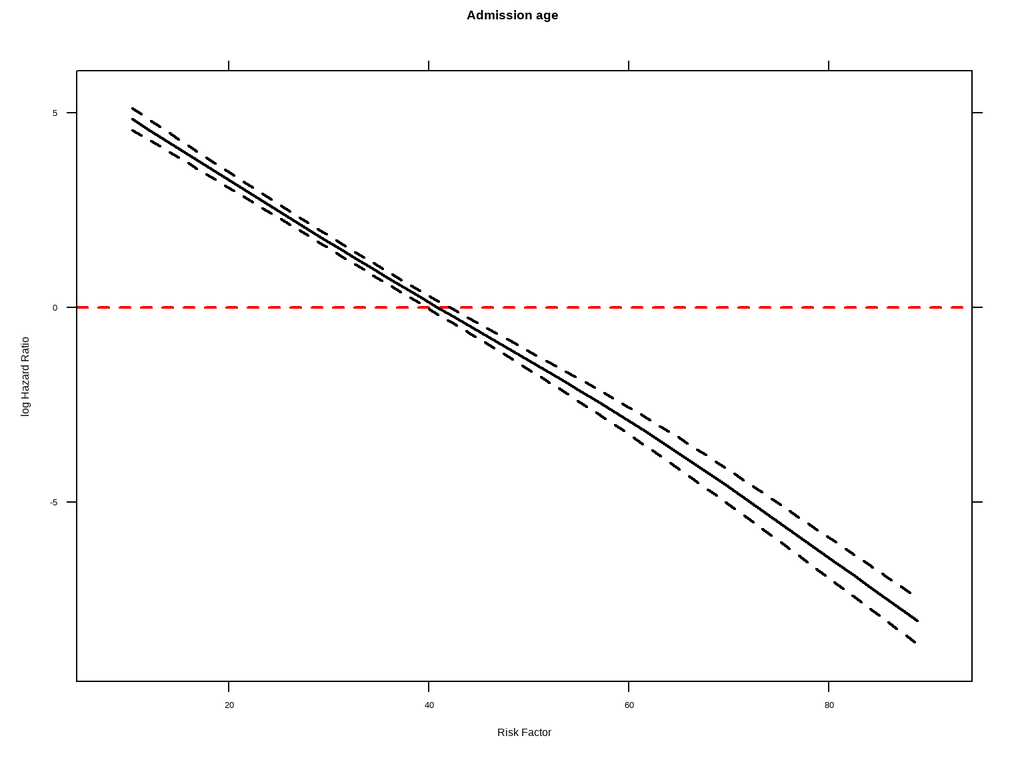

```r
invisible("coxfit_more_var3 , rcs 4, the best")

# Dimitris Rizopoulos (https://stats.stackexchange.com/users/219012/dimitris-rizopoulos), Check log-linearity of a continuous variable to predict survival, URL (version: 2018-10-08): https://stats.stackexchange.com/q/370353

# https://www.drizopoulos.com/courses/EMC/EP03.pdf

# Create an effect plot to depict the relationship
ND <- with(Base_fiscalia_v14,
data.frame(edad_al_ing_1 = seq(min(edad_al_ing_1),  max(edad_al_ing_1), length.out = 50),
            motivodeegreso_mod_imp_rec=rep(Mode(motivodeegreso_mod_imp_rec),50),
            #edad_al_ing_1=rep(mean(edad_al_ing_1, na.rm=T))
            tr_modality= rep(Mode(tr_modality),50),
            sex= rep(Mode(sex),50),
            edad_ini_cons=rep(quantile(edad_ini_cons, .5, na.rm=T),50),
            escolaridad_rec= rep(Mode(escolaridad_rec),50),
            sus_principal_mod= rep(Mode(sus_principal_mod),50),
            freq_cons_sus_prin= rep(Mode(freq_cons_sus_prin),50),
            condicion_ocupacional_corr= rep(Mode(condicion_ocupacional_corr),50),
            policonsumo= rep(Mode(policonsumo),50),
            num_hijos_mod_joel_bin= rep(Mode(num_hijos_mod_joel_bin),50),
            tenencia_de_la_vivienda_mod= rep(Mode(tenencia_de_la_vivienda_mod),50),
            macrozona = rep(Mode(macrozona),50),
            #n_prev_off= rep(quantile(n_prev_off, .5, na.rm=T),50),
            n_off_vio= rep(Mode(n_off_vio),50),
            n_off_acq= rep(Mode(n_off_acq),50),
            n_off_sud= rep(Mode(n_off_sud),50),
            n_off_oth= rep(Mode(n_off_oth),50),
            dg_cie_10_rec = rep(Mode(dg_cie_10_rec),50),
            dg_trs_cons_sus_or = rep(Mode(dg_trs_cons_sus_or),50),
            clas_r= rep(Mode(clas_r),50),
            porc_pobr=rep(quantile(porc_pobr, .5, na.rm=T),50),
            sus_ini_mod_mvv=rep(Mode(sus_ini_mod_mvv),50),
            ano_nac_corr=rep(quantile(ano_nac_corr, .5, na.rm=T),50),
            con_quien_vive_joel=rep(Mode(con_quien_vive_joel),50),
            fis_comorbidity_icd_10=rep(Mode(fis_comorbidity_icd_10),50)
))

prs <- predict(coxfit_more_var3, newdata = ND, type = "lp", se.fit = TRUE)
ND$pred <- prs[[1]]
ND$se <- prs[[2]]
ND$lo <- ND$pred - 1.96 * ND$se
ND$up <- ND$pred + 1.96 * ND$se

xyplot(pred + lo + up ~ edad_al_ing_1, data = ND,
       type = "l", col = "black", lwd = 2, lty = c(1, 2, 2),
       abline = list(h = 0, lty = 2, lwd = 2, col = "red"),
       xlab = "Risk Factor", ylab = "log Hazard Ratio", main="Admission age")
```

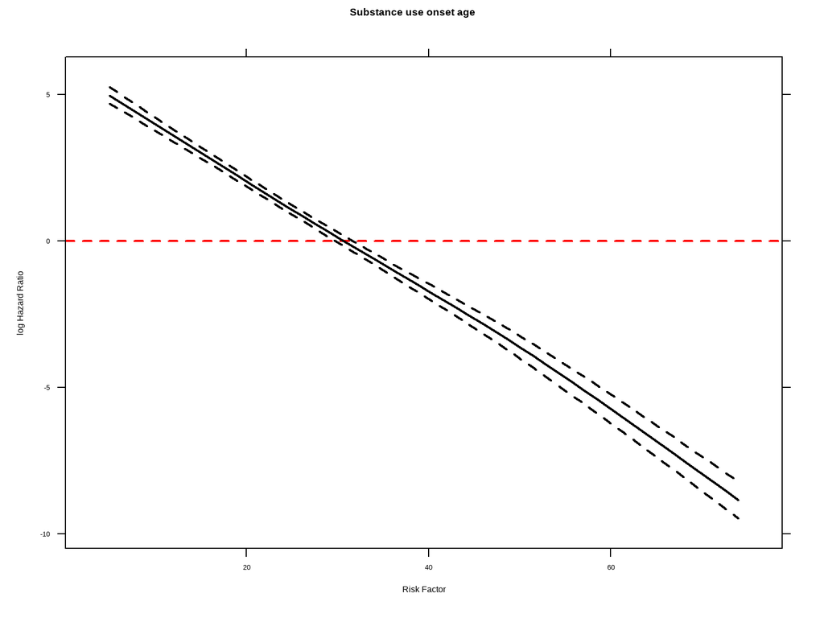

```r
prs2 <- predict(coxfit_more_var3, newdata = ND%>% dplyr::mutate(edad_ini_cons= seq(min(Base_fiscalia_v14$edad_ini_cons,na.rm=T),  max(Base_fiscalia_v14$edad_ini_cons,na.rm=T), length.out = 50))%>% dplyr::mutate(`rcs(edad_al_ing_1, 4)edad_al_ing_1`= log(quantile(Base_fiscalia_v14$edad_al_ing_1, .5, na.rm=T))), type = "lp", se.fit = TRUE)
ND$pred2 <- prs2[[1]]
ND$se2 <- prs2[[2]]
ND$lo2 <- ND$pred2 - 1.96 * ND$se2
ND$up2 <- ND$pred2 + 1.96 * ND$se2

xyplot(pred2 + lo2 + up2 ~ edad_ini_cons, data = ND%>% dplyr::mutate(edad_ini_cons= seq(min(Base_fiscalia_v14$edad_ini_cons,na.rm=T),  max(Base_fiscalia_v14$edad_ini_cons,na.rm=T), length.out = 50))%>% dplyr::mutate(`rcs(edad_al_ing_1, 4)edad_al_ing_1`= log(quantile(Base_fiscalia_v14$edad_al_ing_1, .5, na.rm=T))),
       type = "l", col = "black", lwd = 2, lty = c(1, 2, 2),
       abline = list(h = 0, lty = 2, lwd = 2, col = "red"),
       xlab = "Risk Factor", ylab = "log Hazard Ratio", main="Substance use onset age")
```

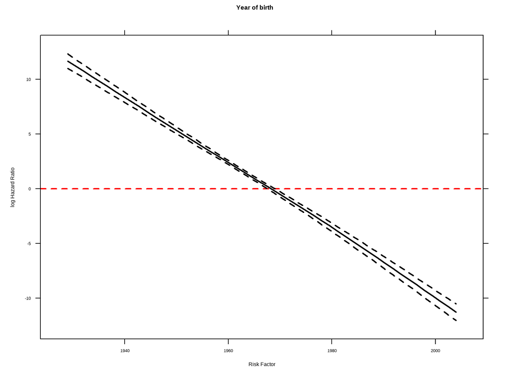

```r
prs3 <- predict(coxfit_more_var3, newdata = ND%>% dplyr::mutate(ano_nac_corr= seq(min(Base_fiscalia_v14$ano_nac_corr,na.rm=T),  max(Base_fiscalia_v14$ano_nac_corr,na.rm=T), length.out = 50))%>% dplyr::mutate(`rcs(edad_al_ing_1, 4)edad_al_ing_1`= log(quantile(Base_fiscalia_v14$edad_al_ing_1, .5, na.rm=T))), type = "lp", se.fit = TRUE)
ND$pred3 <- prs3[[1]]
ND$se3 <- prs3[[2]]
ND$lo3 <- ND$pred3 - 1.96 * ND$se3
ND$up3 <- ND$pred3 + 1.96 * ND$se3

xyplot(pred3 + lo3 + up3 ~ ano_nac_corr, data = ND%>% dplyr::mutate(ano_nac_corr= seq(min(Base_fiscalia_v14$ano_nac_corr,na.rm=T),  max(Base_fiscalia_v14$ano_nac_corr,na.rm=T), length.out = 50))%>% dplyr::mutate(`rcs(edad_al_ing_1, 4)edad_al_ing_1`= log(quantile(Base_fiscalia_v14$edad_al_ing_1, .5, na.rm=T))),
       type = "l", col = "black", lwd = 2, lty = c(1, 2, 2),
       abline = list(h = 0, lty = 2, lwd = 2, col = "red"),
       xlab = "Risk Factor", ylab = "log Hazard Ratio", main="Year of birth")
```

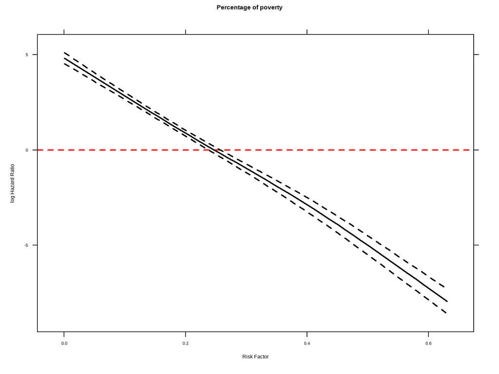

```r
prs4 <- predict(coxfit_more_var3, newdata = ND%>% dplyr::mutate(porc_pobr= seq(min(Base_fiscalia_v14$porc_pobr,na.rm=T),  max(Base_fiscalia_v14$porc_pobr,na.rm=T), length.out = 50))%>% dplyr::mutate(`rcs(edad_al_ing_1, 4)edad_al_ing_1`= log(quantile(Base_fiscalia_v14$edad_al_ing_1, .5, na.rm=T))), type = "lp", se.fit = TRUE)
ND$pred4 <- prs4[[1]]
ND$se4 <- prs4[[2]]
ND$lo4 <- ND$pred4 - 1.96 * ND$se4
ND$up4 <- ND$pred4 + 1.96 * ND$se4

xyplot(pred4 + lo4 + up4 ~ porc_pobr, data = ND%>% dplyr::mutate(porc_pobr= seq(min(Base_fiscalia_v14$porc_pobr,na.rm=T),  max(Base_fiscalia_v14$porc_pobr,na.rm=T), length.out = 50))%>% dplyr::mutate(`rcs(edad_al_ing_1, 4)edad_al_ing_1`= log(quantile(Base_fiscalia_v14$edad_al_ing_1, .5, na.rm=T))),
       type = "l", col = "black", lwd = 2, lty = c(1, 2, 2),
       abline = list(h = 0, lty = 2, lwd = 2, col = "red"),
       xlab = "Risk Factor", ylab = "log Hazard Ratio", main="Percentage of poverty")
```

Time for this code chunk to run: 0.4 minutes

```r
#http://www.sthda.com/english/wiki/cox-model-assumptions
invisible("omitted")
invisible("Martingale residual to assess nonlinearity, does not allow ns or rcs")
#
# #https://github.com/kassambara/survminer/issues/357
 res.cox_edad_ing <- coxph(Surv(yrs_to_condemn,  event_r) ~ edad_al_ing_1+ log(edad_al_ing_1) + I(edad_al_ing_1^2) + I(log(edad_al_ing_1)^2) + I(sqrt(edad_al_ing_1)), data = Base_fiscalia_v14)


 ggcoxfunctional(res.cox_edad_ing,  data = Base_fiscalia_v14%>% dplyr::filter(!is.na(edad_al_ing_1)), point.col = "blue", point.alpha = 0.5)

cat("______________________________________________________________________")

#
# #to avoid errors, we deleted missing values
#
 res.cox_porc_pobr <- coxph(Surv(yrs_to_condemn,  event_r) ~ porc_pobr + log(porc_pobr) + I(porc_pobr^2) + I(log(porc_pobr)^2) + I(sqrt(porc_pobr)), data = Base_fiscalia_v14%>% dplyr::filter(!is.na(porc_pobr)))
#
 ggcoxfunctional(res.cox_porc_pobr,  data = Base_fiscalia_v14%>% dplyr::filter(!is.na(porc_pobr)), point.col = "blue", point.alpha = 0.5)

cat("______________________________________________________________________")

#to avoid errors, we replaced 0s with 0.0001
res.cox_dias_treat <- coxph(Surv(yrs_to_condemn,  event_r) ~ dias_treat_imp_sin_na_1 + log(dias_treat_imp_sin_na_1) + I(log(dias_treat_imp_sin_na_1)^2) + I(dias_treat_imp_sin_na_1^2) +  I(sqrt(dias_treat_imp_sin_na_1)), data = Base_fiscalia_v14%>% dplyr::filter(!is.na(dias_treat_imp_sin_na_1)) %>% dplyr::mutate(dias_treat_imp_sin_na_1= dplyr::case_when(dias_treat_imp_sin_na_1==0~.0001,T~dias_treat_imp_sin_na_1)))

ggcoxfunctional(res.cox_dias_treat,  data = Base_fiscalia_v14%>% dplyr::filter(!is.na(dias_treat_imp_sin_na_1)) %>% dplyr::mutate(dias_treat_imp_sin_na_1= dplyr::case_when(dias_treat_imp_sin_na_1==0~.0001,T~dias_treat_imp_sin_na_1)), point.col = "blue", point.alpha = 0.5)

cat("______________________________________________________________________")

res.cox_num_hijos <- coxph(Surv(yrs_to_condemn,  event_r) ~ numero_de_hijos_mod + log(numero_de_hijos_mod) + I(log(numero_de_hijos_mod)^2) + I(numero_de_hijos_mod^2) +  I(sqrt(numero_de_hijos_mod)), data = Base_fiscalia_v14%>% dplyr::filter(!is.na(numero_de_hijos_mod)) %>% dplyr::mutate(numero_de_hijos_mod= dplyr::case_when(numero_de_hijos_mod==0~.0001,T~as.numeric(numero_de_hijos_mod))))

ggcoxfunctional(res.cox_num_hijos,  data =  Base_fiscalia_v14%>% dplyr::filter(!is.na(numero_de_hijos_mod)) %>% dplyr::mutate(numero_de_hijos_mod= dplyr::case_when(numero_de_hijos_mod==0~.0001,T~as.numeric(numero_de_hijos_mod))), point.col = "blue", point.alpha = 0.5)

cat("______________________________________________________________________")

res.cox_n_prev_off <- coxph(Surv(yrs_to_condemn,  event_r) ~ n_prev_off + log(n_prev_off) + I(log(n_prev_off)^2) + I(n_prev_off^2) +  I(sqrt(n_prev_off)), data = Base_fiscalia_v14%>% dplyr::filter(!is.na(n_prev_off)) %>% dplyr::mutate(n_prev_off= dplyr::case_when(n_prev_off==0~.0001,T~as.numeric(n_prev_off))))

ggcoxfunctional(res.cox_n_prev_off,  data =  Base_fiscalia_v14%>% dplyr::filter(!is.na(n_prev_off)) %>% dplyr::mutate(n_prev_off= dplyr::case_when(n_prev_off==0~.0001,T~as.numeric(n_prev_off))), point.col = "blue", point.alpha = 0.5)

#_#_#_#_#_#_#_#_#_#_#_#_#_#_#_#_#_#_#_#_#_#_#_#_#_#_#_#_#_#_#_#_
#_#_#_#_#_#_#_#_#_#_#_#_#_#_#_#_#_#_#_#_#_#_#_#_#_#_#_#_#_#_#_#_#_#_#_#_#_#_#_#_
#_#_#_#_#_#_#_#_#_#_#_#_#_#_#_#_#_#_#_#_#_#_#_#_#_#_#_#_#_#_#_#_
check_PH <- cox.zph(coxfit_more_var3, transform="km")
data.frame(check_PH$table)%>%
  knitr::kable("markdown", caption= "Schoefeld residuals") #sigue alto
```

Time for this code chunk to run: 0 minutes

```r
check_PH <- cox.zph(coxfit_more_var3, transform="km")
data.frame(check_PH$table)%>%
  knitr::kable("markdown", caption= "Schoefeld residuals")
```

Table 6: Schoefeld residuals

|  | chisq | df | p |
| --- | --- | --- | --- |
| motivodeegreso_mod_imp_rec | 28.4599124 | 2 | 0.0000007 |
| rcs(edad_al_ing_1, 4) | 8.6739796 | 3 | 0.0339547 |
| tr_modality | 4.6696811 | 1 | 0.0306996 |
| sex | 0.1317724 | 1 | 0.7166014 |
| edad_ini_cons | 0.0079184 | 1 | 0.9290937 |
| escolaridad_rec | 2.7041999 | 2 | 0.2586964 |
| sus_principal_mod | 9.9440294 | 4 | 0.0413811 |
| freq_cons_sus_prin | 25.0291742 | 4 | 0.0000496 |
| condicion_ocupacional_corr | 24.4967792 | 5 | 0.0001742 |
| policonsumo | 0.0101998 | 1 | 0.9195552 |
| num_hijos_mod_joel_bin | 1.3474156 | 1 | 0.2457304 |
| tenencia_de_la_vivienda_mod | 3.9330721 | 4 | 0.4151393 |
| macrozona | 2.8460039 | 2 | 0.2409895 |
| n_off_vio | 8.3855458 | 1 | 0.0037822 |
| n_off_acq | 131.1704988 | 1 | 0.0000000 |
| n_off_sud | 5.9081309 | 1 | 0.0150712 |
| n_off_oth | 16.8663623 | 1 | 0.0000401 |
| dg_cie_10_rec | 6.7457321 | 2 | 0.0342912 |
| dg_trs_cons_sus_or | 1.6669248 | 1 | 0.1966709 |
| clas_r | 2.8567199 | 2 | 0.2397017 |
| porc_pobr | 0.0189494 | 1 | 0.8905116 |
| sus_ini_mod_mvv | 3.1737346 | 4 | 0.5291837 |
| ano_nac_corr | 0.0503375 | 1 | 0.8224771 |
| con_quien_vive_joel | 11.7247773 | 3 | 0.0083880 |
| fis_comorbidity_icd_10 | 1.3600074 | 2 | 0.5066151 |
| GLOBAL | 228.0054617 | 51 | 0.0000000 |

Time for this code chunk to run: 0 minutes

```r
#numero_de_hijos_mod_joel ano_nac_corr con_quien_vive_joel

coxfit_more_var21 <- coxph(as.formula(paste("Surv(yrs_to_pris,  event_r) ~ motivodeegreso_mod_imp_rec +", paste(setdiff(vars_cov,""), collapse = "+"))), ties="efron", data= Base_fiscalia_v14_pris)#[1:250,]
#n_prev_off +
coxfit_more_var205 <- coxph(as.formula(paste("Surv(yrs_to_pris,  event_r) ~ motivodeegreso_mod_imp_rec +", paste(setdiff(vars_cov,""), collapse = "+"))), ties="efron", data= Base_fiscalia_v14_pris %>% dplyr::mutate(edad_al_ing_1= VGAM::yeo.johnson(Base_fiscalia_v14$edad_al_ing_1, .5)))#[1:250,]


#*If you are not directly interested in the relations of x1 or x2 to outcome and are simply controlling for them to analyze your predictor of main interest, then you don't have to worry much about the initially confusing display of p-values and hazard ratios for each of the terms associated with the splines.

coxfit_more_var22 <- coxph(as.formula(paste("Surv(yrs_to_pris,  event_r) ~ motivodeegreso_mod_imp_rec + rcs(edad_al_ing_1,3) +", paste(setdiff(vars_cov,"edad_al_ing_1"), collapse = "+"))), ties="efron", data= Base_fiscalia_v14_pris)

coxfit_more_var23 <- coxph(as.formula(paste("Surv(yrs_to_pris,  event_r) ~ motivodeegreso_mod_imp_rec + rcs(edad_al_ing_1,4) +", paste(setdiff(vars_cov,"edad_al_ing_1"), collapse = "+"))), ties="efron", data= Base_fiscalia_v14_pris)

coxfit_more_var24 <- coxph(as.formula(paste("Surv(yrs_to_pris,  event_r) ~ motivodeegreso_mod_imp_rec + rcs(edad_al_ing_1,5) +", paste(setdiff(vars_cov,"edad_al_ing_1"), collapse = "+"))), ties="efron", data= Base_fiscalia_v14_pris)

coxfit_more_var25 <- coxph(as.formula(paste("Surv(yrs_to_pris,  event_r) ~ motivodeegreso_mod_imp_rec + rcs(edad_al_ing_1,6) +", paste(setdiff(vars_cov,"edad_al_ing_1"), collapse = "+"))), ties="efron", data= Base_fiscalia_v14_pris)

coxfit_more_var26 <- coxph(as.formula(paste("Surv(yrs_to_pris,  event_r) ~ motivodeegreso_mod_imp_rec + ns(edad_al_ing_1) +", paste(setdiff(vars_cov,"edad_al_ing_1"), collapse = "+"))), ties="efron", data= Base_fiscalia_v14_pris)

coxfit_more_var27 <- coxph(as.formula(paste("Surv(yrs_to_pris,  event_r) ~ motivodeegreso_mod_imp_rec + ns(edad_al_ing_1,df= 2) +", paste(setdiff(vars_cov,"edad_al_ing_1"), collapse = "+"))), ties="efron", data= Base_fiscalia_v14_pris)

coxfit_more_var28 <- coxph(as.formula(paste("Surv(yrs_to_pris,  event_r) ~ motivodeegreso_mod_imp_rec + ns(edad_al_ing_1,df= 3) +", paste(setdiff(vars_cov,"edad_al_ing_1"), collapse = "+"))), ties="efron", data= Base_fiscalia_v14_pris)

coxfit_more_var29 <- coxph(as.formula(paste("Surv(yrs_to_pris,  event_r) ~ motivodeegreso_mod_imp_rec + ns(edad_al_ing_1,df= 4) +", paste(setdiff(vars_cov,"edad_al_ing_1"), collapse = "+"))), ties="efron", data= Base_fiscalia_v14_pris)

anova(coxfit_more_var205, coxfit_more_var21, coxfit_more_var22, coxfit_more_var23, coxfit_more_var24, coxfit_more_var25, coxfit_more_var26, coxfit_more_var27, coxfit_more_var28, coxfit_more_var29)
```

```
Analysis of Deviance Table
 Cox model: response is  Surv(yrs_to_pris, event_r)
 Model  1: ~ motivodeegreso_mod_imp_rec + motivodeegreso_mod_imp_rec + tr_modality + edad_al_ing_1 + sex + edad_ini_cons + escolaridad_rec + sus_principal_mod + freq_cons_sus_prin + condicion_ocupacional_corr + policonsumo + num_hijos_mod_joel_bin + tenencia_de_la_vivienda_mod + macrozona + n_off_vi…
 Model  2: ~ motivodeegreso_mod_imp_rec + motivodeegreso_mod_imp_rec + tr_modality + edad_al_ing_1 + sex + edad_ini_cons + escolaridad_rec + sus_principal_mod + freq_cons_sus_prin + condicion_ocupacional_corr + policonsumo + num_hijos_mod_joel_bin + tenencia_de_la_vivienda_mod + macrozona + n_off_vi…
 Model  3: ~ motivodeegreso_mod_imp_rec + rcs(edad_al_ing_1, 3) + motivodeegreso_mod_imp_rec + tr_modality + sex + edad_ini_cons + escolaridad_rec + sus_principal_mod + freq_cons_sus_prin + condicion_ocupacional_corr + policonsumo + num_hijos_mod_joel_bin + tenencia_de_la_vivienda_mod + macrozona + …
 Model  4: ~ motivodeegreso_mod_imp_rec + rcs(edad_al_ing_1, 4) + motivodeegreso_mod_imp_rec + tr_modality + sex + edad_ini_cons + escolaridad_rec + sus_principal_mod + freq_cons_sus_prin + condicion_ocupacional_corr + policonsumo + num_hijos_mod_joel_bin + tenencia_de_la_vivienda_mod + macrozona + …
 Model  5: ~ motivodeegreso_mod_imp_rec + rcs(edad_al_ing_1, 5) + motivodeegreso_mod_imp_rec + tr_modality + sex + edad_ini_cons + escolaridad_rec + sus_principal_mod + freq_cons_sus_prin + condicion_ocupacional_corr + policonsumo + num_hijos_mod_joel_bin + tenencia_de_la_vivienda_mod + macrozona + …
 Model  6: ~ motivodeegreso_mod_imp_rec + rcs(edad_al_ing_1, 6) + motivodeegreso_mod_imp_rec + tr_modality + sex + edad_ini_cons + escolaridad_rec + sus_principal_mod + freq_cons_sus_prin + condicion_ocupacional_corr + policonsumo + num_hijos_mod_joel_bin + tenencia_de_la_vivienda_mod + macrozona + …
 Model  7: ~ motivodeegreso_mod_imp_rec + ns(edad_al_ing_1) + motivodeegreso_mod_imp_rec + tr_modality + sex + edad_ini_cons + escolaridad_rec + sus_principal_mod + freq_cons_sus_prin + condicion_ocupacional_corr + policonsumo + num_hijos_mod_joel_bin + tenencia_de_la_vivienda_mod + macrozona + n_of…
 Model  8: ~ motivodeegreso_mod_imp_rec + ns(edad_al_ing_1, df = 2) + motivodeegreso_mod_imp_rec + tr_modality + sex + edad_ini_cons + escolaridad_rec + sus_principal_mod + freq_cons_sus_prin + condicion_ocupacional_corr + policonsumo + num_hijos_mod_joel_bin + tenencia_de_la_vivienda_mod + macrozon…
 Model  9: ~ motivodeegreso_mod_imp_rec + ns(edad_al_ing_1, df = 3) + motivodeegreso_mod_imp_rec + tr_modality + sex + edad_ini_cons + escolaridad_rec + sus_principal_mod + freq_cons_sus_prin + condicion_ocupacional_corr + policonsumo + num_hijos_mod_joel_bin + tenencia_de_la_vivienda_mod + macrozon…
 Model 10: ~ motivodeegreso_mod_imp_rec + ns(edad_al_ing_1, df = 4) + motivodeegreso_mod_imp_rec + tr_modality + sex + edad_ini_cons + escolaridad_rec + sus_principal_mod + freq_cons_sus_prin + condicion_ocupacional_corr + policonsumo + num_hijos_mod_joel_bin + tenencia_de_la_vivienda_mod + macrozon…
   loglik    Chisq Df Pr(>|Chi|)
1  -39826
2  -39768 117.1452  0  < 2.2e-16 ***
3  -39754  27.9776  1  1.227e-07 ***
4  -39752   3.0226  1    0.08211 .
5  -39752   0.2509  1    0.61641
6  -39749   5.8079  1    0.01595 *
7  -39768  36.5571  4  2.222e-07 ***
8  -39754  26.5960  1  2.508e-07 ***
9  -39753   3.3076  1    0.06896 .
10 -39752   0.2305  1    0.63116
---
Signif. codes:  0 '***' 0.001 '**' 0.01 '*' 0.05 '.' 0.1 ' ' 1
```

```r
anova(coxfit_more_var23, coxfit_more_var25, coxfit_more_var29,coxfit_more_var28)
```

[output not shown]

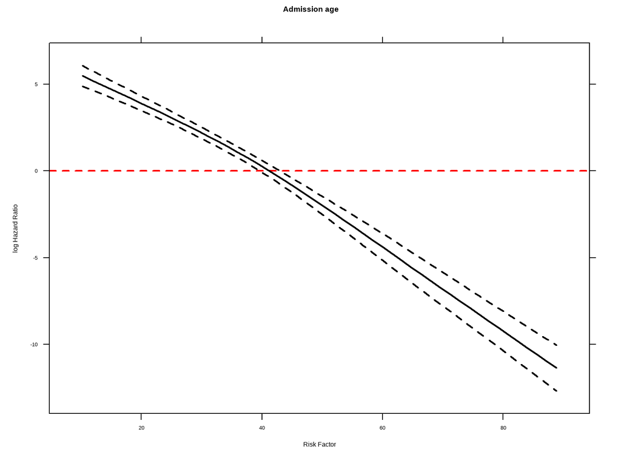

```r
invisible("coxfit_more_var25 , rcs 6, the best; but for linearity, coxfit_more_var23")

# Dimitris Rizopoulos (https://stats.stackexchange.com/users/219012/dimitris-rizopoulos), Check log-linearity of a continuous variable to predict survival, URL (version: 2018-10-08): https://stats.stackexchange.com/q/370353

# Create an effect plot to depict the relationship
ND_pris <- with(Base_fiscalia_v14_pris,
data.frame(edad_al_ing_1 = seq(min(edad_al_ing_1),  max(edad_al_ing_1), length.out = 50),
            motivodeegreso_mod_imp_rec=rep(Mode(motivodeegreso_mod_imp_rec),50),
            #edad_al_ing_1=rep(mean(edad_al_ing_1, na.rm=T))
            tr_modality= rep(Mode(tr_modality),50),
            sex= rep(Mode(sex),50),
            edad_ini_cons=rep(quantile(edad_ini_cons, .5, na.rm=T),50),
            escolaridad_rec= rep(Mode(escolaridad_rec),50),
            sus_principal_mod= rep(Mode(sus_principal_mod),50),
            freq_cons_sus_prin= rep(Mode(freq_cons_sus_prin),50),
            condicion_ocupacional_corr= rep(Mode(condicion_ocupacional_corr),50),
            policonsumo= rep(Mode(policonsumo),50),
            num_hijos_mod_joel_bin= rep(Mode(num_hijos_mod_joel_bin),50),
            tenencia_de_la_vivienda_mod= rep(Mode(tenencia_de_la_vivienda_mod),50),
            macrozona = rep(Mode(macrozona),50),
            #n_prev_off= rep(quantile(n_prev_off, .5, na.rm=T),50),
            n_off_vio= rep(Mode(n_off_vio),50),
            n_off_acq= rep(Mode(n_off_acq),50),
            n_off_sud= rep(Mode(n_off_sud),50),
            n_off_oth= rep(Mode(n_off_oth),50),
            dg_cie_10_rec = rep(Mode(dg_cie_10_rec),50),
            dg_trs_cons_sus_or = rep(Mode(dg_trs_cons_sus_or),50),
            clas_r= rep(Mode(clas_r),50),
            porc_pobr=rep(quantile(porc_pobr, .5, na.rm=T),50),
            sus_ini_mod_mvv=rep(Mode(sus_ini_mod_mvv),50),
            ano_nac_corr=rep(quantile(ano_nac_corr, .5, na.rm=T),50),
            con_quien_vive_joel=rep(Mode(con_quien_vive_joel),50),
            fis_comorbidity_icd_10=rep(Mode(fis_comorbidity_icd_10),50)
))

prs_pris <- predict(coxfit_more_var23, newdata = ND_pris, type = "lp", se.fit = TRUE)
ND_pris$pred <- prs_pris[[1]]
ND_pris$se <- prs_pris[[2]]
ND_pris$lo <- ND_pris$pred - 1.96 * ND_pris$se
ND_pris$up <- ND_pris$pred + 1.96 * ND_pris$se

xyplot(pred + lo + up ~ edad_al_ing_1, data = ND_pris,
       type = "l", col = "black", lwd = 2, lty = c(1, 2, 2),
       abline = list(h = 0, lty = 2, lwd = 2, col = "red"),
       xlab = "Risk Factor", ylab = "log Hazard Ratio", main="Admission age")
```

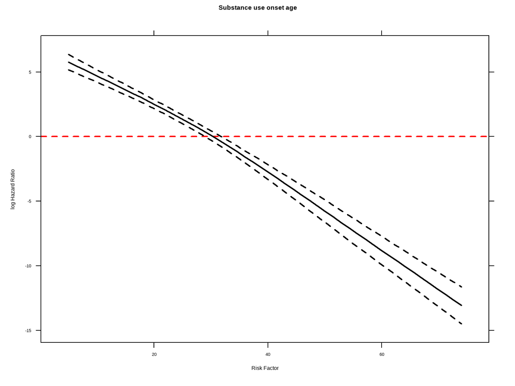

```r
prs2 <- predict(coxfit_more_var23, newdata = ND_pris%>% dplyr::mutate(edad_ini_cons= seq(min(Base_fiscalia_v14_pris$edad_ini_cons,na.rm=T),  max(Base_fiscalia_v14_pris$edad_ini_cons,na.rm=T), length.out = 50))%>% dplyr::mutate(`rcs(edad_al_ing_1, 4)edad_al_ing_1`= log(quantile(Base_fiscalia_v14_pris$edad_al_ing_1, .5, na.rm=T))), type = "lp", se.fit = TRUE)
ND_pris$pred2 <- prs2[[1]]
ND_pris$se2 <- prs2[[2]]
ND_pris$lo2 <- ND_pris$pred2 - 1.96 * ND_pris$se2
ND_pris$up2 <- ND_pris$pred2 + 1.96 * ND_pris$se2

xyplot(pred2 + lo2 + up2 ~ edad_ini_cons, data = ND_pris%>% dplyr::mutate(edad_ini_cons= seq(min(Base_fiscalia_v14_pris$edad_ini_cons,na.rm=T),  max(Base_fiscalia_v14_pris$edad_ini_cons,na.rm=T), length.out = 50))%>% dplyr::mutate(`rcs(edad_al_ing_1, 4)edad_al_ing_1`= log(quantile(Base_fiscalia_v14_pris$edad_al_ing_1, .5, na.rm=T))),
       type = "l", col = "black", lwd = 2, lty = c(1, 2, 2),
       abline = list(h = 0, lty = 2, lwd = 2, col = "red"),
       xlab = "Risk Factor", ylab = "log Hazard Ratio", main="Substance use onset age")
```

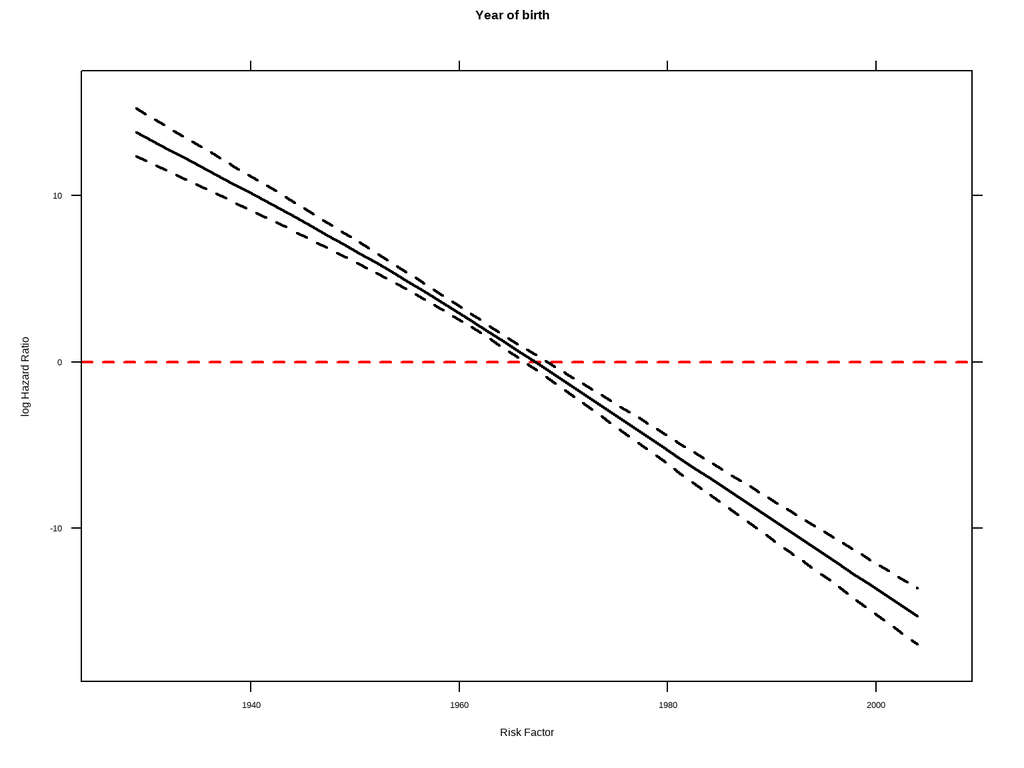

```r
prs3 <- predict(coxfit_more_var23, newdata = ND_pris%>% dplyr::mutate(ano_nac_corr= seq(min(Base_fiscalia_v14_pris$ano_nac_corr,na.rm=T),  max(Base_fiscalia_v14_pris$ano_nac_corr,na.rm=T), length.out = 50))%>% dplyr::mutate(`rcs(edad_al_ing_1, 4)edad_al_ing_1`= log(quantile(Base_fiscalia_v14_pris$edad_al_ing_1, .5, na.rm=T))), type = "lp", se.fit = TRUE)
ND_pris$pred3 <- prs3[[1]]
ND_pris$se3 <- prs3[[2]]
ND_pris$lo3 <- ND_pris$pred3 - 1.96 * ND_pris$se3
ND_pris$up3 <- ND_pris$pred3 + 1.96 * ND_pris$se3

xyplot(pred3 + lo3 + up3 ~ ano_nac_corr, data = ND_pris%>% dplyr::mutate(ano_nac_corr= seq(min(Base_fiscalia_v14_pris$ano_nac_corr,na.rm=T),  max(Base_fiscalia_v14_pris$ano_nac_corr,na.rm=T), length.out = 50))%>% dplyr::mutate(`rcs(edad_al_ing_1, 4)edad_al_ing_1`= log(quantile(Base_fiscalia_v14_pris$edad_al_ing_1, .5, na.rm=T))),
       type = "l", col = "black", lwd = 2, lty = c(1, 2, 2),
       abline = list(h = 0, lty = 2, lwd = 2, col = "red"),
       xlab = "Risk Factor", ylab = "log Hazard Ratio", main="Year of birth")
```

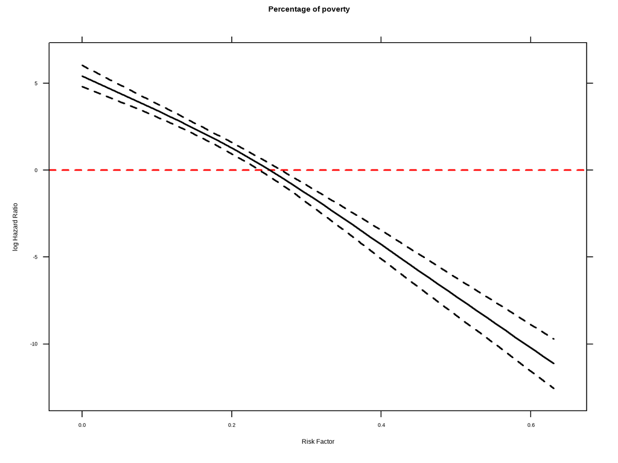

```r
prs4 <- predict(coxfit_more_var23, newdata = ND_pris%>% dplyr::mutate(porc_pobr= seq(min(Base_fiscalia_v14_pris$porc_pobr,na.rm=T),  max(Base_fiscalia_v14_pris$porc_pobr,na.rm=T), length.out = 50))%>% dplyr::mutate(`rcs(edad_al_ing_1, 4)edad_al_ing_1`= log(quantile(Base_fiscalia_v14_pris$edad_al_ing_1, .5, na.rm=T))), type = "lp", se.fit = TRUE)
ND_pris$pred4 <- prs4[[1]]
ND_pris$se4 <- prs4[[2]]
ND_pris$lo4 <- ND_pris$pred4 - 1.96 * ND_pris$se4
ND_pris$up4 <- ND_pris$pred4 + 1.96 * ND_pris$se4

xyplot(pred4 + lo4 + up4 ~ porc_pobr, data = ND_pris%>% dplyr::mutate(porc_pobr= seq(min(Base_fiscalia_v14_pris$porc_pobr,na.rm=T),  max(Base_fiscalia_v14_pris$porc_pobr,na.rm=T), length.out = 50))%>% dplyr::mutate(`rcs(edad_al_ing_1, 4)edad_al_ing_1`= log(quantile(Base_fiscalia_v14_pris$edad_al_ing_1, .5, na.rm=T))),
       type = "l", col = "black", lwd = 2, lty = c(1, 2, 2),
       abline = list(h = 0, lty = 2, lwd = 2, col = "red"),
       xlab = "Risk Factor", ylab = "log Hazard Ratio", main="Percentage of poverty")
```

Time for this code chunk to run: 0.4 minutes

```r
check_PH_pris <- cox.zph(coxfit_more_var23, transform="km")
data.frame(check_PH_pris$table)%>%
  knitr::kable("markdown", caption= "Schoefeld residuals (prison)")
```

Table 7: Schoefeld residuals (prison)

|  | chisq | df | p |
| --- | --- | --- | --- |
| motivodeegreso_mod_imp_rec | 10.6217000 | 2 | 0.0049377 |
| rcs(edad_al_ing_1, 4) | 7.1673488 | 3 | 0.0667508 |
| tr_modality | 0.3747307 | 1 | 0.5404368 |
| sex | 0.3234527 | 1 | 0.5695400 |
| edad_ini_cons | 8.3956460 | 1 | 0.0037612 |
| escolaridad_rec | 9.1528430 | 2 | 0.0102917 |
| sus_principal_mod | 6.3557274 | 4 | 0.1741108 |
| freq_cons_sus_prin | 14.2030735 | 4 | 0.0066744 |
| condicion_ocupacional_corr | 11.0015826 | 5 | 0.0513486 |
| policonsumo | 2.1221488 | 1 | 0.1451827 |
| num_hijos_mod_joel_bin | 0.0604707 | 1 | 0.8057536 |
| tenencia_de_la_vivienda_mod | 0.5902843 | 4 | 0.9641372 |
| macrozona | 6.9003178 | 2 | 0.0317406 |
| n_off_vio | 18.7513966 | 1 | 0.0000149 |
| n_off_acq | 54.9577108 | 1 | 0.0000000 |
| n_off_sud | 5.0019251 | 1 | 0.0253191 |
| n_off_oth | 23.5580661 | 1 | 0.0000012 |
| dg_cie_10_rec | 4.0544209 | 2 | 0.1317024 |
| dg_trs_cons_sus_or | 4.3349584 | 1 | 0.0373373 |
| clas_r | 3.5636370 | 2 | 0.1683318 |
| porc_pobr | 1.0689267 | 1 | 0.3011880 |
| sus_ini_mod_mvv | 6.6207039 | 4 | 0.1573422 |
| ano_nac_corr | 0.9535141 | 1 | 0.3288264 |
| con_quien_vive_joel | 9.3129256 | 3 | 0.0254071 |
| fis_comorbidity_icd_10 | 3.3120123 | 2 | 0.1908999 |
| GLOBAL | 178.1378997 | 51 | 0.0000000 |

Time for this code chunk to run: 0 minutes

## Kaplan-Meier

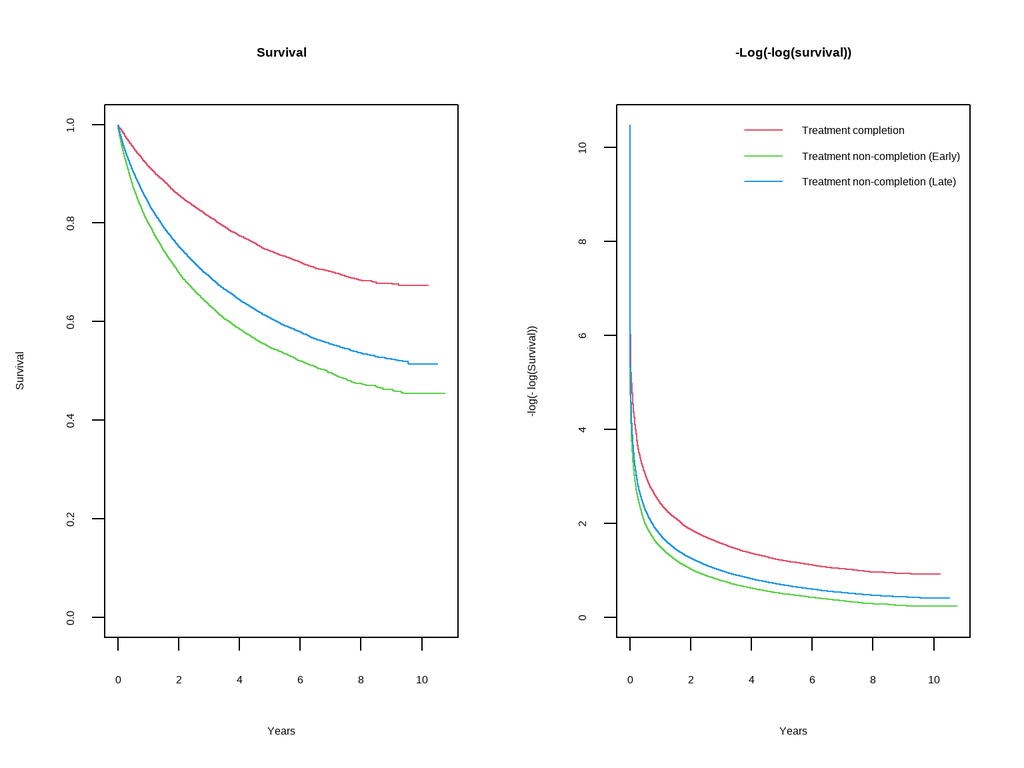

Figure 1: Kaplan-Meier (Cond. Sentence)

```r
#Bradburn, M., Clark, T., Love, S. et al. Survival Analysis Part III: Multivariate data analysis – choosing a model and assessing its adequacy and fit. Br J Cancer 89, 605–611 (2003). https://doi.org/10.1038/sj.bjc.6601120

KM_fit <- survfit(Surv(age_offending_imp-edad_al_egres_imp, event_r) ~
    strata(motivodeegreso_mod_imp_rec), data = Base_fiscalia_v14)

par(mfrow = c(1, 2))

plot(KM_fit, xlab = "Years", ylab = "Survival", col = 2:4, main="Survival")
#legend("topright", levels(factor(Base_fiscalia_v14$motivodeegreso_mod_imp_rec)), lty = 1, col = 2:4, bty = "n")

plot(KM_fit, fun = function (s) -log(-log(s)), xlab = "Years",
    ylab = "-log(- log(Survival))", col = 2:4, main="-Log(−log(survival)) ")
legend("topright", levels(factor(Base_fiscalia_v14$motivodeegreso_mod_imp_rec)), lty = 1, col = 2:4, bty = "n")
```

Time for this code chunk to run: 0 minutes

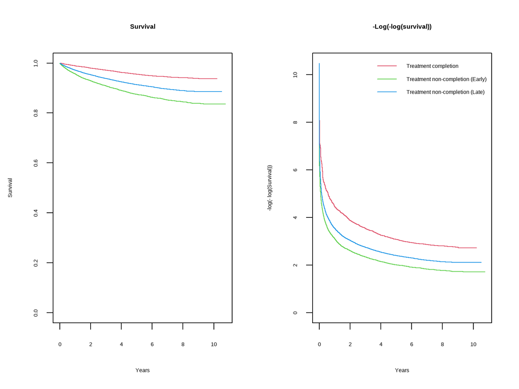

Figure 2: Kaplan-Meier (Prison)

```r
KM_fit_pris <- survfit(Surv(age_offending_imp-edad_al_egres_imp, event_r) ~
    strata(motivodeegreso_mod_imp_rec), data = Base_fiscalia_v14_pris)

par(mfrow = c(1, 2))

plot(KM_fit_pris, xlab = "Years", ylab = "Survival", col = 2:4, main="Survival")
#legend("topright", levels(factor(Base_fiscalia_v14$motivodeegreso_mod_imp_rec)), lty = 1, col = 2:4, bty = "n")

plot(KM_fit_pris, fun = function (s) -log(-log(s)), xlab = "Years",
    ylab = "-log(- log(Survival))", col = 2:4, main="-Log(−log(survival)) ")
legend("topright", levels(factor(Base_fiscalia_v14_pris$motivodeegreso_mod_imp_rec)), lty = 1, col = 2:4, bty = "n")
```

Time for this code chunk to run: 0 minutes

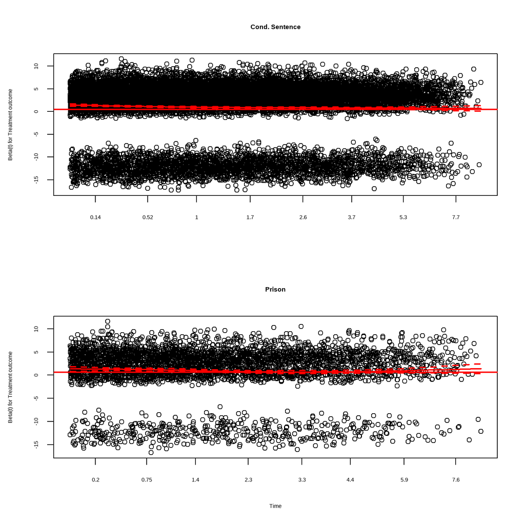

Figure 3: Schoefeld residuals, Treatment Outcome

```r
par(mfrow = c(2, 1))

plot(check_PH, var = 1, ylab= "Beta(t) for Treatment outcome", col = "red", lwd = 2, main= "Cond. Sentence", xlab="")
abline(h = coef(coxfit_more_var3)[1], col = "red", lwd = 2)

plot(check_PH_pris, var = 1, ylab= "Beta(t) for Treatment outcome", col = "red", lwd = 2, main="Prison")
abline(h = coef(coxfit_more_var23)[1], col = "red", lwd = 2)
```

Time for this code chunk to run: 0 minutes

Time for this code chunk to run: 0 minutes

```r
cat("(==============================# EXPERIMENTAL, COXED ======================================)")
invisible("http://dx.doi.org/10.7910/DVN/ELT9VD")
invisible("https://cran.r-project.org/web/packages/coxed/coxed.pdf")
invisible("https://cran.r-project.org/web/packages/coxed/vignettes/coxed.html")

system.time({
npsf1<-coxed(coxfit_more_var8, method="npsf")
})
warning("Error: cannot allocate vector of size 18.3 Gb")
#https://search.r-project.org/CRAN/refmans/pec/html/predictSurvProb.html
system.time({
npsf2<-coxed(coxfit_more_var8, method="npsf", bootstrap = T)
})
system.time({
coxed_gam<-coxed(coxfit_more_var8, method="gam",bootstrap = TRUE, B=100,
  newdata= dplyr::mutate(Base_fiscalia_v14, motivodeegreso_mod_imp_rec="Treatment completion"),
  newdata2= dplyr::mutate(Base_fiscalia_v14,motivodeegreso_mod_imp_rec="Treatment non-completion (Early)"),
  newdata3= dplyr::mutate(Base_fiscalia_v14,motivodeegreso_mod_imp_rec="Treatment non-completion (Late)")) #newdata3= dplyr::mutate(motivodeegreso_mod_imp_rec="Treatment non-completion (Late)")
})
invisible("Inclusion of censored cases increases mean duration by more than 25%. Consider using method='npsf' instead")

cat("(====================================================================)")

invisible("https://cran.r-project.org/web/packages/randomForestSRC/randomForestSRC.pdf")

follic.obj <- randomForestSRC::rfsrc(as.formula(paste("Surv(yrs_to_condemn,  event_r) ~ ", paste(vars_cov, collapse = "+ "))), Base_fiscalia_v14_mod %>% dplyr::mutate(cat_ocupacional_corr= factor(cat_ocupacional_corr), dg_trs_cons_sus_or= factor(dg_trs_cons_sus_or)), nsplit = 3, ntree = 100)

p.v <- plot.variable(follic.obj, target = 2)
p.v$plots.per.page <- 1


invisible("Error in finalizeData(c(subj.names, yvar.names, xvar.names), data, na.action,  :
  data types cannot be character: please convert all characters to factors")
```

Time for this code chunk to run: 0 minutes

```r
#
cat("(==============================# EXPERIMENTAL, Survex ======================================)")
require("mboost")

prueba_stata<-rio::import("mariel_feb_23.dta")

my_vector <- c("motivodeegreso_mod_imp_rec", "tr_mod2", "edad_al_ing_1", "sex_dum2", "edad_ini_cons", "esc1", "esc2", "sus_prin2", "sus_prin3", "sus_prin4", "sus_prin5", "fr_cons_sus_prin2", "fr_cons_sus_prin3", "fr_cons_sus_prin4", "fr_cons_sus_prin5", "cond_ocu2", "cond_ocu3", "cond_ocu4", "cond_ocu5", "cond_ocu6", "policonsumo", "num_hij2", "tenviv1", "tenviv2", "tenviv4", "tenviv5", "mzone2", "mzone3", "n_off_vio", "n_off_acq", "n_off_sud", "n_off_oth", "rural2", "rural3", "porc_pobr", "susini2", "susini3", "susini4", "susini5", "dg_fis_anemia", "dg_fis_card", "dg_fis_enf_som", "dg_fis_ets", "dg_fis_hep_alc", "dg_fis_hep_b", "dg_fis_hep_cro", "dg_fis_inf", "dg_fis_otr_cond_fis_ries_vit", "dg_fis_otr_cond_fis", "dg_fis_pat_buc", "dg_fis_pat_ges_intrau", "dg_fis_trau_sec")

# create a model
#ranger(as.formula(paste("Surv(diff, event)~ ", paste(my_vector, collapse = "+"))), data = prueba_stata[complete.cases(prueba_stata[,my_vector]),])
model <-
  glmboost(as.formula(paste("Surv(diff, event)~ ", paste(my_vector, collapse = "+"))),
  data = prueba_stata, family = CoxPH(), center = TRUE, control=boost_control(mstop = 500))

#Computes the predicted survivor function for a Cox proportional hazards model.
pred_boost_cph<-survFit(model)

plot(varimp(model), blorder = "rev_alphabetical")
```

Time for this code chunk to run: 0 minutes

# Missing data

```r
set.seed(2125)
Base_fiscalia_v14_miss <-
subset(Base_fiscalia_v14, select= c("hash_key", vars_cov, "fech_ing_num_1", "fech_nac_rec", "offender_d", "age_offending_imp", "edad_al_egres_imp")) %>%
  dplyr::arrange(hash_key, fech_ing_num_1) %>%
   missRanger::missRanger(
                formula = .  -offender_d - age_offending_imp ~ . - hash_key -offender_d - age_offending_imp,
                num.trees = 200,
                pmm.k = 3,
                returnOOB=T,
                maxiter= 50,
                verbose = 2,
                seed = 2125)
```

```
Missing value imputation by random forests

  Variables to impute:      motivodeegreso_mod_imp_rec, tr_modality, edad_ini_cons, escolaridad_rec, sus_principal_mod, freq_cons_sus_prin, condicion_ocupacional_corr, num_hijos_mod_joel_bin, tenencia_de_la_vivienda_mod, macrozona, dg_trs_cons_sus_or, clas_r, porc_pobr, sus_ini_mod_mvv, con_quien_vi…
  Variables used to impute: motivodeegreso_mod_imp_rec, tr_modality, edad_al_ing_1, sex, edad_ini_cons, escolaridad_rec, sus_principal_mod, freq_cons_sus_prin, condicion_ocupacional_corr, policonsumo, num_hijos_mod_joel_bin, tenencia_de_la_vivienda_mod, macrozona, n_off_vio, n_off_acq, n_off_sud, n_…
    ss_pr_  cndc__  dg____  cn_q__  clas_r  prc_pb  mtv___  macrzn  tr_mdl  esclr_  frq___  nm____  tn____  ss_n__  edd_n_
iter 1: 0.4715  0.4586  0.2777  0.4710  0.1801  0.5762  0.3832  0.1647  0.1253  0.4401  0.5063  0.7866  0.4508  0.3615  0.7205
iter 2: 0.0008  0.0054  0.0000  0.0000  0.0000  0.0159  0.0000  0.0000  0.0000  0.0000  0.0003  0.0027  0.0022  0.0004  0.0293
iter 3: 0.0015  0.0053  0.0000  0.0000  0.0000  0.0156  0.0000  0.0000  0.0000  0.0000  0.0004  0.0023  0.0019  0.0002  0.0294
iter 4: 0.0007  0.0049  0.0000  0.0000  0.0000  0.0151  0.0000  0.0000  0.0000  0.0000  0.0003  0.0028  0.0018  0.0006  0.0293
iter 5: 0.0013  0.0053  0.0000  0.0000  0.0000  0.0158  0.0000  0.0000  0.0000  0.0000  0.0006  0.0024  0.0024  0.0005  0.0285
```

```r
set.seed(2125)
  Base_fiscalia_v14_pris_miss <-
subset(Base_fiscalia_v14_pris, select= c("hash_key", vars_cov, "fech_ing_num_1", "fech_nac_rec", "offender_d", "age_offending_imp", "edad_al_egres_imp")) %>%
     missRanger::missRanger(
                formula = .  -offender_d - age_offending_imp ~ . - hash_key -offender_d - age_offending_imp,
                num.trees = 200,
                pmm.k = 3,
                returnOOB=T,
                maxiter= 50,
                verbose = 2,
                seed = 2125)
```

[output not shown]

```r
set.seed(2125)
Base_fiscalia_v14_miss2 <-
subset(Base_fiscalia_v14, select= c("hash_key", vars_cov, "fech_ing_num_1", "fech_nac_rec", "offender_d", "age_offending_imp", "edad_al_egres_imp")) %>%
  dplyr::arrange(hash_key, fech_ing_num_1) %>%
  dplyr::mutate(dg_cie_10_rec= dplyr::case_when(as.character(dg_cie_10_rec)=="Diagnosis unknown (under study)"~NA_character_,T~as.character(dg_cie_10_rec)))%>%
  #code to multiple response in  physical comorbidity (deprecated)
  #dplyr::mutate(SUM = rowSums(dplyr::mutate_all(dplyr::select(., dplyr::starts_with("dg_fis")),~as.numeric(.)-1))) %>%
  #dplyr::mutate(across(dplyr::starts_with("dg_fis"), ~factor(dplyr::case_when(as.character(dg_fis_in_study)=="Presence" & SUM==1 ~NA_character_,T~as.character(.))))) %>%
  dplyr::mutate(fis_comorbidity_icd_10= dplyr::case_when(as.character(fis_comorbidity_icd_10)=="Diagnosis unknown (under study)"~NA_character_,T~as.character(fis_comorbidity_icd_10)))%>%
  missRanger::missRanger(
                formula = .  -offender_d - age_offending_imp ~ . - hash_key -offender_d - age_offending_imp,
                num.trees = 200,
                pmm.k = 3,
                returnOOB=T,
                maxiter= 50,
                verbose = 2,
                seed = 2125)
```

```
Missing value imputation by random forests

  Variables to impute:      motivodeegreso_mod_imp_rec, tr_modality, edad_ini_cons, escolaridad_rec, sus_principal_mod, freq_cons_sus_prin, condicion_ocupacional_corr, num_hijos_mod_joel_bin, tenencia_de_la_vivienda_mod, macrozona, dg_cie_10_rec, dg_trs_cons_sus_or, clas_r, porc_pobr, sus_ini_mod_mv…
  Variables used to impute: motivodeegreso_mod_imp_rec, tr_modality, edad_al_ing_1, sex, edad_ini_cons, escolaridad_rec, sus_principal_mod, freq_cons_sus_prin, condicion_ocupacional_corr, policonsumo, num_hijos_mod_joel_bin, tenencia_de_la_vivienda_mod, macrozona, n_off_vio, n_off_acq, n_off_sud, n_…
    ss_pr_  cndc__  dg____  cn_q__  clas_r  prc_pb  mtv___  macrzn  tr_mdl  esclr_  frq___  nm____  tn____  ss_n__  edd_n_  d__10_  f___10
iter 1: 0.4703  0.4618  0.2807  0.4606  0.1783  0.5871  0.4417  0.1553  0.1279  0.4440  0.5091  0.7899  0.4529  0.3628  0.7179  0.3865  0.1358
iter 2: 0.0009  0.0056  0.0000  0.0000  0.0000  0.0170  0.0000  0.0000  0.0000  0.0000  0.0004  0.0023  0.0022  0.0004  0.0301  0.0000  0.0000
iter 3: 0.0013  0.0058  0.0000  0.0000  0.0000  0.0139  0.0000  0.0000  0.0000  0.0000  0.0003  0.0028  0.0022  0.0001  0.0286  0.0000  0.0000
iter 4: 0.0015  0.0054  0.0000  0.0000  0.0000  0.0147  0.0000  0.0000  0.0000  0.0000  0.0004  0.0024  0.0020  0.0003  0.0281  0.0000  0.0000
iter 5: 0.0015  0.0052  0.0000  0.0000  0.0000  0.0161  0.0000  0.0000  0.0000  0.0000  0.0005  0.0026  0.0024  0.0004  0.0278  0.0000  0.0000
```

```r
set.seed(2125)
  Base_fiscalia_v14_pris_miss2 <-
subset(Base_fiscalia_v14_pris, select= c("hash_key", vars_cov, "fech_ing_num_1", "fech_nac_rec", "offender_d", "age_offending_imp", "edad_al_egres_imp")) %>%
  dplyr::arrange(hash_key, fech_ing_num_1) %>%
  dplyr::mutate(dg_cie_10_rec= dplyr::case_when(as.character(dg_cie_10_rec)=="Diagnosis unknown (under study)"~NA_character_,T~as.character(dg_cie_10_rec)))%>%
  # dplyr::mutate(SUM = rowSums(dplyr::mutate_all(dplyr::select(., dplyr::starts_with("dg_fis")),~as.numeric(.)-1))) %>%
  # dplyr::mutate(across(dplyr::starts_with("dg_fis"), ~factor(dplyr::case_when(as.character(dg_fis_in_study)=="Presence" & SUM==1 ~NA_character_,T~as.character(.))))) %>%
  dplyr::mutate(fis_comorbidity_icd_10= dplyr::case_when(as.character(fis_comorbidity_icd_10)=="Diagnosis unknown (under study)"~NA_character_,T~as.character(fis_comorbidity_icd_10)))%>%
   missRanger::missRanger(
                formula = .  -offender_d - age_offending_imp ~ . - hash_key -offender_d - age_offending_imp,
                num.trees = 200,
                pmm.k = 3,
                returnOOB=T,
                maxiter= 50,
                verbose = 2,
                seed = 2125)
```

[output not shown]

Time for this code chunk to run: 0.4 minutes

# Export

```r
#2023-01-01 we had a problem with edad_al_ing_fmt. This variable predict better (it had lower amount of missing data and was in wide format)

#cont_vars_desc[1]<-ifelse(cont_vars_desc[1]=="edad_al_ing_fmt","edad_al_ing_1",cont_vars_desc[1])

library(missRanger)
#attr(Base_fiscalia_v14$tipo_centro,"label") <- "Type of Center"

subset(Base_fiscalia_v14, select= c("hash_key", vars_cov, "fech_ing_num_1", "fech_nac_rec", "offender_d", "age_offending_imp", "edad_al_egres_imp")) %>%
  dplyr::arrange(hash_key, fech_ing_num_1)  %>%
  dplyr::mutate(age_at_censor_date=lubridate::time_length(lubridate::interval(fech_nac_rec, as.Date("2019-11-13")),unit="years")) %>%
  data.table::data.table() %>%
  rio::export(file = paste0("fiscalia_mariel_feb_2023_match_SENDA.dta"))

subset(Base_fiscalia_v14_pris, select= c("hash_key", vars_cov, "fech_ing_num_1", "fech_nac_rec", "offender_d", "age_offending_imp", "edad_al_egres_imp")) %>%
  dplyr::arrange(hash_key, fech_ing_num_1) %>%
  dplyr::mutate(age_at_censor_date=lubridate::time_length(lubridate::interval(fech_nac_rec, as.Date("2019-11-13")),unit="years")) %>%
  data.table::data.table() %>%
  rio::export(file = paste0("fiscalia_mariel_feb_2023_match_SENDA_pris.dta"))


#_#_#_#_#_#_#_#_#_#_#_#_#_#_#_#_#_#_#_#_#_
#_#_#_#_#_#_#_#_#_#_#_#_#_#_#_#_#_#_#_#_#_#_#_#_#_#_#_#_#_#_#_#_#_#_#_#_#_#_#_#_#_#_
# IMPUTATION
#:#:#:#:#:#:#:#:#:#:#:#:#:#:#:#:#:#:#:#:#:#:#:#:#:#:#:#:#:#:#:#:#:#:#:#:#:#:#:#:
#:#:#:#:#:#:#:#:#:#:#:#:#:#:#:#:

Base_fiscalia_v14_miss %>%
  dplyr::mutate(age_at_censor_date=lubridate::time_length(lubridate::interval(fech_nac_rec, as.Date("2019-11-13")),unit="years")) %>%
  data.table::data.table() %>%
  rio::export(file = paste0("fiscalia_mariel_feb_2023_match_SENDA_miss.dta"))


Base_fiscalia_v14_pris_miss %>%
  dplyr::mutate(age_at_censor_date=lubridate::time_length(lubridate::interval(fech_nac_rec, as.Date("2019-11-13")),unit="years")) %>%
  data.table::data.table() %>%
  rio::export(file = paste0("fiscalia_mariel_feb_2023_match_SENDA_miss_pris.dta"))


Base_fiscalia_v14_miss2 %>%
  dplyr::mutate(age_at_censor_date=lubridate::time_length(lubridate::interval(fech_nac_rec, as.Date("2019-11-13")),unit="years")) %>%
  data.table::data.table() %>%
  rio::export(file = paste0("fiscalia_mariel_feb_2023_match_SENDA_miss2.dta"))


Base_fiscalia_v14_pris_miss2 %>%
  dplyr::mutate(age_at_censor_date=lubridate::time_length(lubridate::interval(fech_nac_rec, as.Date("2019-11-13")),unit="years")) %>%
  data.table::data.table() %>%
  rio::export(file = paste0("fiscalia_mariel_feb_2023_match_SENDA_miss_pris2.dta"))
```

Time for this code chunk to run: 0.1 minutes

# Characteristics

```r
# Treatment status (Early dropout/Late dropout/Treatment completion)

as.data.frame.TableOne <- function(x, ...) {capture.output(print(x,
                          showAllLevels = TRUE, ...) -> x)
  y <- as.data.frame(x)
  y$characteristic <- dplyr::na_if(rownames(x), "")
  y <- y %>%
  fill(characteristic, .direction = "down") %>%
  select(characteristic, everything())
  rownames(y) <- NULL
  y}

tbone_desc_merge5<-
CreateTableOne(vars=c(setdiff(vars_cov, "motivodeegreso_mod_imp_rec"), "offender_d"), data=  subset(Base_fiscalia_v14, select=c(vars_cov, "offender_d"), subset=!is.na(motivodeegreso_mod_imp_rec)), factorVars = setdiff(vars_cov, c("motivodeegreso_mod_imp_rec","edad_al_ing_1", "edad_ini_cons","ano_nac_corr", "porc_pobr")), smd=T, strata="motivodeegreso_mod_imp_rec", addOverall = T, includeNA=T, test=T)

as.data.frame.TableOne(tbone_desc_merge5, smd=T, nonnormal= T)%>%
  dplyr::mutate(char2=characteristic) %>%
  tidyr::fill(char2) %>%
  dplyr::select(char2,everything()) %>%
  dplyr::mutate(level=ifelse(is.na(level),"[Missing]",level)) %>%
  dplyr::mutate(char2=dplyr::case_when(characteristic=="NA"~NA_character_,T~as.character(characteristic))) %>%
  format_cells(1, 1:length(names(.)), "bold") %>%
  dplyr::select(-1) %>%
  knitr::kable(size=10, format="markdown",caption= "Summary descriptives, Condemnatory sentence(1), Found as an imputed (YES), by Baseline Treatment Status", escape=T)
```

fill: changed 56 values (68%) of ‘characteristic’ (56 fewer NA)

Table 8: Summary descriptives, Condemnatory sentence(1), Found as an imputed (YES), by Baseline Treatment Status

| characteristic | level | Overall | Treatment completion | Treatment non-completion (Early) | Treatment non-completion (Late) | p | test | SMD |
| --- | --- | --- | --- | --- | --- | --- | --- | --- |
| **n** |  | **70854** | **19276** | **15797** | **35781** |  |  |  |
| tr_modality (%) | Ambulatory | 60395 (85.2) | 15605 (81.0) | 12661 (80.1) | 32129 (89.8) | <0.001 |  | 0.184 |
| tr_modality (%) | Residential | 10391 (14.7) | 3656 (19.0) | 3115 (19.7) | 3620 (10.1) |  |  |  |
| tr_modality (%) | [Missing] | 68 ( 0.1) | 15 ( 0.1) | 21 ( 0.1) | 32 ( 0.1) |  |  |  |
| edad_al_ing_1 (median [IQR]) |  | 34.06 [27.39, 42.91] | 37.55 [29.58, 47.19] | 31.91 [25.95, 39.67] | 33.49 [27.12, 41.90] | <0.001 | nonnorm | 0.323 |
| sex (%) | Men | 54042 (76.3) | 14232 (73.8) | 12242 (77.5) | 27568 (77.0) | <0.001 |  | 0.057 |
| sex (%) | Women | 16812 (23.7) | 5044 (26.2) | 3555 (22.5) | 8213 (23.0) |  |  |  |
| edad_ini_cons (median [IQR]) |  | 15.00 [14.00, 18.00] | 16.00 [14.00, 18.00] | 15.00 [13.00, 17.00] | 15.00 [14.00, 18.00] | <0.001 | nonnorm | 0.147 |
| escolaridad_rec (%) | 3-Completed primary school or less | 20245 (28.6) | 4996 (25.9) | 4801 (30.4) | 10448 (29.2) | <0.001 |  | 0.134 |
| escolaridad_rec (%) | 2-Completed high school or less | 39034 (55.1) | 10272 (53.3) | 8852 (56.0) | 19910 (55.6) |  |  |  |
| escolaridad_rec (%) | 1-More than high school | 11259 (15.9) | 3926 (20.4) | 2073 (13.1) | 5260 (14.7) |  |  |  |
| escolaridad_rec (%) | [Missing] | 316 ( 0.4) | 82 ( 0.4) | 71 ( 0.4) | 163 ( 0.5) |  |  |  |
| sus_principal_mod (%) | Alcohol | 23860 (33.7) | 8520 (44.2) | 3967 (25.1) | 11373 (31.8) | <0.001 |  | 0.326 |
| sus_principal_mod (%) | Cocaine hydrochloride | 13241 (18.7) | 3279 (17.0) | 2891 (18.3) | 7071 (19.8) |  |  |  |
| sus_principal_mod (%) | Cocaine paste | 27788 (39.2) | 5635 (29.2) | 7810 (49.4) | 14343 (40.1) |  |  |  |
| sus_principal_mod (%) | Marijuana | 4747 ( 6.7) | 1326 ( 6.9) | 937 ( 5.9) | 2484 ( 6.9) |  |  |  |
| sus_principal_mod (%) | Other | 1217 ( 1.7) | 516 ( 2.7) | 192 ( 1.2) | 509 ( 1.4) |  |  |  |
| sus_principal_mod (%) | [Missing] | 1 ( 0.0) | 0 ( 0.0) | 0 ( 0.0) | 1 ( 0.0) |  |  |  |
| freq_cons_sus_prin (%) | Less than 1 day a week | 3495 ( 4.9) | 1062 ( 5.5) | 578 ( 3.7) | 1855 ( 5.2) | <0.001 |  | 0.145 |
| freq_cons_sus_prin (%) | 2 to 3 days a week | 20060 (28.3) | 5502 (28.5) | 3906 (24.7) | 10652 (29.8) |  |  |  |
| freq_cons_sus_prin (%) | 4 to 6 days a week | 11611 (16.4) | 3035 (15.7) | 2620 (16.6) | 5956 (16.6) |  |  |  |
| freq_cons_sus_prin (%) | 1 day a week or more | 4780 ( 6.7) | 1488 ( 7.7) | 795 ( 5.0) | 2497 ( 7.0) |  |  |  |
| freq_cons_sus_prin (%) | Daily | 30553 (43.1) | 8101 (42.0) | 7812 (49.5) | 14640 (40.9) |  |  |  |
| freq_cons_sus_prin (%) | [Missing] | 355 ( 0.5) | 88 ( 0.5) | 86 ( 0.5) | 181 ( 0.5) |  |  |  |
| condicion_ocupacional_corr (%) | Employed | 35364 (49.9) | 9788 (50.8) | 6878 (43.5) | 18698 (52.3) | <0.001 |  | 0.182 |
| condicion_ocupacional_corr (%) | Inactive | 7168 (10.1) | 2363 (12.3) | 1356 ( 8.6) | 3449 ( 9.6) |  |  |  |
| condicion_ocupacional_corr (%) | Looking for a job for the first time | 159 ( 0.2) | 49 ( 0.3) | 37 ( 0.2) | 73 ( 0.2) |  |  |  |
| condicion_ocupacional_corr (%) | No activity | 3558 ( 5.0) | 986 ( 5.1) | 1060 ( 6.7) | 1512 ( 4.2) |  |  |  |
| condicion_ocupacional_corr (%) | Not seeking for work | 712 ( 1.0) | 214 ( 1.1) | 203 ( 1.3) | 295 ( 0.8) |  |  |  |
| condicion_ocupacional_corr (%) | Unemployed | 23892 (33.7) | 5876 (30.5) | 6263 (39.6) | 11753 (32.8) |  |  |  |

[output cut: 52 more lines]

```r
#kable(size=10, format="html",caption= "Summary descriptives, by Baseline Treatment Status") %>%     kableExtra::kable_classic()
```

Time for this code chunk to run: 0 minutes

```r
# Treatment status (Early dropout/Late dropout/Treatment completion)

tbone_desc_merge52<-
CreateTableOne(vars=c(setdiff(vars_cov, "motivodeegreso_mod_imp_rec"), "offender_d"), data=  subset(Base_fiscalia_v14, select=c(vars_cov, "offender_d"), subset=!is.na(motivodeegreso_mod_imp_rec)), factorVars = setdiff(vars_cov, c("motivodeegreso_mod_imp_rec","edad_al_ing_1", "edad_ini_cons","ano_nac_corr", "porc_pobr")), smd=T, strata="motivodeegreso_mod_imp_rec", addOverall = T, includeNA=T, test=T)

tbone_desc_merge53<-
CreateTableOne(vars=c(setdiff(vars_cov, "motivodeegreso_mod_imp_rec"), "offender_d"), data=  subset(Base_fiscalia_v14_pris, select=c(vars_cov, "offender_d"), subset=!is.na(motivodeegreso_mod_imp_rec)), factorVars = setdiff(vars_cov, c("motivodeegreso_mod_imp_rec","edad_al_ing_1", "edad_ini_cons","ano_nac_corr", "porc_pobr")), smd=T, strata="motivodeegreso_mod_imp_rec", addOverall = T, includeNA=T, test=T)

bind_rows(
(as.data.frame.TableOne(tbone_desc_merge52, smd=T, nonnormal= T)%>%
  dplyr::mutate(char2=`characteristic`) %>%
  tidyr::fill(char2) %>%
  dplyr::select(char2,everything()) %>%
  dplyr::mutate(level=ifelse(is.na(level),"[Missing]",level)) %>%
  dplyr::mutate(char2=dplyr::case_when(characteristic=="NA"~NA_character_,T~as.character(characteristic))) %>%
  format_cells(1, 1:length(names(.)), "bold")),
subset(as.data.frame.TableOne(tbone_desc_merge53, smd=T, nonnormal= T),subset= grepl("offender",characteristic))) %>%
  dplyr::select(-1) %>%
  rio::export("tableone_grant_22_23.xlsx")
```

fill: changed 56 values (68%) of ‘characteristic’ (56 fewer NA) fill: changed 56 values (68%) of ‘characteristic’ (56 fewer NA)

```r
#_#_#_#_#_#_#_#_#_#_#_#_#_#_#_#_#_#_#_#_#_#_#_#_#_#_#_#_#_#_#_#_#_#_#_#_#_#_#_#_#_#_#_
#_#_#_#_#_#_#_#_#_#_#_#_#_#_#_#_#_#_#_#_#_#_#_#_#_#_#_#_#_#_#_#_#_#_#_#_#_#_#_#_#_#_#_
#_#_#_#_#_#_#_#_#_#_#_#_#_#_#_#_#_#_#_#_#_#_#_#_#_#_#_#_#_#_#_#_#_#_#_#_#_#_#_#_#_#_#_
if(no_mostrar==0){
Base_fiscalia_v14_filt<- subset(Base_fiscalia_v14, select=c(vars_cov, "offender_d"), subset=!is.na(motivodeegreso_mod_imp_rec))
Base_fiscalia_v14_pris_filt<- subset(Base_fiscalia_v14_pris, select=c(vars_cov, "offender_d"), subset=!is.na(motivodeegreso_mod_imp_rec))


CreateTableOne(vars=c(setdiff(vars_cov, "motivodeegreso_mod_imp_rec"), "offender_d"), data=  Base_fiscalia_v14_filt, factorVars = setdiff(vars_cov, c("motivodeegreso_mod_imp_rec","edad_al_ing_1", "edad_ini_cons","ano_nac_corr", "porc_pobr")), smd=T, strata="motivodeegreso_mod_imp_rec", addOverall = T, includeNA=T, test=T)

Base_fiscalia_v14_filt%>%
    dplyr::select(setdiff(vars_cov, c("edad_al_ing_1", "edad_ini_cons","ano_nac_corr", "porc_pobr"))) %>%
    tidyr::gather(variable,measure, -motivodeegreso_mod_imp_rec) %>%
    dplyr::group_by(variable) %>%
    dplyr::do(cbind.data.frame(broom::tidy(chisq.test(.$motivodeegreso_mod_imp_rec, .$measure)),broom::tidy(sum(table(.$motivodeegreso_mod_imp_rec, .$measure))))
              ) %>%
  #casos completos
#chisq.test(table(Base_fiscalia_v14_filt$motivodeegreso_mod_imp_rec, Base_fiscalia_v14_filt$sus_principal_mod, exclude=NULL))
    dplyr::mutate(p.value=ifelse(p.value<.001,"<0.001",sprintf("%1.3f",p.value))) %>%
    dplyr::mutate(statistic=sprintf("%2.0f",statistic)) %>%
    dplyr::mutate(report=paste0("X²(",parameter,", ",x,")=",statistic,"; p", ifelse(p.value=="<0.001",p.value, paste0("=",p.value)))) %>%
    dplyr::mutate(report=sub("0\\.","0,",sub("\\.",",",report)))%>%
    rio::export("tableone_grant_22_23_3_alt.xlsx")

 chisq.test(Base_fiscalia_v14_filt$motivodeegreso_mod_imp_rec, is.na(Base_fiscalia_v14_filt$offender_d))
 chisq.test(Base_fiscalia_v14_filt$motivodeegreso_mod_imp_rec, is.na(Base_fiscalia_v14_filt$offender_d))

Base_fiscalia_v14_filt %>%
    dplyr::select(setdiff(vars_cov, c("edad_al_ing_1", "edad_ini_cons","ano_nac_corr", "porc_pobr"))) %>%
    tidyr::gather(variable,measure, -motivodeegreso_mod_imp_rec) %>%
    dplyr::group_by(variable) %>%
    dplyr::do(fisher.test(table(.$motivodeegreso_mod_imp_rec, .$measure, exclude=NULL), workspace = 2e10, simulate.p.value = T, B=1e5) %>% broom::tidy()) %>%
    rio::export("tableone_grant_22_23_2_alt.xlsx")

fisher.test(table(Base_fiscalia_v14_filt$motivodeegreso_mod_imp_rec,
            is.na(Base_fiscalia_v14_filt$offender_d),exclude=NULL), workspace = 2e10, simulate.p.value = T, B=1e5)
fisher.test(table(Base_fiscalia_v14_pris_filt$motivodeegreso_mod_imp_rec,
            is.na(Base_fiscalia_v14_pris_filt$offender_d),exclude=NULL), workspace = 2e10, simulate.p.value = T, B=1e5)

# Kurksal Wallis
paste0("H(",kruskal.test(edad_al_ing_1 ~ motivodeegreso_mod_imp_rec, data=Base_fiscalia_v14_filt)$parameter,")=",
       round(kruskal.test(edad_al_ing_1 ~ motivodeegreso_mod_imp_rec, data=Base_fiscalia_v14_filt)$statistic,1), ", p=",
       round(kruskal.test(edad_al_ing_1 ~ motivodeegreso_mod_imp_rec, data=Base_fiscalia_v14_filt)$p.value,3))

paste0("H(",kruskal.test(edad_ini_cons ~ motivodeegreso_mod_imp_rec, data=Base_fiscalia_v14_filt)$parameter,")=",
       round(kruskal.test(edad_ini_cons ~ motivodeegreso_mod_imp_rec, data=Base_fiscalia_v14_filt)$statistic,1), ", p=",
       round(kruskal.test(edad_ini_cons ~ motivodeegreso_mod_imp_rec, data=Base_fiscalia_v14_filt)$p.value,3))

paste0("H(",kruskal.test(ano_nac_corr ~ motivodeegreso_mod_imp_rec, data=Base_fiscalia_v14_filt)$parameter,")=",
       round(kruskal.test(ano_nac_corr ~ motivodeegreso_mod_imp_rec, data=Base_fiscalia_v14_filt)$statistic,1), ", p=",
       round(kruskal.test(ano_nac_corr ~ motivodeegreso_mod_imp_rec, data=Base_fiscalia_v14_filt)$p.value,3))

paste0("H(",kruskal.test(porc_pobr ~ motivodeegreso_mod_imp_rec, data=Base_fiscalia_v14_filt)$parameter,")=",
       round(kruskal.test(porc_pobr ~ motivodeegreso_mod_imp_rec, data=Base_fiscalia_v14_filt)$statistic,1), ", p=",
       round(kruskal.test(porc_pobr ~ motivodeegreso_mod_imp_rec, data=Base_fiscalia_v14_filt)$p.value,3))
}
```

Error in eval(expr, envir, enclos): objeto ‘no_mostrar’ no encontrado

Time for this code chunk to run: 0.1 minutes

# Summary of Results

```r
require(XML); require(RCurl); require(rlist)
prob_imp<-rvest::read_html("prob_condsent_m1_main.html") %>% rvest::html_table()
rmst_imp<-rvest::read_html("rmst_condsent_m1_main.html") %>% rvest::html_table()
prob_imp_diff<-rvest::read_html("prob_condsent_m1_main_diff.html") %>% rvest::html_table()
rmst_imp_diff<-rvest::read_html("rmst_condsent_m1_main_diff.html") %>% rvest::html_table()

prob_imp_tab<-
prob_imp %>% as.data.table() %>% janitor::row_to_names(3) %>% data.frame() %>%
  dplyr::mutate_at(2:ncol(.), ~sprintf("%1.1f",readr::parse_number(.))) %>%
  dplyr::rename("Time" = 1) %>% slice(5:6) %>% mutate(Comp_ci= paste0(Comp," (", Comp_lci,",",Comp_uci,")"), Early_ci = paste0(Early," (", Early_lci,",",Early_uci,")"), Late_ci = paste0(Late," (", Late_lci,",",Late_uci,")")) %>%
  dplyr::select(Time, Comp_ci, Late_ci, Early_ci) %>%
  dplyr::filter(!Time %in% c("3_mths","6_mths"))

prob_imp_diff_tab<-
prob_imp_diff %>% as.data.table() %>% janitor::row_to_names(3) %>% data.frame() %>%
  dplyr::mutate_at(2:ncol(.), ~sprintf("%1.1f",readr::parse_number(.))) %>%
  dplyr::rename("Time" = 1) %>% slice(5:6) %>% mutate(Comp_Early_ci= paste0(Comp_Early," (", Comp_Early_lci,",",Comp_Early_uci,")"), Comp_Late_ci = paste0(Comp_Late," (", Comp_Late_lci,",",Comp_Late_uci,")"), Early_Late_ci = paste0(Early_Late," (", Early_Late_lci,",",Early_Late_uci,")")) %>%
  dplyr::select(Time, Comp_Late_ci, Comp_Early_ci, Early_Late_ci) %>%
  dplyr::filter(!Time %in% c("3_mths","6_mths")) %>%
  dplyr::filter(!Time %in% c("3_mths","6_mths"))

rmst_imp_tab<-
rmst_imp %>% as.data.table() %>% janitor::row_to_names(3) %>% data.frame() %>%
  dplyr::mutate(t=readr::parse_number(Var.1)) %>%
  dplyr::mutate_at(2:(ncol(.)-1), ~sprintf("%1.3f",t-readr::parse_number(.))) %>%
  dplyr::rename("Time" = 1) %>% slice(5:6) %>% mutate(Comp_ci= paste0(Comp," (", Comp_uci,",",Comp_lci,")"), Early_ci= paste0(Early," (", Early_uci,",",Early_lci,")"), Late_ci= paste0(Late," (", Late_uci,",",Late_lci,")")) %>%
  dplyr::select(Time, Comp_ci, Late_ci, Early_ci) %>%
  dplyr::filter(!Time %in% c("3_mths","6_mths"))

rmst_imp_diff_tab<-
rmst_imp_diff %>% as.data.table() %>% janitor::row_to_names(3) %>% data.frame() %>%
  dplyr::mutate_at(2:ncol(.), ~sprintf("%1.3f",-readr::parse_number(.))) %>%
  dplyr::rename("Time" = 1) %>% slice(5:6) %>% mutate(Comp_Early_ci= paste0(Comp_Early," (", Comp_Early_lci,",",Comp_Early_uci,")"), Comp_Late_ci = paste0(Comp_Late," (", Comp_Late_lci,",",Comp_Late_uci,")"), Early_Late_ci = paste0(Early_Late," (", Early_Late_lci,",",Early_Late_uci,")")) %>%
  dplyr::select(Time, Comp_Late_ci, Comp_Early_ci, Early_Late_ci) %>%
  dplyr::filter(!Time %in% c("3_mths","6_mths"))

rbindlist(list(list(c("Probs.",rep("",0))),cbind.data.frame(prob_imp_tab,prob_imp_diff_tab[,-1]),
               list(c("RMTL",rep("",0))), cbind.data.frame(rmst_imp_tab,rmst_imp_diff_tab[,-1])), fill=T) %>%
    #dplyr::slice(-2,-3,-4,-5,-6,-7,-14,-15,-16,-17,-18,-19) %>%
  dplyr::filter(nchar(Time)>=2) %>%
  #knitr::kable("markdown", size=3, col.names= c("Time", "Complete Tr.","Late Disch.", "Early Disch.", "Comp. vs Late", "Comp. vs Early", "Early vs Late"), caption= "Offending with Condemnatory Sentence")
kbl(format = 'markdown',
        escape = FALSE,
        col.names= c("Time", "Complete Tr.","Late Disch.", "Early Disch.", "Comp. vs Late", "Comp. vs Early", "Early vs Late"),
    caption= "Offending with Condemnatory Sentence")
```

Table 9: Offending with Condemnatory Sentence

| Time | Complete Tr. | Late Disch. | Early Disch. | Comp. vs Late | Comp. vs Early | Early vs Late |
| --- | --- | --- | --- | --- | --- | --- |
| Probs. |  |  |  |  |  |  |
| 3_yrs | 79.4 (78.8,80.0) | 70.9 (70.4,71.3) | 69.0 (68.3,69.7) | -8.6 (-9.3,-7.9) | -10.4 (-11.4,-9.5) | 1.9 (1.0,2.7) |
| 5_yrs | 73.4 (72.7,74.2) | 63.9 (63.4,64.5) | 62.2 (61.4,63.1) | -9.5 (-10.3,-8.7) | -11.2 (-12.3,-10.1) | 1.7 (0.8,2.7) |
| RMTL |  |  |  |  |  |  |
| 3_yrs | 0.378 (0.365,0.390) | 0.558 (0.548,0.567) | 0.606 (0.590,0.621) | 0.180 (0.195,0.164) | 0.228 (0.248,0.207) | -0.048 (-0.029,-0.067) |
| 5_yrs | 0.828 (0.803,0.852) | 1.193 (1.175,1.212) | 1.278 (1.248,1.308) | 0.366 (0.395,0.336) | 0.450 (0.491,0.410) | -0.085 (-0.049,-0.121) |

Time for this code chunk to run: 0.1 minutes

```r
prob_imp_pris<-rvest::read_html("prob_prison_m1_main.html") %>% rvest::html_table()
rmst_imp_pris<-rvest::read_html("rmst_prison_m1_main.html") %>% rvest::html_table()
prob_imp_diff_pris<-rvest::read_html("prob_prison_m1_main_diff.html") %>% rvest::html_table()
rmst_imp_diff_pris<-rvest::read_html("rmst_prison_m1_main_diff.html") %>% rvest::html_table()

prob_imp_pris_tab<-
prob_imp_pris %>% as.data.table() %>% janitor::row_to_names(3) %>% data.frame() %>%
  dplyr::mutate_at(2:ncol(.), ~sprintf("%1.1f",readr::parse_number(.))) %>%
  dplyr::rename("Time" = 1) %>% slice(5:6) %>% mutate(Comp_ci= paste0(Comp," (", Comp_lci,",",Comp_uci,")"), Early_ci = paste0(Early," (", Early_lci,",",Early_uci,")"), Late_ci = paste0(Late," (", Late_lci,",",Late_uci,")")) %>%
  dplyr::select(Time, Comp_ci, Late_ci, Early_ci) %>%
  dplyr::filter(!Time %in% c("3_mths","6_mths"))

prob_imp_diff_pris_tab<-
prob_imp_diff_pris %>% as.data.table() %>% janitor::row_to_names(3) %>% data.frame() %>%
  dplyr::mutate_at(2:ncol(.), ~sprintf("%1.1f",readr::parse_number(.))) %>%
  dplyr::rename("Time" = 1) %>% slice(5:6) %>% mutate(Comp_Early_ci= paste0(Comp_Early," (", Comp_Early_lci,",",Comp_Early_uci,")"), Comp_Late_ci = paste0(Comp_Late," (", Comp_Late_lci,",",Comp_Late_uci,")"), Early_Late_ci = paste0(Early_Late," (", Early_Late_lci,",",Early_Late_uci,")")) %>%
  dplyr::select(Time, Comp_Late_ci, Comp_Early_ci, Early_Late_ci) %>%
  dplyr::filter(!Time %in% c("3_mths","6_mths"))

rmst_imp_pris_tab<-
rmst_imp_pris %>% as.data.table() %>% janitor::row_to_names(3) %>% data.frame() %>%
  dplyr::mutate(t=readr::parse_number(Var.1)) %>%
  dplyr::mutate_at(2:(ncol(.)-1), ~sprintf("%1.3f",t-readr::parse_number(.))) %>%
  dplyr::rename("Time" = 1) %>% slice(5:6) %>% mutate(Comp_ci= paste0(Comp," (", Comp_uci,",",Comp_lci,")"), Early_ci= paste0(Early," (", Early_uci,",",Early_lci,")"), Late_ci= paste0(Late," (", Late_uci,",",Late_lci,")")) %>%
  dplyr::select(Time, Comp_ci, Late_ci, Early_ci) %>%
  dplyr::filter(!Time %in% c("3_mths","6_mths"))

rmst_imp_diff_pris_tab<-
rmst_imp_diff_pris %>% as.data.table() %>% janitor::row_to_names(3) %>% data.frame() %>%
  dplyr::mutate_at(2:ncol(.), ~sprintf("%1.3f",-readr::parse_number(.))) %>%
  dplyr::rename("Time" = 1) %>% slice(5:6) %>% mutate(Comp_Early_ci= paste0(Comp_Early," (", Comp_Early_lci,",",Comp_Early_uci,")"), Comp_Late_ci = paste0(Comp_Late," (", Comp_Late_lci,",",Comp_Late_uci,")"), Early_Late_ci = paste0(Early_Late," (", Early_Late_lci,",",Early_Late_uci,")")) %>%
  dplyr::select(Time, Comp_Late_ci, Comp_Early_ci, Early_Late_ci) %>%
  dplyr::filter(!Time %in% c("3_mths","6_mths"))

rbindlist(
  list(list(c("Probs.",rep("",0))),cbind.data.frame(prob_imp_pris_tab,prob_imp_diff_pris_tab[,-1]),   list(c("RMTL",rep("",0))),cbind.data.frame(rmst_imp_pris_tab,rmst_imp_diff_pris_tab[,-1])),
          fill=T) %>%
    dplyr::filter(nchar(Time)>=2)  %>% #%>% rio::export("_tab_mariel_results.xlsx")
kbl(format = 'markdown',
        escape = FALSE,
        col.names= c("Time", "Complete Tr.","Late Disch.", "Early Disch.", "Comp. vs Late", "Comp. vs Early", "Early vs Late"),
    caption= "Offending with imprisonment")
```

Table 10: Offending with imprisonment

| Time | Complete Tr. | Late Disch. | Early Disch. | Comp. vs Late | Comp. vs Early | Early vs Late |
| --- | --- | --- | --- | --- | --- | --- |
| Probs. |  |  |  |  |  |  |
| 3_yrs | 96.4 (96.1,96.7) | 94.3 (94.0,94.5) | 93.2 (92.8,93.6) | -2.2 (-2.5,-1.8) | -3.2 (-3.7,-2.8) | 1.1 (0.6,1.5) |
| 5_yrs | 94.9 (94.5,95.3) | 92.3 (92.0,92.6) | 91.0 (90.5,91.4) | -2.6 (-3.1,-2.2) | -4.0 (-4.6,-3.3) | 1.3 (0.8,1.9) |
| RMTL |  |  |  |  |  |  |
| 3_yrs | 0.069 (0.064,0.075) | 0.111 (0.107,0.116) | 0.133 (0.125,0.140) | 0.042 (0.049,0.035) | 0.063 (0.073,0.054) | -0.022 (-0.013,-0.031) |
| 5_yrs | 0.122 (0.110,0.135) | 0.214 (0.204,0.223) | 0.260 (0.245,0.276) | 0.091 (0.107,0.076) | 0.138 (0.158,0.117) | -0.046 (-0.027,-0.065) |

Time for this code chunk to run: 0 minutes

```r
require(XML); require(RCurl); require(rlist)
prob_imp_cc<-rvest::read_html("prob_condsent_m0_main.html") %>% rvest::html_table()
rmst_imp_cc<-rvest::read_html("rmst_condsent_m0_main.html") %>% rvest::html_table()
prob_imp_diff_cc<-rvest::read_html("prob_condsent_m0_main_diff.html") %>% rvest::html_table()
rmst_imp_diff_cc<-rvest::read_html("rmst_condsent_m0_main_diff.html") %>% rvest::html_table()

prob_imp_tab_cc<-
prob_imp_cc %>% as.data.table() %>% janitor::row_to_names(3) %>% data.frame() %>%
  dplyr::mutate_at(2:ncol(.), ~sprintf("%1.1f",readr::parse_number(.))) %>%
  dplyr::rename("Time" = 1) %>% slice(5:6) %>% mutate(Comp_ci= paste0(Comp," (", Comp_lci,",",Comp_uci,")"), Early_ci = paste0(Early," (", Early_lci,",",Early_uci,")"), Late_ci = paste0(Late," (", Late_lci,",",Late_uci,")")) %>%
  dplyr::select(Time, Comp_ci, Late_ci, Early_ci) %>%
  dplyr::filter(!Time %in% c("3_mths","6_mths"))

prob_imp_diff_tab_cc<-
prob_imp_diff_cc %>% as.data.table() %>% janitor::row_to_names(3) %>% data.frame() %>%
  dplyr::mutate_at(2:ncol(.), ~sprintf("%1.1f",readr::parse_number(.))) %>%
  dplyr::rename("Time" = 1) %>% slice(5:6) %>% mutate(Comp_Early_ci= paste0(Comp_Early," (", Comp_Early_lci,",",Comp_Early_uci,")"), Comp_Late_ci = paste0(Comp_Late," (", Comp_Late_lci,",",Comp_Late_uci,")"), Early_Late_ci = paste0(Early_Late," (", Early_Late_lci,",",Early_Late_uci,")")) %>%
  dplyr::select(Time, Comp_Late_ci, Comp_Early_ci, Early_Late_ci) %>%
  dplyr::filter(!Time %in% c("3_mths","6_mths")) %>%
  dplyr::filter(!Time %in% c("3_mths","6_mths"))

rmst_imp_tab_cc<-
rmst_imp_cc %>% as.data.table() %>% janitor::row_to_names(3) %>% data.frame() %>%
  dplyr::mutate(t=readr::parse_number(Var.1)) %>%
  dplyr::mutate_at(2:(ncol(.)-1), ~sprintf("%1.3f",t-readr::parse_number(.))) %>%
  dplyr::rename("Time" = 1) %>% slice(5:6) %>% mutate(Comp_ci= paste0(Comp," (", Comp_uci,",",Comp_lci,")"), Early_ci= paste0(Early," (", Early_uci,",",Early_lci,")"), Late_ci= paste0(Late," (", Late_uci,",",Late_lci,")")) %>%
  dplyr::select(Time, Comp_ci, Late_ci, Early_ci) %>%
  dplyr::filter(!Time %in% c("3_mths","6_mths"))

rmst_imp_diff_tab_cc<-
rmst_imp_diff_cc %>% as.data.table() %>% janitor::row_to_names(3) %>% data.frame() %>%
  dplyr::mutate_at(2:ncol(.), ~sprintf("%1.3f",-readr::parse_number(.))) %>%
  dplyr::rename("Time" = 1) %>% slice(5:6) %>% mutate(Comp_Early_ci= paste0(Comp_Early," (", Comp_Early_lci,",",Comp_Early_uci,")"), Comp_Late_ci = paste0(Comp_Late," (", Comp_Late_lci,",",Comp_Late_uci,")"), Early_Late_ci = paste0(Early_Late," (", Early_Late_lci,",",Early_Late_uci,")")) %>%
  dplyr::select(Time, Comp_Late_ci, Comp_Early_ci, Early_Late_ci) %>%
  dplyr::filter(!Time %in% c("3_mths","6_mths"))

rbindlist(
  list(list(c("Probs.",rep("",0))),cbind.data.frame(prob_imp_tab_cc,prob_imp_diff_tab_cc[,-1]),
  list(c("RMTL",rep("",0))), cbind.data.frame(rmst_imp_tab_cc,rmst_imp_diff_tab_cc[,-1])), fill=T)%>%
    #dplyr::slice(-2,-3,-4,-5,-6,-7,-14,-15,-16,-17,-18,-19) %>%
  dplyr::filter(nchar(Time)>=2) %>%
  #knitr::kable("markdown", size=3, col.names= c("Time", "Complete Tr.","Late Disch.", "Early Disch.", "Comp. vs Late", "Comp. vs Early", "Early vs Late"), caption= "Offending with Condemnatory Sentence")
kbl(format = 'markdown',
        escape = FALSE,
        col.names= c("Time", "Complete Tr.","Late Disch.", "Early Disch.", "Comp. vs Late", "Comp. vs Early", "Early vs Late"),
    caption= "Offending with Condemnatory Sentence (complete cases)")
```

Table 11: Offending with Condemnatory Sentence (complete cases)

| Time | Complete Tr. | Late Disch. | Early Disch. | Comp. vs Late | Comp. vs Early | Early vs Late |
| --- | --- | --- | --- | --- | --- | --- |
| Probs. |  |  |  |  |  |  |
| 3_yrs | 80.1 (79.5,80.8) | 71.9 (71.5,72.4) | 70.3 (69.5,71.0) | -8.2 (-9.0,-7.4) | -9.9 (-10.9,-8.8) | 1.7 (0.7,2.6) |
| 5_yrs | 74.6 (73.8,75.4) | 65.5 (65.0,66.1) | 64.0 (63.2,64.9) | -9.1 (-10.0,-8.2) | -10.5 (-11.8,-9.3) | 1.5 (0.4,2.5) |
| RMTL |  |  |  |  |  |  |
| 3_yrs | 0.371 (0.358,0.384) | 0.542 (0.531,0.552) | 0.585 (0.568,0.602) | 0.171 (0.187,0.154) | 0.214 (0.236,0.192) | -0.044 (-0.023,-0.064) |
| 5_yrs | 0.872 (0.846,0.897) | 1.212 (1.193,1.231) | 1.286 (1.254,1.318) | 0.340 (0.372,0.309) | 0.414 (0.457,0.371) | -0.074 (-0.036,-0.112) |

Time for this code chunk to run: 0 minutes

```r
prob_imp_pris_cc<-rvest::read_html("prob_prison_m0_main.html") %>% rvest::html_table()
rmst_imp_pris_cc<-rvest::read_html("rmst_prison_m0_main.html") %>% rvest::html_table()
prob_imp_diff_pris_cc<-rvest::read_html("prob_prison_m0_main_diff.html") %>% rvest::html_table()
rmst_imp_diff_pris_cc<-rvest::read_html("rmst_prison_m0_main_diff.html") %>% rvest::html_table()

prob_imp_pris_tab_cc<-
prob_imp_pris_cc %>% as.data.table() %>% janitor::row_to_names(3) %>% data.frame() %>%
  dplyr::mutate_at(2:ncol(.), ~sprintf("%1.1f",readr::parse_number(.))) %>%
  dplyr::rename("Time" = 1) %>% slice(5:6) %>% mutate(Comp_ci= paste0(Comp," (", Comp_lci,",",Comp_uci,")"), Early_ci = paste0(Early," (", Early_lci,",",Early_uci,")"), Late_ci = paste0(Late," (", Late_lci,",",Late_uci,")")) %>%
  dplyr::select(Time, Comp_ci, Late_ci, Early_ci) %>%
  dplyr::filter(!Time %in% c("3_mths","6_mths"))

prob_imp_diff_pris_tab_cc<-
prob_imp_diff_pris_cc %>% as.data.table() %>% janitor::row_to_names(3) %>% data.frame() %>%
  dplyr::mutate_at(2:ncol(.), ~sprintf("%1.1f",readr::parse_number(.))) %>%
  dplyr::rename("Time" = 1) %>% slice(5:6) %>% mutate(Comp_Early_ci= paste0(Comp_Early," (", Comp_Early_lci,",",Comp_Early_uci,")"), Comp_Late_ci = paste0(Comp_Late," (", Comp_Late_lci,",",Comp_Late_uci,")"), Early_Late_ci = paste0(Early_Late," (", Early_Late_lci,",",Early_Late_uci,")")) %>%
  dplyr::select(Time, Comp_Late_ci, Comp_Early_ci, Early_Late_ci) %>%
  dplyr::filter(!Time %in% c("3_mths","6_mths"))

rmst_imp_pris_tab_cc<-
rmst_imp_pris_cc %>% as.data.table() %>% janitor::row_to_names(3) %>% data.frame() %>%
  plyr::mutate(t=readr::parse_number(Var.1)) %>%
dplyr::mutate_at(2:(ncol(.)-1), ~sprintf("%1.3f",t-readr::parse_number(.))) %>%
     dplyr::rename("Time" = 1) %>% slice(5:6) %>% mutate(Comp_ci= paste0(Comp," (", Comp_uci,",",Comp_lci,")"), Early_ci= paste0(Early," (", Early_uci,",",Early_lci,")"), Late_ci= paste0(Late," (", Late_uci,",",Late_lci,")")) %>%
     dplyr::select(Time, Comp_ci, Late_ci, Early_ci) %>%
     dplyr::filter(!Time %in% c("3_mths","6_mths"))

rmst_imp_diff_pris_tab_cc<-
rmst_imp_diff_pris_cc %>% as.data.table() %>% janitor::row_to_names(3) %>% data.frame() %>%
  dplyr::mutate_at(2:ncol(.), ~sprintf("%1.3f",-readr::parse_number(.))) %>%
  dplyr::rename("Time" = 1) %>% slice(5:6) %>% mutate(Comp_Early_ci= paste0(Comp_Early," (", Comp_Early_lci,",",Comp_Early_uci,")"), Comp_Late_ci = paste0(Comp_Late," (", Comp_Late_lci,",",Comp_Late_uci,")"), Early_Late_ci = paste0(Early_Late," (", Early_Late_lci,",",Early_Late_uci,")")) %>%
  dplyr::select(Time, Comp_Late_ci, Comp_Early_ci, Early_Late_ci) %>%
  dplyr::filter(!Time %in% c("3_mths","6_mths"))

rbindlist(
  list(list(c("Probs.",rep("",0))),cbind.data.frame(prob_imp_pris_tab_cc,prob_imp_diff_pris_tab_cc[,-1]),
  list(c("RMTL",rep("",0))),cbind.data.frame(rmst_imp_pris_tab_cc,rmst_imp_diff_pris_tab_cc[,-1])),
  fill=T) %>%
    dplyr::filter(nchar(Time)>=2)  %>% #rio::export("_tab_mariel_results.xlsx")
kbl(format = 'markdown',
        escape = FALSE,
        col.names= c("Time", "Complete Tr.","Late Disch.", "Early Disch.", "Comp. vs Late", "Comp. vs Early", "Early vs Late"),
    caption= "Offending with imprisonment (complete cases)")
```

Table 12: Offending with imprisonment (complete cases)

[output not shown]

Time for this code chunk to run: 0 minutes

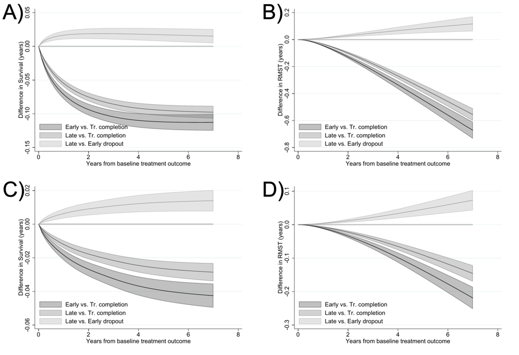

```r
require(cowplot)
require(gridExtra)
require(coin)
require(magick)
require(pdftools)
fig1 <- image_read_pdf('h_m_ns_rp6_stdif_s2_m1.pdf')%>%
    image_border("white", "80x20")%>%
    image_annotate("A)",
                   location = "+18+0",
                   size = 35,
                   gravity = "northwest",
                   boxcolor = "transparent",
                   font = "Arial",
                   strokecolor = "black")

fig2 <- image_read_pdf('h_m_ns_rp6_stdif_rmst_m1.pdf')%>%
    image_border("white", "80x20")%>%
    image_annotate("B)",
                   location = "+18+0",
                   size = 35,
                   gravity = "northwest",
                   boxcolor = "transparent",
                   font = "Arial",
                   strokecolor = "black")
fig2rmtl <- image_read_pdf('_figs/h_m_ns_rp6_stdif_rmtl_m1.pdf')%>%
    image_border("white", "80x20")%>%
    image_annotate("B)",
                   location = "+18+0",
                   size = 35,
                   gravity = "northwest",
                   boxcolor = "transparent",
                   font = "Arial",
                   strokecolor = "black")
fig3 <- image_read_pdf('h_m_ns_rp6_stdif_s2_pris_m1.pdf')%>%
    image_border("white", "80x20")%>%
    image_annotate("C)",
                   location = "+18+0",
                   size = 35,
                   gravity = "northwest",
                   boxcolor = "transparent",
                   font = "Arial",
                   strokecolor = "black")
fig4 <- image_read_pdf('h_m_ns_rp6_stdif_rmst_pris_m1.pdf')%>%
    image_border("white", "80x20")%>%
    image_annotate("D)",
                   location = "+18+0",
                   size = 35,
                   gravity = "northwest",
                   boxcolor = "transparent",
                   font = "Arial",
                   strokecolor = "black")
fig4rmtl <- image_read_pdf('_figs/h_m_ns_rp6_stdif_rmtl_pris_m1.pdf')%>%
    image_border("white", "80x20")%>%
    image_annotate("D)",
                   location = "+18+0",
                   size = 35,
                   gravity = "northwest",
                   boxcolor = "transparent",
                   font = "Arial",
                   strokecolor = "black")
#https://fondecytacc.github.io/nDP/analisis_mariel_feb_2023_stata_m1.html
#https://fondecytacc.github.io/nDP/analisis_mariel_feb_2023_stata_pris_m1.html
#ggsave(plot= p4,filename= "./_figs/SER2023_test.jpg", dpi=740, height = 16*0.7, width =20*0.7)
image_montage(c(fig1, fig2, fig3, fig4), tile = '2x2', geometry = 'x500', gravity = "Center")#
```

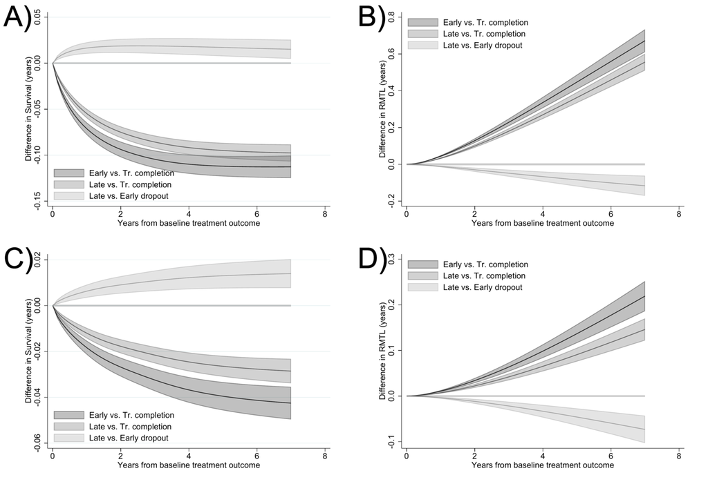

```r
image_write(image_montage(c(fig1, fig2, fig3, fig4), tile = '2x2', geometry = 'x500', gravity = "Center"), path = "montage.png", format = "png", density = "300x300")
image_write(image_montage(c(fig1, fig2, fig3, fig4), tile = '2x2', geometry = 'x500', gravity = "Center"), path = "montage.pdf", format = "pdf", density = "300x300")

image_montage(c(fig1, fig2rmtl, fig3, fig4rmtl), tile = '2x2', geometry = 'x500', gravity = "Center")#
```

```r
image_write(image_montage(c(fig1, fig2rmtl, fig3, fig4rmtl), tile = '2x2', geometry = 'x500', gravity = "Center"), path = "montage_rmtl.png", format = "png", density = "300x300")
image_write(image_montage(c(fig1, fig2rmtl, fig3, fig4rmtl), tile = '2x2', geometry = 'x500', gravity = "Center"), path = "montage_rmtl.pdf", format = "pdf", density = "300x300")
```

Time for this code chunk to run: 0.1 minutes

```r
# In this model, the term dxb: is typically used to indicate a time-dependent covariate,
#which is a covariate whose effect changes over time. For example, if you are studying the survival of
#patients after surgery, a time-dependent covariate might be the patient's age at the time of surgery.
#
# On the other hand, xb: is typically used to denote time-independent covariates, which are covariates
#whose effect does not change over time. An example of a time-independent covariate might
#be the patient's gender.

tab1<-rvest::read_html("mat_tab1.html") %>% rvest::html_table() %>% as.data.table() %>% janitor::row_to_names(3) %>% data.frame() %>%   dplyr::mutate_at(2:(ncol(.)-1), ~sprintf("%1.2f",readr::parse_number(.))) %>% dplyr::filter(dplyr::case_when(b!="NA"~T,T~F)) %>%
  dplyr::mutate(pvalue=dplyr::case_when(readr::parse_number(pvalue)<0.001~"<0.001",T~sprintf("%1.3f",readr::parse_number(pvalue))))
tab2<-rvest::read_html("mat_tab2.html")  %>% rvest::html_table() %>% as.data.table() %>% janitor::row_to_names(3) %>% data.frame() %>%   dplyr::mutate_at(2:(ncol(.)-1), ~sprintf("%1.2f",readr::parse_number(.))) %>% dplyr::filter(dplyr::case_when(b!="NA"~T,T~F)) %>%
  dplyr::mutate(pvalue=dplyr::case_when(readr::parse_number(pvalue)<0.001~"<0.001",T~sprintf("%1.3f",readr::parse_number(pvalue))))
tab3<-rvest::read_html("mat_tab3.html")  %>% rvest::html_table() %>% as.data.table() %>% janitor::row_to_names(3) %>% data.frame() %>%   dplyr::mutate_at(2:(ncol(.)-1), ~sprintf("%1.2f",readr::parse_number(.))) %>% dplyr::filter(dplyr::case_when(b!="NA"~T,T~F)) %>%
  dplyr::mutate(pvalue=dplyr::case_when(readr::parse_number(pvalue)<0.001~"<0.001",T~sprintf("%1.3f",readr::parse_number(pvalue))))
tab4<-rvest::read_html("mat_tab4.html")  %>% rvest::html_table() %>% as.data.table() %>% janitor::row_to_names(3) %>% data.frame() %>%   dplyr::mutate_at(2:(ncol(.)-1), ~sprintf("%1.2f",readr::parse_number(.))) %>% dplyr::filter(dplyr::case_when(b!="NA"~T,T~F)) %>%
  dplyr::mutate(pvalue=dplyr::case_when(readr::parse_number(pvalue)<0.001~"<0.001",T~sprintf("%1.3f",readr::parse_number(pvalue))))

tab1 %>%
  dplyr::left_join(`tab2`,by="Var.1") %>%
  dplyr::left_join(`tab3`,by="Var.1") %>%
  dplyr::left_join(`tab4`,by="Var.1") %>%
  dplyr::mutate(`Var.1`=str_replace_all(`Var.1`, "^_d_rcs", "time-dependent: knot ")) %>%
  dplyr::mutate(`Var.1`=str_replace_all(`Var.1`, "^_rcs", "time-independent: knot ")) %>%
  dplyr::mutate(`Var.1`=str_replace_all(`Var.1`, "knot _mot_egr_early1", "Early discharge")) %>%
  dplyr::mutate(`Var.1`=str_replace_all(`Var.1`, "knot _mot_egr_late1", "Late discharge")) %>%
  dplyr::mutate(`Var.1`=str_replace_all(`Var.1`, "^mot_egr_early$", "Early discharge")) %>%
  dplyr::mutate(`Var.1`=str_replace_all(`Var.1`, "^mot_egr_late$", "Late discharge")) %>%
  dplyr::mutate(across(everything(), ~replace_na(., ""))) %>%
  #rio::export("hrs_intramural2223.xlsx")
  knitr::kable("markdown", caption="sdasd", col.names=c("Term",rep(c("Estimate", "95%CI lo", "95%CI up", "P-value"),4)))
```

| Term | Estimate | 95%CI lo | 95%CI up | P-value | Estimate | 95%CI lo | 95%CI up | P-value | Estimate | 95%CI lo | 95%CI up | P-value | Estimate | 95%CI lo | 95%CI up | P-value |
| --- | --- | --- | --- | --- | --- | --- | --- | --- | --- | --- | --- | --- | --- | --- | --- | --- |
| Early discharge | 1.74 | 1.66 | 1.83 | <0.001 | 1.99 | 1.79 | 2.22 | <0.001 | 1.73 | 1.63 | 1.83 | <0.001 | 2.01 | 1.78 | 2.28 | <0.001 |
| Late discharge | 1.58 | 1.52 | 1.65 | <0.001 | 1.65 | 1.51 | 1.81 | <0.001 | 1.58 | 1.51 | 1.65 | <0.001 | 1.69 | 1.52 | 1.88 | <0.001 |
| time-independent: knot 1 | 2.66 | 2.59 | 2.73 | <0.001 | 2.18 | 2.07 | 2.30 | <0.001 | 2.63 | 2.56 | 2.71 | <0.001 | 2.20 | 2.07 | 2.34 | <0.001 |
| time-independent: knot 2 | 1.11 | 1.10 | 1.12 | <0.001 | 1.07 | 1.06 | 1.09 | <0.001 | 1.10 | 1.09 | 1.12 | <0.001 | 1.07 | 1.05 | 1.08 | <0.001 |
| time-independent: knot 3 | 1.05 | 1.04 | 1.06 | <0.001 | 1.03 | 1.02 | 1.05 | <0.001 | 1.04 | 1.03 | 1.05 | <0.001 | 1.03 | 1.02 | 1.05 | <0.001 |
| time-independent: knot 4 | 1.02 | 1.02 | 1.03 | <0.001 | 1.02 | 1.01 | 1.03 | <0.001 | 1.02 | 1.02 | 1.03 | <0.001 | 1.02 | 1.01 | 1.03 | <0.001 |
| time-independent: knot 5 | 1.01 | 1.01 | 1.02 | <0.001 | 1.01 | 1.01 | 1.02 | <0.001 | 1.01 | 1.01 | 1.02 | <0.001 | 1.01 | 1.00 | 1.02 | 0.001 |
| time-independent: knot 6 | 1.01 | 1.01 | 1.01 | <0.001 | 1.01 | 1.01 | 1.01 | <0.001 | 1.01 | 1.00 | 1.01 | <0.001 | 1.01 | 1.00 | 1.01 | <0.001 |
| time-independent: knot 7 | 1.01 | 1.01 | 1.01 | <0.001 |  |  |  |  |  |  |  |  |  |  |  |  |
| time-independent: knot 8 | 1.00 | 1.00 | 1.01 | <0.001 |  |  |  |  |  |  |  |  |  |  |  |  |
| time-independent: Early discharge | 0.91 | 0.88 | 0.94 | <0.001 | 0.90 | 0.85 | 0.95 | <0.001 | 0.91 | 0.87 | 0.94 | <0.001 | 0.89 | 0.83 | 0.96 | 0.001 |
| time-independent: Late discharge | 0.94 | 0.92 | 0.97 | <0.001 | 0.92 | 0.87 | 0.97 | 0.004 | 0.94 | 0.91 | 0.97 | <0.001 | 0.91 | 0.85 | 0.98 | 0.008 |
| time-dependent: knot 1 | 0.98 | 0.95 | 1.00 | <0.001 | 0.78 | 0.73 | 0.83 | <0.001 | 0.97 | 0.94 | 1.00 | <0.001 | 0.79 | 0.73 | 0.85 | <0.001 |
| time-dependent: knot 2 | 0.11 | 0.10 | 0.12 | <0.001 | 0.07 | 0.06 | 0.08 | <0.001 | 0.10 | 0.09 | 0.11 | <0.001 | 0.06 | 0.05 | 0.08 | <0.001 |
| time-dependent: knot 3 | 0.05 | 0.04 | 0.05 | <0.001 | 0.03 | 0.02 | 0.04 | <0.001 | 0.04 | 0.03 | 0.05 | <0.001 | 0.03 | 0.02 | 0.05 | <0.001 |
| time-dependent: knot 4 | 0.02 | 0.02 | 0.03 | <0.001 | 0.02 | 0.01 | 0.03 | <0.001 | 0.02 | 0.02 | 0.02 | <0.001 | 0.02 | 0.01 | 0.03 | <0.001 |
| time-dependent: knot 5 | 0.01 | 0.01 | 0.02 | <0.001 | 0.01 | 0.01 | 0.02 | <0.001 | 0.01 | 0.01 | 0.02 | <0.001 | 0.01 | 0.00 | 0.02 | 0.001 |
| time-dependent: knot 6 | 0.01 | 0.01 | 0.01 | <0.001 | 0.01 | 0.01 | 0.01 | <0.001 | 0.01 | 0.00 | 0.01 | <0.001 | 0.01 | 0.00 | 0.01 | <0.001 |
| time-dependent: knot 7 | 0.01 | 0.01 | 0.01 | <0.001 |  |  |  |  |  |  |  |  |  |  |  |  |
| time-dependent: knot 8 | 0.00 | 0.00 | 0.01 | <0.001 |  |  |  |  |  |  |  |  |  |  |  |  |
| time-dependent: Early discharge | -0.10 | -0.13 | -0.07 | <0.001 | -0.11 | -0.17 | -0.05 | <0.001 | -0.10 | -0.13 | -0.06 | <0.001 | -0.11 | -0.18 | -0.04 | 0.001 |
| time-dependent: Late discharge | -0.06 | -0.09 | -0.03 | <0.001 | -0.08 | -0.14 | -0.03 | 0.004 | -0.06 | -0.09 | -0.03 | <0.001 | -0.09 | -0.16 | -0.02 | 0.008 |

Time for this code chunk to run: 0 minutes

# Sensitivity analyses

```r
invisible("
coxph(formula = as.formula(paste('Surv(yrs_to_condemn,  event_r) ~ motivodeegreso_mod_imp_rec + rcs(edad_al_ing_1,4) +',
     paste(setdiff(vars_cov, 'edad_al_ing_1'), collapse = '+'))),
     data = Base_fiscalia_v14, ties = 'efron')
")

vars <- c("tr_mod2", "sex_dum2", "edad_ini_cons", "esc1", "esc2",
          "sus_prin2", "sus_prin3", "sus_prin4", "sus_prin5",
          "fr_cons_sus_prin2", "fr_cons_sus_prin3", "fr_cons_sus_prin4", "fr_cons_sus_prin5",
          "cond_ocu2", "cond_ocu3", "cond_ocu4", "cond_ocu5", "cond_ocu6",
          "policonsumo", "num_hij2", "tenviv1", "tenviv2", "tenviv4", "tenviv5",
          "mzone2", "mzone3", "n_off_vio", "n_off_acq", "n_off_sud", "n_off_oth",
          "psy_com2", "psy_com3", "dep2", "rural2", "rural3",
          "porc_pobr", "susini2", "susini3", "susini4", "susini5",
          "ano_nac_corr", "cohab2", "cohab3", "cohab4",
          "fis_com2", "fis_com3", "rc_x1", "rc_x2", "rc_x3")

statadf_main          <- rio::import("mariel_feb_23.dta")
statadf_main_cc       <-  statadf_main[complete.cases(statadf_main[, c(vars,"motivodeegreso_mod_imp_rec")]),] %>% dplyr::mutate(motivodeegreso_mod_imp_rec=factor(motivodeegreso_mod_imp_rec)) #%>% dplyr::mutate(across(vars,~factor(.)))
# statadf_main_l        <- rio::import("mariel_feb_23_late.dta")
# statadf_main_e        <- rio::import("mariel_feb_23_early.dta")
# statadf_main_e_l      <- rio::import("mariel_feb_23_early_late.dta")

statadf_main_pris     <- rio::import("mariel_feb_23_2.dta")
statadf_main_pris_cc  <- statadf_main_pris[complete.cases(statadf_main_pris[, c(vars,"motivodeegreso_mod_imp_rec")]),] %>% dplyr::mutate(motivodeegreso_mod_imp_rec=factor(motivodeegreso_mod_imp_rec))
# statadf_main_pris_l   <- rio::import("mariel_feb_23_2_late.dta")
# statadf_main_pris_e   <- rio::import("mariel_feb_23_2_early.dta")
# statadf_main_pris_e_l <- rio::import("mariel_feb_23_2_early_late.dta")
statadf_miss          <- rio::import("mariel_feb_23_m1.dta")%>% dplyr::mutate(motivodeegreso_mod_imp_rec=factor(motivodeegreso_mod_imp_rec)) #%>%
statadf_miss_pris     <- rio::import("mariel_feb_23_2_m1.dta")%>% dplyr::mutate(motivodeegreso_mod_imp_rec=factor(motivodeegreso_mod_imp_rec)) #%>%

#_#_#_#_#_#_#_#_#_#_#_#_#_#_#_#_#_#_#_#_#_#_#_#_#_#_#_#_#_#_#_#_
#_#_#_#_#_#_#_#_#_#_#_#_#_#_#_#_#_#_#_#_#_#_#_#_#_#_#_#_#_#_#_#_#_#_#_#_
#_#_#_#_#_#_#_#_#_#_#_#_#_#_#_#_#_#_#_#_#_#_#_#_#_#_#_#_#_#_#_#_
#
# motivodeegreso_mod_imp_rec ~ tr_mod2+ sex_dum2+ edad_ini_cons+ esc1+ esc2+ sus_prin2+ sus_prin3+ sus_prin4+ sus_prin5+ fr_cons_sus_prin2+ fr_cons_sus_prin3+ fr_cons_sus_prin4+ fr_cons_sus_prin5+ cond_ocu2+ cond_ocu3+ cond_ocu4+ cond_ocu5+ cond_ocu6+ policonsumo+ num_hij2+ tenviv1+ tenviv2+ tenviv4+ tenviv5+ mzone2+ mzone3+ n_off_vio+ n_off_acq+ n_off_sud+ n_off_oth+ psy_com2+ psy_com3+ dep2+ rural2+ rural3+ porc_pobr+ susini2+ susini3+ susini4+ susini5+ ano_nac_corr+ cohab2+ cohab3+ cohab4+ fis_com2+ fis_com3+ rc_x1+ rc_x2+ rc_x3, data = statadf_main_cc

set.seed(2125)
W1 <- WeightIt::weightit(as.formula(paste("motivodeegreso_mod_imp_rec~", paste(vars, collapse = "+"))), data=statadf_miss, method = "bart", estimand = "ATE", use.mlogit = FALSE)
statadf_miss$weight_mult_b <- WeightIt::get_w_from_ps(W1$weights, statadf_miss$motivodeegreso_mod_imp_rec, estimand = "ATE", stabilize=T)
set.seed(2125)
W2 <- WeightIt::weightit(as.formula(paste("motivodeegreso_mod_imp_rec~", paste(vars, collapse = "+"))), data=statadf_miss_pris, method = "bart", estimand = "ATE", use.mlogit = FALSE)
statadf_miss_pris$weight_mult_b <- WeightIt::get_w_from_ps(W2$weights, statadf_miss_pris$motivodeegreso_mod_imp_rec, estimand = "ATE", stabilize=T)

# Surv(yrs_to_condemn, event_r) ~ motivodeegreso_mod_imp_rec +
#     rcs(edad_al_ing_1, 4) + motivodeegreso_mod_imp_rec + tr_modality +
#     sex + edad_ini_cons + escolaridad_rec + sus_principal_mod +
#     freq_cons_sus_prin + condicion_ocupacional_corr + policonsumo +
#     num_hijos_mod_joel_bin + tenencia_de_la_vivienda_mod + macrozona +
#     n_off_vio + n_off_acq + n_off_sud + n_off_oth + dg_cie_10_rec +
#     dg_trs_cons_sus_or + clas_r + porc_pobr + sus_ini_mod_mvv +
#     ano_nac_corr + con_quien_vive_joel + fis_comorbidity_icd_10
```

Time for this code chunk to run: 0.2 minutes

```r
bal_tab_2023_res_1<-
cobalt::bal.tab(motivodeegreso_mod_imp_rec ~ tr_mod2+ sex_dum2+ edad_ini_cons+ esc1+ esc2+ sus_prin2+ sus_prin3+ sus_prin4+ sus_prin5+ fr_cons_sus_prin2+ fr_cons_sus_prin3+ fr_cons_sus_prin4+ fr_cons_sus_prin5+ cond_ocu2+ cond_ocu3+ cond_ocu4+ cond_ocu5+ cond_ocu6+ policonsumo+ num_hij2+ tenviv1+ tenviv2+ tenviv4+ tenviv5+ mzone2+ mzone3+ n_off_vio+ n_off_acq+ n_off_sud+ n_off_oth+ psy_com2+ psy_com3+ dep2+ rural2+ rural3+ porc_pobr+ susini2+ susini3+ susini4+ susini5+ ano_nac_corr+ cohab2+ cohab3+ cohab4+ fis_com2+ fis_com3+ rc_x1+ rc_x2+ rc_x3, data = statadf_miss,
                weights = list("Beyasian Additive Regression Trees" = "weight_mult_b"),
                estimand = "ATE",
                which.treat = .all,
                un = T,
                thresholds = c(cor = .2),
                 binary = "std", continuous = "std",
                stats = c("mean.diffs", "variance.ratios"))

bal_tab_2023_res_2<-
cobalt::bal.tab(motivodeegreso_mod_imp_rec ~ tr_mod2+ sex_dum2+ edad_ini_cons+ esc1+ esc2+ sus_prin2+ sus_prin3+ sus_prin4+ sus_prin5+ fr_cons_sus_prin2+ fr_cons_sus_prin3+ fr_cons_sus_prin4+ fr_cons_sus_prin5+ cond_ocu2+ cond_ocu3+ cond_ocu4+ cond_ocu5+ cond_ocu6+ policonsumo+ num_hij2+ tenviv1+ tenviv2+ tenviv4+ tenviv5+ mzone2+ mzone3+ n_off_vio+ n_off_acq+ n_off_sud+ n_off_oth+ psy_com2+ psy_com3+ dep2+ rural2+ rural3+ porc_pobr+ susini2+ susini3+ susini4+ susini5+ ano_nac_corr+ cohab2+ cohab3+ cohab4+ fis_com2+ fis_com3+ rc_x1+ rc_x2+ rc_x3, data = statadf_miss_pris,
                weights = list("Beyasian Additive Regression Trees" = "weight_mult_b"),
                estimand = "ATE",
                which.treat = .all,
                un = T,
                thresholds = c(cor = .2),
                 binary = "std", continuous = "std",
                stats = c("mean.diffs", "variance.ratios"))

cbind.data.frame(type=c(rep("Cond. sentence",3), rep("Imprisonment",3)),
rbind(data.table::data.table(cbind(comp="Early Dropout vs. Tr. completion",bal_tab_2023_res_1$Pair.Balance$`2 vs. 1`$Balance), keep.rownames=T),
      data.table::data.table(cbind(comp="Late Dropout vs. Tr. completion",bal_tab_2023_res_1$Pair.Balance$`3 vs. 1`$Balance), keep.rownames=T),
      data.table::data.table(cbind(comp="Late vs. Early Dropout",bal_tab_2023_res_1$Pair.Balance$`3 vs. 2`$Balance), keep.rownames=T),
      data.table::data.table(cbind(comp="Early Dropout vs. Tr. completion",bal_tab_2023_res_2$Pair.Balance$`2 vs. 1`$Balance), keep.rownames=T),
      data.table::data.table(cbind(comp="Late Dropout vs. Tr. completion",bal_tab_2023_res_2$Pair.Balance$`3 vs. 1`$Balance), keep.rownames=T),
      data.table::data.table(cbind(comp="Late vs. Early Dropout",bal_tab_2023_res_2$Pair.Balance$`3 vs. 2`$Balance), keep.rownames=T))) %>%
  #data.table::data.table(keep.rownames = T) %>%
  dplyr::select(type, comp, rn, everything()) %>%
  dplyr::arrange(type, comp, -Diff.Adj) %>%
  dplyr::mutate_if(is.numeric, ~round(.,2)) %>%
  knitr::kable("markdown", caption="Balance Measures (multinomial response BART weights)")
```

Table 14: Balance Measures (multinomial response BART weights)

| type | comp | rn | Type | Diff.Un | V.Ratio.Un | Diff.Adj | V.Ratio.Adj |
| --- | --- | --- | --- | --- | --- | --- | --- |
| Cond. sentence | Early Dropout vs. Tr. completion | psy_com2 | Binary | 1.72 |  | 2.61 |  |
| Cond. sentence | Early Dropout vs. Tr. completion | ano_nac_corr | Contin. | 0.52 | 0.72 | 0.80 | 0.63 |
| Cond. sentence | Early Dropout vs. Tr. completion | sus_prin3 | Binary | 0.42 |  | 0.62 |  |
| Cond. sentence | Early Dropout vs. Tr. completion | n_off_acq_2 | Binary | 0.32 |  | 0.48 |  |
| Cond. sentence | Early Dropout vs. Tr. completion | policonsumo | Binary | 0.27 |  | 0.43 |  |
| Cond. sentence | Early Dropout vs. Tr. completion | susini4 | Binary | 0.25 |  | 0.38 |  |
| Cond. sentence | Early Dropout vs. Tr. completion | n_off_oth_2 | Binary | 0.21 |  | 0.33 |  |
| Cond. sentence | Early Dropout vs. Tr. completion | cond_ocu6 | Binary | 0.19 |  | 0.28 |  |
| Cond. sentence | Early Dropout vs. Tr. completion | fis_com2 | Binary | 0.13 |  | 0.27 |  |
| Cond. sentence | Early Dropout vs. Tr. completion | n_off_sud_2 | Binary | 0.16 |  | 0.25 |  |
| Cond. sentence | Early Dropout vs. Tr. completion | susini3 | Binary | 0.16 |  | 0.23 |  |
| Cond. sentence | Early Dropout vs. Tr. completion | n_off_vio_2 | Binary | 0.15 |  | 0.23 |  |
| Cond. sentence | Early Dropout vs. Tr. completion | mzone2 | Binary | 0.10 |  | 0.22 |  |
| Cond. sentence | Early Dropout vs. Tr. completion | dep2 | Binary | 0.16 |  | 0.22 |  |
| Cond. sentence | Early Dropout vs. Tr. completion | fr_cons_sus_prin5 | Binary | 0.15 |  | 0.20 |  |
| Cond. sentence | Early Dropout vs. Tr. completion | tenviv5 | Binary | 0.11 |  | 0.17 |  |
| Cond. sentence | Early Dropout vs. Tr. completion | cohab2 | Binary | 0.09 |  | 0.15 |  |
| Cond. sentence | Early Dropout vs. Tr. completion | esc1 | Binary | 0.10 |  | 0.14 |  |
| Cond. sentence | Early Dropout vs. Tr. completion | cond_ocu4 | Binary | 0.07 |  | 0.11 |  |
| Cond. sentence | Early Dropout vs. Tr. completion | esc2 | Binary | 0.06 |  | 0.10 |  |
| Cond. sentence | Early Dropout vs. Tr. completion | cohab3 | Binary | 0.04 |  | 0.06 |  |
| Cond. sentence | Early Dropout vs. Tr. completion | tenviv4 | Binary | 0.04 |  | 0.06 |  |
| Cond. sentence | Early Dropout vs. Tr. completion | sus_prin2 | Binary | 0.03 |  | 0.06 |  |
| Cond. sentence | Early Dropout vs. Tr. completion | tenviv1 | Binary | 0.04 |  | 0.06 |  |
| Cond. sentence | Early Dropout vs. Tr. completion | fr_cons_sus_prin4 | Binary | 0.02 |  | 0.03 |  |
| Cond. sentence | Early Dropout vs. Tr. completion | susini2 | Binary | 0.02 |  | 0.02 |  |
| Cond. sentence | Early Dropout vs. Tr. completion | tenviv2 | Binary | 0.00 |  | 0.01 |  |
| Cond. sentence | Early Dropout vs. Tr. completion | cond_ocu5 | Binary | 0.02 |  | 0.01 |  |
| Cond. sentence | Early Dropout vs. Tr. completion | cond_ocu3 | Binary | 0.00 |  | -0.01 |  |
| Cond. sentence | Early Dropout vs. Tr. completion | susini5 | Binary | -0.01 |  | -0.03 |  |

[output cut: 264 more lines]

```r
 #  knitr::kable("html", caption="Balance Measures") %>%
   #   kableExtra::kable_classic_2()

invisible("0= completar; 1= no-completar;policonsumo looks not balanced, the number of previous acquisitive offenses, and South")
```

Time for this code chunk to run: 0.3 minutes

```r
cbind.data.frame(type=c(rep("Cond. sentence",3), rep("Imprisonment",3)),
rbind(cbind(comp="Early Dropout vs. Tr. completion",
            bal_tab_2023_res_1$Pair.Balance$`2 vs. 1`$Balance),
      cbind(comp="Late Dropout vs. Tr. completion",
            bal_tab_2023_res_1$Pair.Balance$`3 vs. 1`$Balance),
      cbind(comp="Late vs. Early Dropout",
            bal_tab_2023_res_1$Pair.Balance$`3 vs. 2`$Balance),
      cbind(comp="Early Dropout vs. Tr. completion",
            bal_tab_2023_res_2$Pair.Balance$`2 vs. 1`$Balance),
      cbind(comp="Late Dropout vs. Tr. completion",
            bal_tab_2023_res_2$Pair.Balance$`3 vs. 1`$Balance),
      cbind(comp="Late vs. Early Dropout",
            bal_tab_2023_res_2$Pair.Balance$`3 vs. 2`$Balance))) %>%
    data.table::data.table(keep.rownames = T) %>%
    dplyr::select(type, comp, rn, everything()) %>%
    dplyr::mutate_if(is.numeric, ~round(.,2)) %>%
    dplyr::group_by(type, comp) %>%
    dplyr::summarise_if(is.numeric, ~list(min= min(.,na.rm=T), max= max(.,na.rm=T)))%>%
  ungroup() %>%
  knitr::kable("markdown", caption="Balance Measures (multinomial response BART weights)", col.names=c("Type","Comparison","Diff. Unstandardized","V.Ratio Unstandardized","Diff.Adjusted","V.Ratio.Adjusted"))
```

Table 15: Balance Measures (multinomial response BART weights)

| Type | Comparison | Diff. Unstandardized | V.Ratio Unstandardized | Diff.Adjusted | V.Ratio.Adjusted |
| --- | --- | --- | --- | --- | --- |
| Cond. sentence | Early Dropout vs. Tr. completion | -0.62 | 0.42 | -0.95 | 0.28 |
| Cond. sentence | Early Dropout vs. Tr. completion | 1.72 | 0.85 | 2.61 | 0.8 |
| Cond. sentence | Late Dropout vs. Tr. completion | -0.34 | 0.55 | -0.64 | 0.35 |
| Cond. sentence | Late Dropout vs. Tr. completion | 0.31 | 0.98 | 0.57 | 0.96 |
| Cond. sentence | Late vs. Early Dropout | -1.5 | 1.09 | -2.47 | 1.06 |
| Cond. sentence | Late vs. Early Dropout | 0.54 | 1.31 | 0.89 | 1.26 |
| Imprisonment | Early Dropout vs. Tr. completion | -0.62 | 0.42 | -0.94 | 0.28 |
| Imprisonment | Early Dropout vs. Tr. completion | 1.72 | 0.85 | 2.61 | 0.8 |
| Imprisonment | Late Dropout vs. Tr. completion | -0.34 | 0.55 | -0.64 | 0.35 |
| Imprisonment | Late Dropout vs. Tr. completion | 0.31 | 0.98 | 0.57 | 0.97 |
| Imprisonment | Late vs. Early Dropout | -1.5 | 1.09 | -2.46 | 1.06 |
| Imprisonment | Late vs. Early Dropout | 0.54 | 1.31 | 0.9 | 1.27 |

```r
 #  knitr::kable("html", caption="Balance Measures (multinomial response weights)") %>%
   #   kableExtra::kable_classic_2()
```

Time for this code chunk to run: 0 minutes

```r
#The “effective sample size” (ESS) is a measure of the sample size a non-weighted sample would have to have to achieve the same level of precision as the weighted sample (Ridgeway 2006).
cbind.data.frame(type=c(rep("Cond.sentence",6), rep("Imprisonmente",6)),
dplyr::bind_rows(
data.table::data.table(cbind(comp="Early Dropout vs. Tr. completion",bal_tab_2023_res_1$Pair.Balance$`2 vs. 1`$Observations),keep.rownames = T), data.table::data.table(cbind(comp="Late Dropout vs. Tr. completion",bal_tab_2023_res_1$Pair.Balance$`3 vs. 1`$Observations),keep.rownames = T), data.table::data.table(cbind(comp="Late vs. Early Dropout",bal_tab_2023_res_1$Pair.Balance$`3 vs. 2`$Observations),keep.rownames = T),
data.table::data.table(cbind(comp="Early Dropout vs. Tr. completion",bal_tab_2023_res_2$Pair.Balance$`2 vs. 1`$Observations),keep.rownames = T), data.table::data.table(cbind(comp="Early Dropout vs. Tr. completion",bal_tab_2023_res_2$Pair.Balance$`3 vs. 1`$Observations),keep.rownames = T), data.table::data.table(cbind(comp="Late vs. Early Dropout",bal_tab_2023_res_2$Pair.Balance$`3 vs. 2`$Observations),keep.rownames = T)))%>%
  #dplyr::mutate_if(is.numeric, ~round(.,2)) %>%
  knitr::kable("markdown", caption="Effective sample sizes", col.names = c("Type", "Adj", "Comparison", "Tr. completion", "Early Dropout", "Late Dropout"))
```

Table 16: Effective sample sizes

| Type | Adj | Comparison | Tr. completion | Early Dropout | Late Dropout |
| --- | --- | --- | --- | --- | --- |
| Cond.sentence | Unadjusted | Early Dropout vs. Tr. completion | 19277.00 | 15797.00 |  |
| Cond.sentence | Adjusted | Early Dropout vs. Tr. completion | 16894.60 | 11475.61 |  |
| Cond.sentence | Unadjusted | Late Dropout vs. Tr. completion | 19277.00 |  | 35789.00 |
| Cond.sentence | Adjusted | Late Dropout vs. Tr. completion | 16894.60 |  | 33799.41 |
| Cond.sentence | Unadjusted | Late vs. Early Dropout |  | 15797.00 | 35789.00 |
| Cond.sentence | Adjusted | Late vs. Early Dropout |  | 11475.61 | 33799.41 |
| Imprisonmente | Unadjusted | Early Dropout vs. Tr. completion | 19277.00 | 15797.00 |  |
| Imprisonmente | Adjusted | Early Dropout vs. Tr. completion | 16892.12 | 11487.69 |  |
| Imprisonmente | Unadjusted | Early Dropout vs. Tr. completion | 19277.00 |  | 35789.00 |
| Imprisonmente | Adjusted | Early Dropout vs. Tr. completion | 16892.12 |  | 33803.37 |
| Imprisonmente | Unadjusted | Late vs. Early Dropout |  | 15797.00 | 35789.00 |
| Imprisonmente | Adjusted | Late vs. Early Dropout |  | 11487.69 | 33803.37 |

Time for this code chunk to run: 0 minutes

```r
sub1_statadf_miss<- subset(statadf_miss,subset= motivodeegreso_mod_imp_rec!=3) |> dplyr::mutate(motivodeegreso_mod_imp_rec= ifelse(motivodeegreso_mod_imp_rec==2,1,0))|> slice(1:5e5)|>data.table::data.table()
require(RMSTSens)
results.approx11 <- RMSTSens(time="diff", status="event", exposure="motivodeegreso_mod_imp_rec", level.exposed="1", ps="weight_mult_b", data=sub1_statadf_miss, methods="Optim", use.multicore=TRUE, n.core=parallel::detectCores()-2, lambda=c(1,1.25,1.5), tau=1, ini.par=1, verbose=FALSE)
invisible("If the censoring rate is greater than 0.7, the direct optimization method can be used as an alternative because it is implemented as fast as the approximate optimization method.")
results.approx11

results.approx13 <- RMSTSens(time="diff", status="event", exposure="motivodeegreso_mod_imp_rec", level.exposed="1", ps="weight_mult_b", data=sub1_statadf_miss, methods="Optim", use.multicore=TRUE, n.core=parallel::detectCores()-2, lambda=c(1,1.25,1.5), tau=3, ini.par=1, verbose=FALSE)
invisible("If the censoring rate is greater than 0.7, the direct optimization method can be used as an alternative because it is implemented as fast as the approximate optimization method.")
results.approx13

results.approx15 <- RMSTSens(time="diff", status="event", exposure="motivodeegreso_mod_imp_rec", level.exposed="1", ps="weight_mult_b", data=sub1_statadf_miss, methods="Optim", use.multicore=TRUE, n.core=parallel::detectCores()-2, lambda=c(1,1.25,1.5), tau=5, ini.par=1, verbose=FALSE)
invisible("If the censoring rate is greater than 0.7, the direct optimization method can be used as an alternative because it is implemented as fast as the approximate optimization method.")
results.approx15

results.approx21 <- RMSTSens(time="diff", status="event", exposure="motivodeegreso_mod_imp_rec", level.exposed="1", ps="weight_mult_b", data=sub1_statadf_miss, methods="Optim", use.multicore=TRUE, n.core=parallel::detectCores()-2, lambda=c(1,1.25,1.5), tau=1, ini.par=1, verbose=FALSE)
invisible("If the censoring rate is greater than 0.7, the direct optimization method can be used as an alternative because it is implemented as fast as the approximate optimization method.")
results.approx21

results.approx23 <- RMSTSens(time="diff", status="event", exposure="motivodeegreso_mod_imp_rec", level.exposed="1", ps="weight_mult_b", data=sub1_statadf_miss, methods="Optim", use.multicore=TRUE, n.core=parallel::detectCores()-2, lambda=c(1,1.25,1.5), tau=3, ini.par=1, verbose=FALSE)
invisible("If the censoring rate is greater than 0.7, the direct optimization method can be used as an alternative because it is implemented as fast as the approximate optimization method.")
results.approx23

results.approx25 <- RMSTSens(time="diff", status="event", exposure="motivodeegreso_mod_imp_rec", level.exposed="1", ps="weight_mult_b", data=sub1_statadf_miss, methods="Optim", use.multicore=TRUE, n.core=parallel::detectCores()-2, lambda=c(1,1.25,1.5), tau=5, ini.par=1, verbose=FALSE)
invisible("If the censoring rate is greater than 0.7, the direct optimization method can be used as an alternative because it is implemented as fast as the approximate optimization method.")
results.approx25
```

Time for this code chunk to run: 0 minutes

```r
ifelse(!require("coxphw"), install.packages("coxphw"),library("coxphw"))
```

Loading required package: coxphw

```
[1] "coxphw"
```

```r
system.time({
pwp_pris<-
  coxphw::coxphw(Surv(diff,event==1)  ~ mot_egr_early+ mot_egr_late+ tr_mod2+ sex_dum2+ edad_ini_cons+ esc1+ esc2+ sus_prin2+ sus_prin3+ sus_prin4+ sus_prin5+ fr_cons_sus_prin2+ fr_cons_sus_prin3+ fr_cons_sus_prin4+ fr_cons_sus_prin5+ cond_ocu2+ cond_ocu3+ cond_ocu4+ cond_ocu5+ cond_ocu6+ policonsumo+ num_hij2+ tenviv1+ tenviv2+ tenviv4+ tenviv5+ mzone2+ mzone3+ n_off_vio+ n_off_acq+ n_off_sud+ n_off_oth+ psy_com2+ psy_com3+ dep2+ rural2+ rural3+ porc_pobr+ susini2+ susini3+ susini4+ susini5+ ano_nac_corr+ cohab2+ cohab3+ cohab4+ fis_com2+ fis_com3+ rc_x1+ rc_x2+ rc_x3, data = statadf_miss_pris, template="AHR",  robust=T) #, clusterid=statadf_miss_pris$hash_key
#  ~ motivodeegreso_mod_imp_rec+ tr_mod2+ sex_dum2+ edad_ini_cons+ esc1+ esc2+ sus_prin2+ sus_prin3+ sus_prin4+ sus_prin5+ fr_cons_sus_prin2+ fr_cons_sus_prin3+ fr_cons_sus_prin4+ fr_cons_sus_prin5+ cond_ocu2+ cond_ocu3+ cond_ocu4+ cond_ocu5+ cond_ocu6+ policonsumo+ num_hij2+ tenviv1+ tenviv2+ tenviv4+ tenviv5+ mzone2+ mzone3+ n_off_vio+ n_off_acq+ n_off_sud+ n_off_oth+ psy_com2+ psy_com3+ dep2+ rural2+ rural3+ porc_pobr+ susini2+ susini3+ susini4+ susini5+ ano_nac_corr+ cohab2+ cohab3+ cohab4+ fis_com2+ fis_com3+ rc_x1+ rc_x2+ rc_x3, data = statadf_miss_pris
})
```

```
   user  system elapsed
 511.78   55.90  568.75
```

```r
system.time({
pwp_condemn<-
  coxphw::coxphw(Surv(diff,event==1)  ~ mot_egr_early+ mot_egr_late+ tr_mod2+ sex_dum2+ edad_ini_cons+ esc1+ esc2+ sus_prin2+ sus_prin3+ sus_prin4+ sus_prin5+ fr_cons_sus_prin2+ fr_cons_sus_prin3+ fr_cons_sus_prin4+ fr_cons_sus_prin5+ cond_ocu2+ cond_ocu3+ cond_ocu4+ cond_ocu5+ cond_ocu6+ policonsumo+ num_hij2+ tenviv1+ tenviv2+ tenviv4+ tenviv5+ mzone2+ mzone3+ n_off_vio+ n_off_acq+ n_off_sud+ n_off_oth+ psy_com2+ psy_com3+ dep2+ rural2+ rural3+ porc_pobr+ susini2+ susini3+ susini4+ susini5+ ano_nac_corr+ cohab2+ cohab3+ cohab4+ fis_com2+ fis_com3+ rc_x1+ rc_x2+ rc_x3, data = statadf_miss, template="AHR",  robust=T) #, clusterid=statadf_miss_pris$hash_key
#  ~ motivodeegreso_mod_imp_rec+ tr_mod2+ sex_dum2+ edad_ini_cons+ esc1+ esc2+ sus_prin2+ sus_prin3+ sus_prin4+ sus_prin5+ fr_cons_sus_prin2+ fr_cons_sus_prin3+ fr_cons_sus_prin4+ fr_cons_sus_prin5+ cond_ocu2+ cond_ocu3+ cond_ocu4+ cond_ocu5+ cond_ocu6+ policonsumo+ num_hij2+ tenviv1+ tenviv2+ tenviv4+ tenviv5+ mzone2+ mzone3+ n_off_vio+ n_off_acq+ n_off_sud+ n_off_oth+ psy_com2+ psy_com3+ dep2+ rural2+ rural3+ porc_pobr+ susini2+ susini3+ susini4+ susini5+ ano_nac_corr+ cohab2+ cohab3+ cohab4+ fis_com2+ fis_com3+ rc_x1+ rc_x2+ rc_x3, data = statadf_miss_pris
})
```

```
   user  system elapsed
1086.83   54.81 1143.95
```

```r
#pris
#sent
coxphw_coefs<-
rbind.data.frame(
cbind.data.frame(type="Condemnatory Sentence", coef= coef(pwp_condemn)[c(1:2)],coxphw:::confint.coxphw(pwp_condemn)[c(1:2),]),
cbind.data.frame(type="Imprisonment",coef= c(coef(pwp_pris)[c(1:2)]),coxphw:::confint.coxphw(pwp_pris)[c(1:2),])
)

coxphw_coefs%>%
  dplyr::mutate_if(is.numeric,~exp(.)) %>%
  knitr::kable("markdown", caption="Averaged hazard ratios", digits=2)
```

Table 17: Averaged hazard ratios

|  | type | coef | 2.5 % | 97.5 % |
| --- | --- | --- | --- | --- |
| mot_egr_early | Condemnatory Sentence | 1.70 | 1.59 | 1.81 |
| mot_egr_late | Condemnatory Sentence | 1.54 | 1.46 | 1.62 |
| mot_egr_early1 | Imprisonment | 1.82 | 1.57 | 2.11 |
| mot_egr_late1 | Imprisonment | 1.48 | 1.31 | 1.66 |

Time for this code chunk to run: 0.5 minutes

```r
#early
#pwp_pris, mot_egr_early 1.8193382  1.5723899  2.1050704  ==== 3.040261 2.521084      NA
#pwp_condemn, mot_egr_early  1.6981313  1.5911785  1.8122731 ==== 2.239818 2.101310       NA

#late
#pwp_pris, mot_egr_late  1.4784520  1.3134946  1.6641257 ==== 2.319504 1.955190       NA
#pwp_condemn, mot_egr_late   1.5377467  1.4629155  1.6164056  ====  2.029950 1.927147       NA
require(EValue)
```

Loading required package: EValue

Registered S3 methods overwritten by ‘EValue’: method from print.estimate lava summary.estimate lava

Attaching package: ‘EValue’

The following object is masked from ‘package:survey’:

```
HR
```

```r
evalues.RR(est = exp(coxphw_coefs[3,2]),
           lo = exp(coxphw_coefs[3,3]), hi= exp(coxphw_coefs[3,4]), rare=T)
```

```
            point    lower   upper
RR       1.819338 1.572390 2.10507
E-values 3.040261 2.521084      NA
```

```r
#E-values 3.040261 2.521084      NA
evalues.RR(est = toRR(HR(exp(coxphw_coefs[1,2]), rare = FALSE)),
           lo = toRR(HR(exp(coxphw_coefs[1,3]), rare = FALSE)),
           hi = toRR(HR(exp(coxphw_coefs[1,4]), rare = FALSE)),
           rare=T)
```

```
            point    lower    upper
RR       1.441756 1.378716 1.507518
E-values 2.239818 2.101310       NA
```

```r
#RR       1.441756 1.378716 1.507518
#2.239818 2.101310       NA
evalues.RR(est = exp(coxphw_coefs[4,2]),
           lo = exp(coxphw_coefs[4,3]),
           hi = exp(coxphw_coefs[4,4]), rare=T)
```

```
            point    lower    upper
RR       1.478452 1.313495 1.664126
E-values 2.319504 1.955190       NA
```

```r
# 2.319504 1.955190       NA
evalues.RR(est = toRR(HR(exp(coxphw_coefs[2,2]), rare = FALSE)),
           lo = toRR(HR(exp(coxphw_coefs[2,3]), rare = FALSE)),
           hi = toRR(HR(exp(coxphw_coefs[2,4]) , rare = FALSE)),
           rare=T)
```

```
            point    lower    upper
RR       1.346677 1.301161 1.393714
E-values 2.029949 1.927147       NA
```

```r
# RR       1.346677 1.301161 1.393714
# E-values 2.029950 1.927147       NA
```

Time for this code chunk to run: 0 minutes

# Session Info

```r
message(Sys.getenv("R_LIBS_USER"))
```

C:/Users/CISS Fondecyt/Mi unidad/Alvacast/SISTRAT 2022 (github)/renv/library/R-4.1/x86_64-w64-mingw32;C:/Users/CISS Fondecyt/AppData/Local/Temp/RtmpsP2zac/renv-system-library

```r
Sys.Date()
```

```
[1] "2023-06-18"
```

```r
message(paste0("Editor context: ", path))
```

Editor context: C:/Users/CISS Fondecyt/Mi unidad/Alvacast/SISTRAT 2022 (github)

```r
#load(paste0(dirname(rstudioapi::getSourceEditorContext()$path),"/15.RData"))

if (grepl("CISS Fondecyt",rstudioapi::getSourceEditorContext()$path)==T){
    save.image("C:/Users/CISS Fondecyt/Mi unidad/Alvacast/SISTRAT 2022 (github)/15.RData")
  } else if (grepl("andre",rstudioapi::getSourceEditorContext()$path)==T){
    save.image("C:/Users/andre/Desktop/SUD_CL/15.RData")
  } else if (grepl("E:",rstudioapi::getSourceEditorContext()$path)==T){
    save.image("E:/Mi unidad/Alvacast/SISTRAT 2022 (github)/15.RData")
  } else {
     tryCatch(save.image(paste0(sub("2019","2022",sub("SUD_CL","",path)),"15.RData")),
              error= save.image(paste0(sub("2019","2022",sub("SUD_CL","",path)),"/15.RData")))
  }

sesion_info <- devtools::session_info()
dplyr::select(
  tibble::as_tibble(sesion_info$packages),
  c(package, loadedversion, source)
) %>%
  DT::datatable(filter = 'top', colnames = c('Row number' =1,'Variable' = 2, 'Percentage'= 3),
              caption = htmltools::tags$caption(
        style = 'caption-side: top; text-align: left;',
        '', htmltools::em('Packages')),
      options=list(
initComplete = htmlwidgets::JS(
        "function(settings, json) {",
        "$(this.api().tables().body()).css({
            'font-family': 'Helvetica Neue',
            'font-size': '50%',
            'code-inline-font-size': '15%',
            'white-space': 'nowrap',
            'line-height': '0.75em',
            'min-height': '0.5em'
            });",#;
        "}")))
```

| Row number | Variable | Percentage | source |
| --- | --- | --- | --- |
| 1 | abind | 1.4-5 | CRAN (R 4.1.1) |
| 2 | AdjKM.CIF | 0.1.0 | Github (Lesly1031/AdjKM.CIF@70a4e935e4051f03590988e1bcc1820a4280e0d9) |
| 3 | adjustedCurves | 0.9.0 | CRAN (R 4.1.3) |
| 4 | admisc | 0.30 | CRAN (R 4.1.3) |
| 5 | Amelia | 1.8.0 | CRAN (R 4.1.2) |
| 6 | askpass | 1.1 | CRAN (R 4.1.2) |
| 7 | assertthat | 0.2.1 | CRAN (R 4.1.2) |
| 8 | backports | 1.4.1 | CRAN (R 4.1.2) |
| 9 | base64enc | 0.1-3 | CRAN (R 4.1.1) |
| 10 | bayestestR | 0.13.0 | CRAN (R 4.1.3) |

[output cut: 367 more lines]

Time for this code chunk to run: 0 minutes

## June 18, 2023

```r
#put name of the file
file<- "fiscalia_mariel_feb_2023_match_SENDA.dta"

subset(Base_fiscalia_v14, select= c("hash_key", vars_cov, "fech_ing_num_1", "fech_nac_rec")) %>%

export_lab_stata_merge<-
  tibble::rownames_to_column(data.frame(Hmisc::label(dplyr::select(Base_fiscalia_v14,  all_of(c("hash_key", vars_cov, "fech_ing_num_1", "fech_nac_rec"))))))%>% data.frame() %>%

  dplyr::rename("code" = !!names(.[1]), "label" = !!names(.[2]))%>% data.frame()%>%
  dplyr::mutate(first= "cap noi label variable")%>%
  dplyr::mutate(final= paste0(first, " ",code,' "',label,'"'))%>%
  dplyr::select(-code,-label,-first)%>%
  dplyr::rename("*clear all"="final") %>%
  rbind(paste0('cap noi save "', gsub('/', '\\', path, fixed=T),'\\',file,'", replace'))%>%
  rbind(paste0('cap noi save "', gsub('/', '\\', path, fixed=T),'\\',file,'", replace'))

rbind(paste0('cap noi use "', gsub('/', '\\', path, fixed=T),'\\',file,'", clear'),export_lab_stata_merge) %>% knitr::kable("markdown")

write.table(rbind(paste0('cap noi use "', gsub('/', '\\', path, fixed=T),'\\',file,'", clear'),export_lab_stata_merge), file = paste0(path,"/_label_var_to_stata_feb2023.do"), sep = "",row.names = FALSE, quote = FALSE, fileEncoding="UTF-8")
```

Time for this code chunk to run: 0 minutes

```stata
*should be in the same folder of the .Rmd to work
cap noi do _label_var_to_stata_jan2023_mod
```

```
Error in running command st
```

Time for this code chunk to run: 0 minutes